# Donors choose data analysis

1. About dataset  
2. Preparing data for analysis - importing libraries, reading data...  
3. Univariate analysis  
4. Pre-processing data  
5. Vectorizing all features - preparing data for classification and modelling  
6. Classification & Modelling Using Support Vector Machine  
6.1 Building classification model using data(original dimensions) with support vector machine)  
6.1.1 Building classification model using total data with support vector machine  
6.2 Building classification model using data(reduced dimensions) with support vector machine  
6.2.1 Building classification model using data(reduced dimensions) with support vector machine  
6.3 Results of analysis using support vector machine  
6.4 Conclusions of analysis using support vector machine

## Little History about Data Set

Founded in 2000 by a high school teacher in the Bronx, DonorsChoose.org empowers public school teachers from across the country to request much-needed materials and experiences for their students. At any given time, there are thousands of classroom requests that can be brought to life with a gift of any amount.

## Answers to What and Why Questions on Data Set

DonorsChoose.org receives hundreds of thousands of project proposals each year for classroom projects in need of funding. Right now, a large number of volunteers is needed to manually screen each submission before it's approved to be posted on the DonorsChoose.org website.

Next year, DonorsChoose.org expects to receive close to 500,000 project proposals. As a result, there are three main problems they need to solve:

- How to scale current manual processes and resources to screen 500,000 projects so that they can be posted as quickly and as efficiently as possible
- How to increase the consistency of project vetting across different volunteers to improve the experience for teachers
- How to focus volunteer time on the applications that need the most assistance

The goal of the competition is to predict whether or not a DonorsChoose.org project proposal submitted by a teacher will be approved, using the text of project descriptions as well as additional metadata about the project, teacher, and school. DonorsChoose.org can then use this information to identify projects most likely to need further review before approval.

## About the DonorsChoose Data Set

The `train.csv` data set provided by DonorsChoose contains the following features:

Feature

Description

**`project_id`**

A unique identifier for the proposed project. **Example:** `p036502`

**`project_title`**

Title of the project. **Examples:**

- `Art Will Make You Happy!`
- `First Grade Fun`

**`project_grade_category`**

Grade level of students for which the project is targeted. One of the following enumerated values:

- `Grades PreK-2`
- `Grades 3-5`
- `Grades 6-8`
- `Grades 9-12`

**`project_subject_categories`**

One or more (comma-separated) subject categories for the project from the following enumerated list of values:

- `Applied Learning`
- `Care & Hunger`
- `Health & Sports`
- `History & Civics`
- `Literacy & Language`
- `Math & Science`
- `Music & The Arts`
- `Special Needs`
- `Warmth`

**Examples:**

- `Music & The Arts`
- `Literacy & Language, Math & Science`

**`school_state`**

State where school is located ([Two-letter U.S. postal code](https://en.wikipedia.org/wiki/List_of_U.S._state_abbreviations#Postal_codes)). **Example:** `WY`

**`project_subject_subcategories`**

One or more (comma-separated) subject subcategories for the project. **Examples:**

- `Literacy`
- `Literature & Writing, Social Sciences`

**`project_resource_summary`**

An explanation of the resources needed for the project. **Example:**

- `My students need hands on literacy materials to manage sensory needs!`

**`project_essay_1`**

First application essay*

**`project_essay_2`**

Second application essay*

**`project_essay_3`**

Third application essay*

**`project_essay_4`**

Fourth application essay*

**`project_submitted_datetime`**

Datetime when project application was submitted. **Example:** `2016-04-28 12:43:56.245`

**`teacher_id`**

A unique identifier for the teacher of the proposed project. **Example:** `bdf8baa8fedef6bfeec7ae4ff1c15c56`

**`teacher_prefix`**

Teacher's title. One of the following enumerated values:

- `nan`
- `Dr.`
- `Mr.`
- `Mrs.`
- `Ms.`
- `Teacher.`

**`teacher_number_of_previously_posted_projects`**

Number of project applications previously submitted by the same teacher. **Example:** `2`

* See the section **Notes on the Essay Data** for more details about these features.

Additionally, the `resources.csv` data set provides more data about the resources required for each project. Each line in this file represents a resource required by a project:

| Feature | Description |
| --- | --- |
| **`id`** | A `project_id` value from the `train.csv` file. **Example:** `p036502` |
| **`description`** | Desciption of the resource. **Example:** `Tenor Saxophone Reeds, Box of 25` |
| **`quantity`** | Quantity of the resource required. **Example:** `3` |
| **`price`** | Price of the resource required. **Example:** `9.95` |

**Note:** Many projects require multiple resources. The `id` value corresponds to a `project_id` in train.csv, so you use it as a key to retrieve all resources needed for a project:

The data set contains the following label (the value you will attempt to predict):

| Label | Description |
| --- | --- |
| `project_is_approved` | A binary flag indicating whether DonorsChoose approved the project. A value of `0` indicates the project was not approved, and a value of `1` indicates the project was approved. |

### Notes on the Essay Data

Prior to May 17, 2016, the prompts for the essays were as follows:

- __project_essay_1:__ "Introduce us to your classroom"
- __project_essay_2:__ "Tell us more about your students"
- __project_essay_3:__ "Describe how your students will use the materials you're requesting"
- __project_essay_4:__ "Close by sharing why your project will make a difference"

Starting on May 17, 2016, the number of essays was reduced from 4 to 2, and the prompts for the first 2 essays were changed to the following:

- __project_essay_1:__ "Describe your students: What makes your students special? Specific details about their background, your neighborhood, and your school are all helpful."
- __project_essay_2:__ "About your project: How will these materials make a difference in your students' learning and improve their school lives?"

For all projects with project_submitted_datetime of 2016-05-17 and later, the values of project_essay_3 and project_essay_4 will be NaN.

## Importing required libraries

```python
# numpy for easy numerical computations
import numpy as np
# pandas for dataframes and filterings
import pandas as pd
# sqlite3 library for performing operations on sqlite file
import sqlite3
# matplotlib for plotting graphs
import matplotlib.pyplot as plt
# seaborn library for easy plotting
import seaborn as sbrn
# warnings library for specific settings
import warnings
# regularlanguage for regex operations
import re
# For loading precomputed models
import pickle
# For loading natural language processing tool-kit
import nltk
# For calculating mathematical terms
import math

# For loading files from google drive
from google.colab import drive
# For working with files in google drive
drive.mount('/content/drive')
# tqdm for tracking progress of loops
from tqdm import tqdm_notebook as tqdm
# For creating dictionary of words
from collections import Counter
# For creating BagOfWords Model
from sklearn.feature_extraction.text import CountVectorizer
# For creating TfidfModel
from sklearn.feature_extraction.text import TfidfVectorizer
# For standardizing values
from sklearn.preprocessing import StandardScaler
# For merging sparse matrices along row direction
from scipy.sparse import hstack
# For merging sparse matrices along column direction
from scipy.sparse import vstack
# For calculating TSNE values
from sklearn.manifold import TSNE
# For calculating the accuracy score on cross validate data
from sklearn.metrics import accuracy_score
# For performing the k-fold cross validation
from sklearn.model_selection import cross_val_score
# For splitting the data set into test and train data
from sklearn import model_selection
# Support Vector classifier for classification
from sklearn.svm import SVC
# For reducing dimensions of data
from sklearn.decomposition import TruncatedSVD
# For using svm classifer - hinge loss function of sgd
from sklearn import linear_model
# For creating samples for making dataset balanced
from sklearn.utils import resample
# For shuffling the dataframes
from sklearn.utils import shuffle
# For calculating roc_curve parameters
from sklearn.metrics import roc_curve
# For calculating auc value
from sklearn.metrics import auc
# For displaying results in table format
from prettytable import PrettyTable
# For generating confusion matrix
from sklearn.metrics import confusion_matrix
# For using gridsearch cv to find best parameter
from sklearn.model_selection import GridSearchCV
# For performing min-max standardization to features
from sklearn.preprocessing import MinMaxScaler
# For calculating sentiment score of the text
from nltk.sentiment.vader import SentimentIntensityAnalyzer
nltk.download('vader_lexicon')

warnings.filterwarnings('ignore')
```

[output not shown]

## Reading and Storing Data

```python
projectsData = pd.read_csv('drive/My Drive/train_data.csv');
resourcesData = pd.read_csv('drive/My Drive/resources.csv');
```

```python
projectsData.head(3)
```

|  | Unnamed: 0 | id | teacher_id | teacher_prefix | school_state | project_submitted_datetime | project_grade_category | project_subject_categories | project_subject_subcategories | project_title | project_essay_1 | project_essay_2 | project_essay_3 | project_essay_4 | project_resource_summary | teacher_number_of_previously_posted_projects | project_is_approved |
| --- | --- | --- | --- | --- | --- | --- | --- | --- | --- | --- | --- | --- | --- | --- | --- | --- | --- |
| 0 | 160221 | p253737 | c90749f5d961ff158d4b4d1e7dc665fc | Mrs. | IN | 2016-12-05 13:43:57 | Grades PreK-2 | Literacy & Language | ESL, Literacy | Educational Support for English Learners at Home | My students are English learners that are work... | \"The limits of your language are the limits o... | NaN | NaN | My students need opportunities to practice beg... | 0 | 0 |
| 1 | 140945 | p258326 | 897464ce9ddc600bced1151f324dd63a | Mr. | FL | 2016-10-25 09:22:10 | Grades 6-8 | History & Civics, Health & Sports | Civics & Government, Team Sports | Wanted: Projector for Hungry Learners | Our students arrive to our school eager to lea... | The projector we need for our school is very c... | NaN | NaN | My students need a projector to help with view... | 7 | 1 |
| 2 | 21895 | p182444 | 3465aaf82da834c0582ebd0ef8040ca0 | Ms. | AZ | 2016-08-31 12:03:56 | Grades 6-8 | Health & Sports | Health & Wellness, Team Sports | Soccer Equipment for AWESOME Middle School Stu... | \r\n\"True champions aren't always the ones th... | The students on the campus come to school know... | NaN | NaN | My students need shine guards, athletic socks,... | 1 | 0 |

```python
projectsData.tail(3)
```

|  | Unnamed: 0 | id | teacher_id | teacher_prefix | school_state | project_submitted_datetime | project_grade_category | project_subject_categories | project_subject_subcategories | project_title | project_essay_1 | project_essay_2 | project_essay_3 | project_essay_4 | project_resource_summary | teacher_number_of_previously_posted_projects | project_is_approved |
| --- | --- | --- | --- | --- | --- | --- | --- | --- | --- | --- | --- | --- | --- | --- | --- | --- | --- |
| 109245 | 143653 | p155633 | cdbfd04aa041dc6739e9e576b1fb1478 | Mrs. | NJ | 2016-08-25 17:11:32 | Grades PreK-2 | Literacy & Language, Math & Science | Literacy, Mathematics | 2016/2017 Beginning of the Year Basics | This is a great group of sharing and caring st... | My students learn about special events, holida... | NaN | NaN | My students need giant comfy pillows in order ... | 3 | 1 |
| 109246 | 164599 | p206114 | 6d5675dbfafa1371f0e2f6f1b716fe2d | Mrs. | NY | 2016-07-29 17:53:15 | Grades 3-5 | Health & Sports, Special Needs | Health & Wellness, Special Needs | Flexible Seating in Inclusive Classroom | Our students live in a small rural community. ... | Flexible classroom seating has been researched... | NaN | NaN | My students need flexible seating options: bea... | 0 | 1 |
| 109247 | 128381 | p191189 | ca25d5573f2bd2660f7850a886395927 | Ms. | VA | 2016-06-29 09:17:01 | Grades 6-8 | Applied Learning, Math & Science | College & Career Prep, Mathematics | Classroom Tech to Develop 21st Century Leaders | When was the last time that you used math? Pro... | According to Forbes Magazine (2014), companies... | NaN | NaN | My students need opportunities to work with te... | 0 | 1 |

```python
resourcesData.head(3)
```

|  | id | description | quantity | price |
| --- | --- | --- | --- | --- |
| 0 | p233245 | LC652 - Lakeshore Double-Space Mobile Drying Rack | 1 | 149.00 |
| 1 | p069063 | Bouncy Bands for Desks (Blue support pipes) | 3 | 14.95 |
| 2 | p069063 | Cory Stories: A Kid's Book About Living With Adhd | 1 | 8.45 |

```python
resourcesData.tail(3)
```

|  | id | description | quantity | price |
| --- | --- | --- | --- | --- |
| 1541269 | p031981 | Black Electrical Tape (GIANT 3 PACK) Each Roll... | 6 | 8.99 |
| 1541270 | p031981 | Flormoon DC Motor Mini Electric Motor 0.5-3V 1... | 2 | 8.14 |
| 1541271 | p031981 | WAYLLSHINE 6PCS 2 x 1.5V AAA Battery Spring Cl... | 2 | 7.39 |

### Helper functions and classes

```python
def equalsBorder(numberOfEqualSigns):
    """
    This function prints passed number of equal signs
    """
    print("="* numberOfEqualSigns);
```

```python
# Citation link: https://stackoverflow.com/questions/8924173/how-do-i-print-bold-text-in-python
class color:
   PURPLE = '\033[95m'
   CYAN = '\033[96m'
   DARKCYAN = '\033[36m'
   BLUE = '\033[94m'
   GREEN = '\033[92m'
   YELLOW = '\033[93m'
   RED = '\033[91m'
   BOLD = '\033[1m'
   UNDERLINE = '\033[4m'
   END = '\033[0m'
```

```python
def printStyle(text, style):
    "This function prints text with the style passed to it"
    print(style + text + color.END);
```

### Shapes of projects data and resources data

```python
printStyle("Number of data points in projects data: {}".format(projectsData.shape[0]), color.BOLD);
printStyle("Number of attributes in projects data:{}".format(projectsData.shape[1]), color.BOLD);
equalsBorder(60);
printStyle("Number of data points in resources data: {}".format(resourcesData.shape[0]), color.BOLD);
printStyle("Number of attributes in resources data: {}".format(resourcesData.shape[1]), color.BOLD);
```

```
Number of data points in projects data: 109248
Number of attributes in projects data:17
============================================================
Number of data points in resources data: 1541272
Number of attributes in resources data: 4
```

# Univariate data analysis

```
Number of projects approved for funding: 92706, (84.85830404217927)
Number of projects not approved for funding: 16542, (15.141695957820739)
```

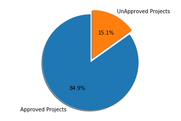

```python
approvedProjects = projectsData[projectsData.project_is_approved == 1].shape[0];
unApprovedProjects = projectsData[projectsData.project_is_approved == 0].shape[0];
totalProjects = projectsData.shape[0];
print("Number of projects approved for funding: {}, ({})".format(approvedProjects, (approvedProjects / totalProjects) * 100));
print("Number of projects not approved for funding: {}, ({})".format(unApprovedProjects, (unApprovedProjects / totalProjects) * 100));
# Pie chart representation
# Citation: https://matplotlib.org/gallery/pie_and_polar_charts/pie_features.html
labels = ["Approved Projects", "UnApproved Projects"];
explode = (0, 0.1);
sizes = [approvedProjects, unApprovedProjects];
figure, ax = plt.subplots();
ax.pie(sizes, labels = labels, explode = explode, autopct = '%1.1f%%', shadow = True, startangle = 90);
ax.axis('equal');
plt.rcParams['figure.figsize'] = (7, 7);
plt.show();
```

### Observation:

1. There are more number of approved projects compared to rejected projects. So this is a imbalanced dataset.

## Univariate Analysis : 'school_state'

### Project proposal percentage in different states

```python
groupedByStatesData = pd.DataFrame(projectsData.groupby(['school_state'])['project_is_approved'].apply(np.mean)).reset_index();
groupedByStatesData.columns = ['state_code', 'number_of_proposals'];
groupedByStatesData = groupedByStatesData.sort_values(by=['number_of_proposals'], ascending = True);
printStyle("5 States with lowest percentage of project approvals:", color.BOLD);
equalsBorder(60);
groupedByStatesData.head(5)
```

```
5 States with lowest percentage of project approvals:
============================================================
```

|  | state_code | number_of_proposals |
| --- | --- | --- |
| 46 | VT | 0.800000 |
| 7 | DC | 0.802326 |
| 43 | TX | 0.813142 |
| 26 | MT | 0.816327 |
| 18 | LA | 0.831245 |

```python
printStyle("5 states with highest percentage of project approvals: ", color.BOLD);
equalsBorder(60);
groupedByStatesData.tail(5).iloc[::-1]
```

```
5 states with highest percentage of project approvals:
============================================================
```

|  | state_code | number_of_proposals |
| --- | --- | --- |
| 8 | DE | 0.897959 |
| 28 | ND | 0.888112 |
| 47 | WA | 0.876178 |
| 35 | OH | 0.875152 |
| 30 | NH | 0.873563 |

```python
def univariateBarPlots(data, col1, col2 = 'project_is_approved', orientation = 'vertical', plot = True):
    groupedData = data.groupby(col1);
    # Count number of zeros in dataframe python: https://stackoverflow.com/a/51540521/4084039
    tempData = pd.DataFrame(groupedData[col2].agg(lambda x: x.eq(1).sum())).reset_index();
    tempData['total'] = pd.DataFrame(groupedData[col2].agg({'total': 'count'})).reset_index()['total'];
    tempData['approval_rate'] = pd.DataFrame(groupedData[col2].agg({'approval_rate': 'mean'})).reset_index()['approval_rate'];
    tempData.sort_values(by=['total'], inplace = True, ascending = False);
    tempDataWithTotalAndCol2 = tempData[['total', col2, col1]]
    if plot:
        if(orientation == 'vertical'):
            tempDataWithTotalAndCol2.plot(x = col1, align= 'center', kind = 'bar', title = "Number of projects approved vs rejected", figsize = (20, 6), stacked = True, rot = 0);
        else:
            tempDataWithTotalAndCol2.plot(x = col1, align= 'center', kind = 'barh', title = "Number of projects approved vs rejected", width = 0.8, figsize = (23, 20), stacked = True);
    return tempData;
```

```
Top 5 states with high project proposals
============================================================
```

|  | school_state | project_is_approved | total | approval_rate |
| --- | --- | --- | --- | --- |
| 4 | CA | 13205 | 15388 | 0.858136 |
| 43 | TX | 6014 | 7396 | 0.813142 |
| 34 | NY | 6291 | 7318 | 0.859661 |
| 9 | FL | 5144 | 6185 | 0.831690 |
| 27 | NC | 4353 | 5091 | 0.855038 |

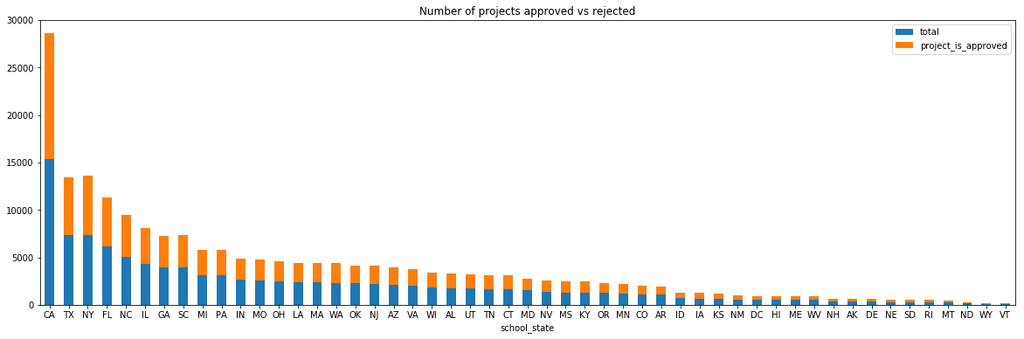

```python
statesCharacteristicsData = univariateBarPlots(projectsData, 'school_state', 'project_is_approved', orientation = 'vertical');
printStyle("Top 5 states with high project proposals", color.BOLD)
equalsBorder(60);
statesCharacteristicsData.head(5)
```

```python
printStyle("Top 5 states with least project proposals", color.BOLD)
equalsBorder(60);
statesCharacteristicsData.tail(5)
```

```
Top 5 states with least project proposals
============================================================
```

|  | school_state | project_is_approved | total | approval_rate |
| --- | --- | --- | --- | --- |
| 39 | RI | 243 | 285 | 0.852632 |
| 26 | MT | 200 | 245 | 0.816327 |
| 28 | ND | 127 | 143 | 0.888112 |
| 50 | WY | 82 | 98 | 0.836735 |
| 46 | VT | 64 | 80 | 0.800000 |

### Univariate Analysis: teacher_prefix

```
Project proposals characteristics based on types of persons
============================================================
```

|  | teacher_prefix | project_is_approved | total | approval_rate |
| --- | --- | --- | --- | --- |
| 2 | Mrs. | 48997 | 57269 | 0.855559 |
| 3 | Ms. | 32860 | 38955 | 0.843537 |
| 1 | Mr. | 8960 | 10648 | 0.841473 |
| 4 | Teacher | 1877 | 2360 | 0.795339 |
| 0 | Dr. | 9 | 13 | 0.692308 |

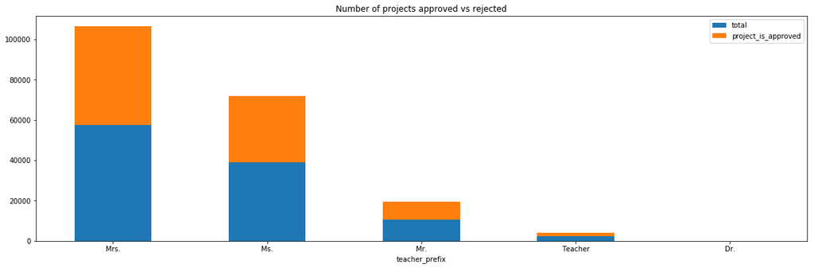

```python
teacherPrefixCharacteristicsData = univariateBarPlots(projectsData, 'teacher_prefix', 'project_is_approved', orientation = 'vertical', plot = True);
printStyle("Project proposals characteristics based on types of persons", color.BOLD);
equalsBorder(60);
teacherPrefixCharacteristicsData
```

### Observataion:

1. When compared to others Dr.'s have proposed very less number of projects.
2. Women have proposed more number of projects than men.

### Univariate Analysis: project_grade

```
Project proposal characteristics based on grades
============================================================
```

|  | project_grade_category | project_is_approved | total | approval_rate |
| --- | --- | --- | --- | --- |
| 3 | Grades PreK-2 | 37536 | 44225 | 0.848751 |
| 0 | Grades 3-5 | 31729 | 37137 | 0.854377 |
| 1 | Grades 6-8 | 14258 | 16923 | 0.842522 |
| 2 | Grades 9-12 | 9183 | 10963 | 0.837636 |

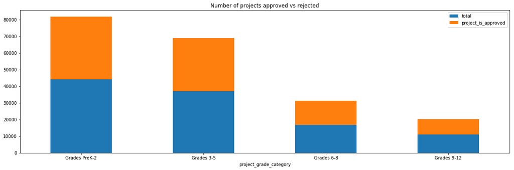

```python
gradeCharacteristicsData = univariateBarPlots(projectsData, 'project_grade_category', 'project_is_approved', orientation = 'vertical', plot = True);
printStyle("Project proposal characteristics based on grades", color.BOLD);
equalsBorder(60);
gradeCharacteristicsData
```

### Observation:

1. Most number of projects proposed are for students less than grade-5 (for primary school students) which means that children are being taught with project oriented teaching which is great.

### Univariate Analysis: project_subject_categories

```python
# remove special characters from list of strings python: https://stackoverflow.com/a/47301924/4084039

# https://www.geeksforgeeks.org/removing-stop-words-nltk-python/
# https://stackoverflow.com/questions/23669024/how-to-strip-a-specific-word-from-a-string
# https://stackoverflow.com/questions/8270092/remove-all-whitespace-in-a-string-in-python
def cleanCategories(subjectCategories):
    cleanedCategories = []
    for subjectCategory in tqdm(subjectCategories):
        tempCategory = ""
        for category in subjectCategory.split(","):
            if 'The' in category.split(): # this will split each of the catogory based on space "Math & Science"=> "Math","&", "Science"
                category = category.replace('The','') # if we have the words "The" we are going to replace it with ''(i.e removing 'The')
            category = category.replace(' ','') # we are placeing all the ' '(space) with ''(empty) ex:"Math & Science"=>"Math&Science"
            tempCategory += category.strip()+" "#" abc ".strip() will return "abc", remove the trailing spaces
            tempCategory = tempCategory.replace('&','_')
        cleanedCategories.append(tempCategory)
    return cleanedCategories
```

```python
# projectDataWithCleanedCategories = pd.DataFrame(projectsData);
subjectCategories = list(projectsData.project_subject_categories);
cleanedCategories = cleanCategories(subjectCategories);
printStyle("Sample categories: ", color.BOLD);
equalsBorder(60);
print(subjectCategories[0:5]);
equalsBorder(60);
printStyle("Sample cleaned categories: ", color.BOLD);
equalsBorder(60);
print(cleanedCategories[0:5]);
projectsData['cleaned_categories'] = cleanedCategories;
projectsData.head(5)
```

```
Sample categories:
============================================================
['Literacy & Language', 'History & Civics, Health & Sports', 'Health & Sports', 'Literacy & Language, Math & Science', 'Math & Science']
============================================================
Sample cleaned categories:
============================================================
['Literacy_Language ', 'History_Civics Health_Sports ', 'Health_Sports ', 'Literacy_Language Math_Science ', 'Math_Science ']
```

|  | Unnamed: 0 | id | teacher_id | teacher_prefix | school_state | project_submitted_datetime | project_grade_category | project_subject_categories | project_subject_subcategories | project_title | project_essay_1 | project_essay_2 | project_essay_3 | project_essay_4 | project_resource_summary | teacher_number_of_previously_posted_projects | project_is_approved | cleaned_categories |
| --- | --- | --- | --- | --- | --- | --- | --- | --- | --- | --- | --- | --- | --- | --- | --- | --- | --- | --- |
| 0 | 160221 | p253737 | c90749f5d961ff158d4b4d1e7dc665fc | Mrs. | IN | 2016-12-05 13:43:57 | Grades PreK-2 | Literacy & Language | ESL, Literacy | Educational Support for English Learners at Home | My students are English learners that are work... | \"The limits of your language are the limits o... | NaN | NaN | My students need opportunities to practice beg... | 0 | 0 | Literacy_Language |
| 1 | 140945 | p258326 | 897464ce9ddc600bced1151f324dd63a | Mr. | FL | 2016-10-25 09:22:10 | Grades 6-8 | History & Civics, Health & Sports | Civics & Government, Team Sports | Wanted: Projector for Hungry Learners | Our students arrive to our school eager to lea... | The projector we need for our school is very c... | NaN | NaN | My students need a projector to help with view... | 7 | 1 | History_Civics Health_Sports |
| 2 | 21895 | p182444 | 3465aaf82da834c0582ebd0ef8040ca0 | Ms. | AZ | 2016-08-31 12:03:56 | Grades 6-8 | Health & Sports | Health & Wellness, Team Sports | Soccer Equipment for AWESOME Middle School Stu... | \r\n\"True champions aren't always the ones th... | The students on the campus come to school know... | NaN | NaN | My students need shine guards, athletic socks,... | 1 | 0 | Health_Sports |
| 3 | 45 | p246581 | f3cb9bffbba169bef1a77b243e620b60 | Mrs. | KY | 2016-10-06 21:16:17 | Grades PreK-2 | Literacy & Language, Math & Science | Literacy, Mathematics | Techie Kindergarteners | I work at a unique school filled with both ESL... | My students live in high poverty conditions wi... | NaN | NaN | My students need to engage in Reading and Math... | 4 | 1 | Literacy_Language Math_Science |
| 4 | 172407 | p104768 | be1f7507a41f8479dc06f047086a39ec | Mrs. | TX | 2016-07-11 01:10:09 | Grades PreK-2 | Math & Science | Mathematics | Interactive Math Tools | Our second grade classroom next year will be m... | For many students, math is a subject that does... | NaN | NaN | My students need hands on practice in mathemat... | 1 | 1 | Math_Science |

```
Project proposals characteristics based on subject categories
============================================================
```

|  | cleaned_categories | project_is_approved | total | approval_rate |
| --- | --- | --- | --- | --- |
| 24 | Literacy_Language | 20520 | 23655 | 0.867470 |
| 32 | Math_Science | 13991 | 17072 | 0.819529 |
| 28 | Literacy_Language Math_Science | 12725 | 14636 | 0.869432 |
| 8 | Health_Sports | 8640 | 10177 | 0.848973 |
| 40 | Music_Arts | 4429 | 5180 | 0.855019 |

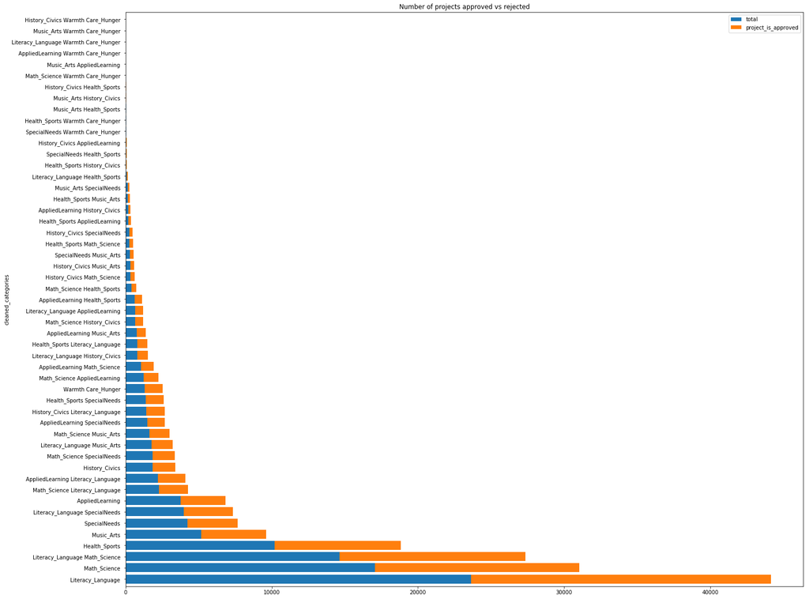

```python
categoriesCharacteristicsData = univariateBarPlots(projectsData, 'cleaned_categories', 'project_is_approved', orientation = 'horizontal', plot = True);
print("Project proposals characteristics based on subject categories");
equalsBorder(60);
categoriesCharacteristicsData.head(5)
```

```python
# count of all the words in corpus python: https://stackoverflow.com/a/22898595/4084039
categoriesCounter = Counter()
for subjectCategory in projectsData.cleaned_categories.values:
    categoriesCounter.update(subjectCategory.split());
categoriesCounter
```

```
Counter({'AppliedLearning': 12135,
         'Care_Hunger': 1388,
         'Health_Sports': 14223,
         'History_Civics': 5914,
         'Literacy_Language': 52239,
         'Math_Science': 41421,
         'Music_Arts': 10293,
         'SpecialNeeds': 13642,
         'Warmth': 1388})
```

```python
# count of all the words in corpus python: https://stackoverflow.com/a/22898595/4084039
categoriesDictionary = dict(categoriesCounter);
sortedCategoriesDictionary = dict(sorted(categoriesDictionary.items(), key = lambda keyValue: keyValue[1]));
sortedCategoriesData = pd.DataFrame.from_dict(sortedCategoriesDictionary, orient='index');
sortedCategoriesData.columns = ['subject_categories'];
printStyle("Number of projects by Subject Categories: ", color.BOLD);
equalsBorder(60);
sortedCategoriesData
```

```
Number of projects by Subject Categories:
============================================================
```

|  | subject_categories |
| --- | --- |
| Warmth | 1388 |
| Care_Hunger | 1388 |
| History_Civics | 5914 |
| Music_Arts | 10293 |
| AppliedLearning | 12135 |
| SpecialNeeds | 13642 |
| Health_Sports | 14223 |
| Math_Science | 41421 |
| Literacy_Language | 52239 |

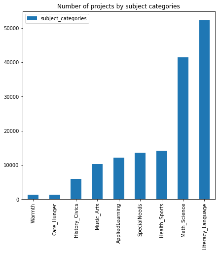

```python
sortedCategoriesData.plot(kind = 'bar', title = 'Number of projects by subject categories');
```

### Observation:

1. Many number of projects proposed belong to multiple subject categories.
2. When compared to others literacy_language & math_science have large number of project proposals.

### Univariate Analysis: project_subject_subcategories

```python
subjectSubCategories = projectsData.project_subject_subcategories;
cleanedSubCategories = cleanCategories(subjectSubCategories);
printStyle("Sample subject sub categories: ", color.BOLD);
equalsBorder(70);
print(subjectSubCategories[0:5]);
equalsBorder(70);
printStyle("Sample cleaned subject sub categories: ", color.BOLD);
equalsBorder(70);
print(cleanedSubCategories[0:5]);
projectsData['cleaned_sub_categories'] = cleanedSubCategories;
```

```
Sample subject sub categories:
======================================================================
0                       ESL, Literacy
1    Civics & Government, Team Sports
2      Health & Wellness, Team Sports
3               Literacy, Mathematics
4                         Mathematics
Name: project_subject_subcategories, dtype: object
======================================================================
Sample cleaned subject sub categories:
======================================================================
['ESL Literacy ', 'Civics_Government TeamSports ', 'Health_Wellness TeamSports ', 'Literacy Mathematics ', 'Mathematics ']
```

```python
projectsData.head(5)
```

|  | Unnamed: 0 | id | teacher_id | teacher_prefix | school_state | project_submitted_datetime | project_grade_category | project_subject_categories | project_subject_subcategories | project_title | project_essay_1 | project_essay_2 | project_essay_3 | project_essay_4 | project_resource_summary | teacher_number_of_previously_posted_projects | project_is_approved | cleaned_categories | cleaned_sub_categories |
| --- | --- | --- | --- | --- | --- | --- | --- | --- | --- | --- | --- | --- | --- | --- | --- | --- | --- | --- | --- |
| 0 | 160221 | p253737 | c90749f5d961ff158d4b4d1e7dc665fc | Mrs. | IN | 2016-12-05 13:43:57 | Grades PreK-2 | Literacy & Language | ESL, Literacy | Educational Support for English Learners at Home | My students are English learners that are work... | \"The limits of your language are the limits o... | NaN | NaN | My students need opportunities to practice beg... | 0 | 0 | Literacy_Language | ESL Literacy |
| 1 | 140945 | p258326 | 897464ce9ddc600bced1151f324dd63a | Mr. | FL | 2016-10-25 09:22:10 | Grades 6-8 | History & Civics, Health & Sports | Civics & Government, Team Sports | Wanted: Projector for Hungry Learners | Our students arrive to our school eager to lea... | The projector we need for our school is very c... | NaN | NaN | My students need a projector to help with view... | 7 | 1 | History_Civics Health_Sports | Civics_Government TeamSports |
| 2 | 21895 | p182444 | 3465aaf82da834c0582ebd0ef8040ca0 | Ms. | AZ | 2016-08-31 12:03:56 | Grades 6-8 | Health & Sports | Health & Wellness, Team Sports | Soccer Equipment for AWESOME Middle School Stu... | \r\n\"True champions aren't always the ones th... | The students on the campus come to school know... | NaN | NaN | My students need shine guards, athletic socks,... | 1 | 0 | Health_Sports | Health_Wellness TeamSports |
| 3 | 45 | p246581 | f3cb9bffbba169bef1a77b243e620b60 | Mrs. | KY | 2016-10-06 21:16:17 | Grades PreK-2 | Literacy & Language, Math & Science | Literacy, Mathematics | Techie Kindergarteners | I work at a unique school filled with both ESL... | My students live in high poverty conditions wi... | NaN | NaN | My students need to engage in Reading and Math... | 4 | 1 | Literacy_Language Math_Science | Literacy Mathematics |
| 4 | 172407 | p104768 | be1f7507a41f8479dc06f047086a39ec | Mrs. | TX | 2016-07-11 01:10:09 | Grades PreK-2 | Math & Science | Mathematics | Interactive Math Tools | Our second grade classroom next year will be m... | For many students, math is a subject that does... | NaN | NaN | My students need hands on practice in mathemat... | 1 | 1 | Math_Science | Mathematics |

```python
subCategoriesCharacteristicsData = univariateBarPlots(projectsData, 'cleaned_sub_categories', 'project_is_approved', plot = False);
print("Project proposals characteristics based on subject sub categories");
equalsBorder(60);
subCategoriesCharacteristicsData.head(5)
```

```
Project proposals characteristics based on subject sub categories
============================================================
```

|  | cleaned_sub_categories | project_is_approved | total | approval_rate |
| --- | --- | --- | --- | --- |
| 317 | Literacy | 8371 | 9486 | 0.882458 |
| 319 | Literacy Mathematics | 7260 | 8325 | 0.872072 |
| 331 | Literature_Writing Mathematics | 5140 | 5923 | 0.867803 |
| 318 | Literacy Literature_Writing | 4823 | 5571 | 0.865733 |
| 342 | Mathematics | 4385 | 5379 | 0.815207 |

```python
# count of all the words in corpus python: https://stackoverflow.com/a/22898595/4084039
subjectsSubCategoriesCounter = Counter();
for subCategory in projectsData.cleaned_sub_categories:
    subjectsSubCategoriesCounter.update(subCategory.split());
subjectsSubCategoriesCounter
```

```
Counter({'AppliedSciences': 10816,
         'Care_Hunger': 1388,
         'CharacterEducation': 2065,
         'Civics_Government': 815,
         'College_CareerPrep': 2568,
         'CommunityService': 441,
         'ESL': 4367,
         'EarlyDevelopment': 4254,
         'Economics': 269,
         'EnvironmentalScience': 5591,
         'Extracurricular': 810,
         'FinancialLiteracy': 568,
         'ForeignLanguages': 890,
         'Gym_Fitness': 4509,
         'Health_LifeScience': 4235,
         'Health_Wellness': 10234,
         'History_Geography': 3171,
         'Literacy': 33700,
         'Literature_Writing': 22179,
         'Mathematics': 28074,
         'Music': 3145,
         'NutritionEducation': 1355,
         'Other': 2372,
         'ParentInvolvement': 677,
         'PerformingArts': 1961,
         'SocialSciences': 1920,
         'SpecialNeeds': 13642,
         'TeamSports': 2192,
         'VisualArts': 6278,
         'Warmth': 1388})
```

```
Number of projects sorted by subject sub categories:
======================================================================
```

|  | subject_sub_categories |
| --- | --- |
| Economics | 269 |
| CommunityService | 441 |
| FinancialLiteracy | 568 |
| ParentInvolvement | 677 |
| Extracurricular | 810 |
| Civics_Government | 815 |
| ForeignLanguages | 890 |
| NutritionEducation | 1355 |
| Warmth | 1388 |
| Care_Hunger | 1388 |
| SocialSciences | 1920 |
| PerformingArts | 1961 |
| CharacterEducation | 2065 |
| TeamSports | 2192 |
| Other | 2372 |
| College_CareerPrep | 2568 |
| Music | 3145 |
| History_Geography | 3171 |
| Health_LifeScience | 4235 |
| EarlyDevelopment | 4254 |
| ESL | 4367 |
| Gym_Fitness | 4509 |
| EnvironmentalScience | 5591 |
| VisualArts | 6278 |
| Health_Wellness | 10234 |
| AppliedSciences | 10816 |
| SpecialNeeds | 13642 |
| Literature_Writing | 22179 |
| Mathematics | 28074 |
| Literacy | 33700 |

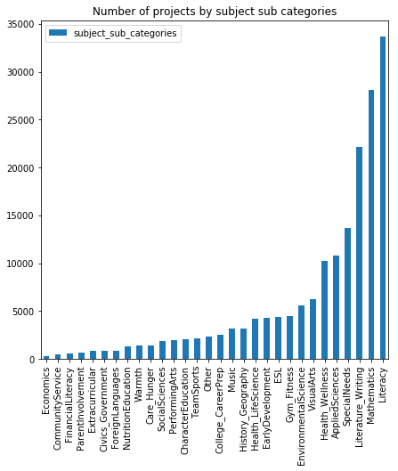

```python
# dict sort by value python: https://stackoverflow.com/a/613218/4084039
dictionarySubCategories = dict(subjectsSubCategoriesCounter);
sortedDictionarySubCategories = dict(sorted(dictionarySubCategories.items(), key = lambda keyValue: keyValue[1]));
sortedSubCategoriesData = pd.DataFrame.from_dict(sortedDictionarySubCategories, orient = 'index');
sortedSubCategoriesData.columns = ['subject_sub_categories']
sortedSubCategoriesData.plot(kind = 'bar', title = "Number of projects by subject sub categories");
printStyle("Number of projects sorted by subject sub categories: ", color.BOLD);
equalsBorder(70);
sortedSubCategoriesData
```

### Observation:

1. There are more number of subject subcategories than subject categories.
2. Even more number of projects proposed belong to multiple subject sub categories.

### Univariate Analysis : project_title

|  | number_of_words | number_of_projects |
| --- | --- | --- |
| 0 | 13 | 1 |
| 1 | 12 | 11 |
| 2 | 11 | 30 |
| 3 | 1 | 31 |
| 4 | 10 | 3968 |
| 5 | 9 | 5383 |
| 6 | 8 | 7289 |
| 7 | 2 | 8733 |
| 8 | 7 | 10631 |
| 9 | 6 | 14824 |
| 10 | 3 | 18691 |
| 11 | 5 | 19677 |
| 12 | 4 | 19979 |

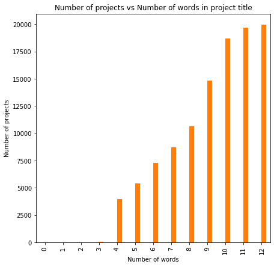

```python
#How to calculate number of words in a string in DataFrame: https://stackoverflow.com/a/37483537/4084039
wordCounts = projectsData['project_title'].str.split().apply(len).value_counts();
dictionaryWordCounts = dict(wordCounts);
dictionaryWordCounts = dict(sorted(dictionaryWordCounts.items(), key = lambda kv: kv[1]));
wordCountsData = pd.DataFrame.from_dict({'number_of_words': list(dictionaryWordCounts.keys()), 'number_of_projects': list(dictionaryWordCounts.values())}).sort_values(by = ['number_of_projects']);
wordCountsData.plot(kind = 'bar', title = "Number of projects vs Number of words in project title", legend = False);
plt.xlabel('Number of words');
plt.ylabel('Number of projects');
wordCountsData
```

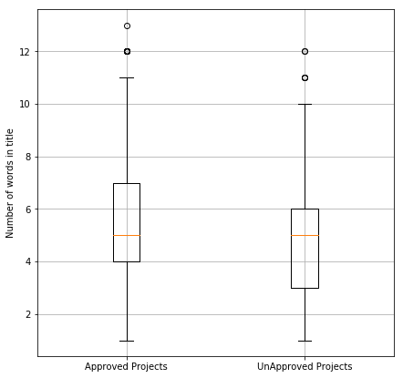

```python
approvedNumberOfProjects = projectsData[projectsData.project_is_approved == 1]['project_title'].str.split().apply(len);
approvedNumberOfProjects = approvedNumberOfProjects.values
unApprovedNumberOfProjects = projectsData[projectsData.project_is_approved == 0]['project_title'].str.split().apply(len);
unApprovedNumberOfProjects = unApprovedNumberOfProjects.values
plt.boxplot([approvedNumberOfProjects, unApprovedNumberOfProjects]);
plt.grid();
plt.xticks([1, 2], ['Approved Projects', 'UnApproved Projects']);
plt.ylabel('Number of words in title');
plt.show();
```

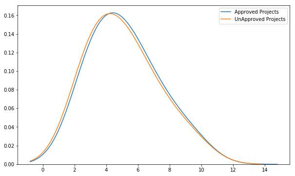

```python
plt.figure(figsize = (10, 6));
sbrn.kdeplot(approvedNumberOfProjects, label = "Approved Projects", bw = 0.6);
sbrn.kdeplot(unApprovedNumberOfProjects, label = "UnApproved Projects", bw = 0.6);
plt.legend();
plt.show();
```

### Univariate Analysis: project_essay_1,2,3,4

```python
projectsData['project_essay'] = projectsData['project_essay_1'].map(str) + projectsData['project_essay_2'].map(str) + \
                                projectsData['project_essay_3'].map(str) + projectsData['project_essay_4'].map(str);
projectsData.head(5)
```

|  | Unnamed: 0 | id | teacher_id | teacher_prefix | school_state | project_submitted_datetime | project_grade_category | project_subject_categories | project_subject_subcategories | project_title | project_essay_1 | project_essay_2 | project_essay_3 | project_essay_4 | project_resource_summary | teacher_number_of_previously_posted_projects | project_is_approved | cleaned_categories | cleaned_sub_categories | project_essay |
| --- | --- | --- | --- | --- | --- | --- | --- | --- | --- | --- | --- | --- | --- | --- | --- | --- | --- | --- | --- | --- |
| 0 | 160221 | p253737 | c90749f5d961ff158d4b4d1e7dc665fc | Mrs. | IN | 2016-12-05 13:43:57 | Grades PreK-2 | Literacy & Language | ESL, Literacy | Educational Support for English Learners at Home | My students are English learners that are work... | \"The limits of your language are the limits o... | NaN | NaN | My students need opportunities to practice beg... | 0 | 0 | Literacy_Language | ESL Literacy | My students are English learners that are work... |
| 1 | 140945 | p258326 | 897464ce9ddc600bced1151f324dd63a | Mr. | FL | 2016-10-25 09:22:10 | Grades 6-8 | History & Civics, Health & Sports | Civics & Government, Team Sports | Wanted: Projector for Hungry Learners | Our students arrive to our school eager to lea... | The projector we need for our school is very c... | NaN | NaN | My students need a projector to help with view... | 7 | 1 | History_Civics Health_Sports | Civics_Government TeamSports | Our students arrive to our school eager to lea... |
| 2 | 21895 | p182444 | 3465aaf82da834c0582ebd0ef8040ca0 | Ms. | AZ | 2016-08-31 12:03:56 | Grades 6-8 | Health & Sports | Health & Wellness, Team Sports | Soccer Equipment for AWESOME Middle School Stu... | \r\n\"True champions aren't always the ones th... | The students on the campus come to school know... | NaN | NaN | My students need shine guards, athletic socks,... | 1 | 0 | Health_Sports | Health_Wellness TeamSports | \r\n\"True champions aren't always the ones th... |
| 3 | 45 | p246581 | f3cb9bffbba169bef1a77b243e620b60 | Mrs. | KY | 2016-10-06 21:16:17 | Grades PreK-2 | Literacy & Language, Math & Science | Literacy, Mathematics | Techie Kindergarteners | I work at a unique school filled with both ESL... | My students live in high poverty conditions wi... | NaN | NaN | My students need to engage in Reading and Math... | 4 | 1 | Literacy_Language Math_Science | Literacy Mathematics | I work at a unique school filled with both ESL... |
| 4 | 172407 | p104768 | be1f7507a41f8479dc06f047086a39ec | Mrs. | TX | 2016-07-11 01:10:09 | Grades PreK-2 | Math & Science | Mathematics | Interactive Math Tools | Our second grade classroom next year will be m... | For many students, math is a subject that does... | NaN | NaN | My students need hands on practice in mathemat... | 1 | 1 | Math_Science | Mathematics | Our second grade classroom next year will be m... |

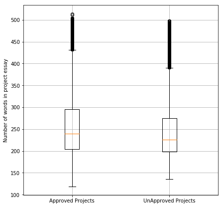

```python
approvedNumberOfProjects = projectsData[projectsData.project_is_approved == 1]['project_essay'].str.split().apply(len);
approvedNumberOfProjects = approvedNumberOfProjects.values
unApprovedNumberOfProjects = projectsData[projectsData.project_is_approved == 0]['project_essay'].str.split().apply(len);
unApprovedNumberOfProjects = unApprovedNumberOfProjects.values
plt.boxplot([approvedNumberOfProjects, unApprovedNumberOfProjects]);
plt.grid();
plt.xticks([1, 2], ['Approved Projects', 'UnApproved Projects']);
plt.ylabel('Number of words in project essay');
plt.show();
```

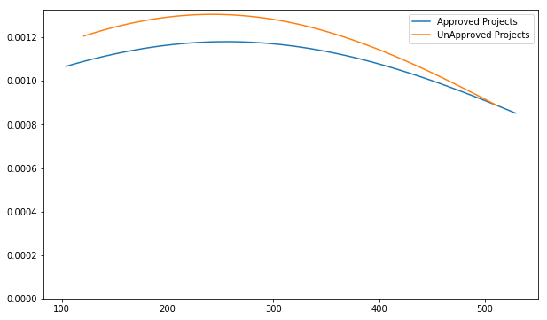

```python
plt.figure(figsize = (10, 6));
sbrn.kdeplot(approvedNumberOfProjects, label = "Approved Projects", bw = 5);
sbrn.kdeplot(unApprovedNumberOfProjects, label = "UnApproved Projects", bw = 5);
plt.legend();
plt.show();
```

### Observation:

1. The approved and rejected projects overlap largely when plotted based on number of words in project_essay. So we cannot predict any observation which will be useful for classification.

### Univariate Analysis: price

```python
projectsData.head(5)
```

|  | Unnamed: 0 | id | teacher_id | teacher_prefix | school_state | project_submitted_datetime | project_grade_category | project_subject_categories | project_subject_subcategories | project_title | project_essay_1 | project_essay_2 | project_essay_3 | project_essay_4 | project_resource_summary | teacher_number_of_previously_posted_projects | project_is_approved | cleaned_categories | cleaned_sub_categories | project_essay |
| --- | --- | --- | --- | --- | --- | --- | --- | --- | --- | --- | --- | --- | --- | --- | --- | --- | --- | --- | --- | --- |
| 0 | 160221 | p253737 | c90749f5d961ff158d4b4d1e7dc665fc | Mrs. | IN | 2016-12-05 13:43:57 | Grades PreK-2 | Literacy & Language | ESL, Literacy | Educational Support for English Learners at Home | My students are English learners that are work... | \"The limits of your language are the limits o... | NaN | NaN | My students need opportunities to practice beg... | 0 | 0 | Literacy_Language | ESL Literacy | My students are English learners that are work... |
| 1 | 140945 | p258326 | 897464ce9ddc600bced1151f324dd63a | Mr. | FL | 2016-10-25 09:22:10 | Grades 6-8 | History & Civics, Health & Sports | Civics & Government, Team Sports | Wanted: Projector for Hungry Learners | Our students arrive to our school eager to lea... | The projector we need for our school is very c... | NaN | NaN | My students need a projector to help with view... | 7 | 1 | History_Civics Health_Sports | Civics_Government TeamSports | Our students arrive to our school eager to lea... |
| 2 | 21895 | p182444 | 3465aaf82da834c0582ebd0ef8040ca0 | Ms. | AZ | 2016-08-31 12:03:56 | Grades 6-8 | Health & Sports | Health & Wellness, Team Sports | Soccer Equipment for AWESOME Middle School Stu... | \r\n\"True champions aren't always the ones th... | The students on the campus come to school know... | NaN | NaN | My students need shine guards, athletic socks,... | 1 | 0 | Health_Sports | Health_Wellness TeamSports | \r\n\"True champions aren't always the ones th... |
| 3 | 45 | p246581 | f3cb9bffbba169bef1a77b243e620b60 | Mrs. | KY | 2016-10-06 21:16:17 | Grades PreK-2 | Literacy & Language, Math & Science | Literacy, Mathematics | Techie Kindergarteners | I work at a unique school filled with both ESL... | My students live in high poverty conditions wi... | NaN | NaN | My students need to engage in Reading and Math... | 4 | 1 | Literacy_Language Math_Science | Literacy Mathematics | I work at a unique school filled with both ESL... |
| 4 | 172407 | p104768 | be1f7507a41f8479dc06f047086a39ec | Mrs. | TX | 2016-07-11 01:10:09 | Grades PreK-2 | Math & Science | Mathematics | Interactive Math Tools | Our second grade classroom next year will be m... | For many students, math is a subject that does... | NaN | NaN | My students need hands on practice in mathemat... | 1 | 1 | Math_Science | Mathematics | Our second grade classroom next year will be m... |

```python
resourcesData.head(5)
```

|  | id | description | quantity | price |
| --- | --- | --- | --- | --- |
| 0 | p233245 | LC652 - Lakeshore Double-Space Mobile Drying Rack | 1 | 149.00 |
| 1 | p069063 | Bouncy Bands for Desks (Blue support pipes) | 3 | 14.95 |
| 2 | p069063 | Cory Stories: A Kid's Book About Living With Adhd | 1 | 8.45 |
| 3 | p069063 | Dixon Ticonderoga Wood-Cased #2 HB Pencils, Bo... | 2 | 13.59 |
| 4 | p069063 | EDUCATIONAL INSIGHTS FLUORESCENT LIGHT FILTERS... | 3 | 24.95 |

```python
# https://stackoverflow.com/questions/22407798/how-to-reset-a-dataframes-indexes-for-all-groups-in-one-step
priceAndQuantityData = resourcesData.groupby('id').agg({'price': 'sum', 'quantity': 'sum'}).reset_index();
priceAndQuantityData.head(5)
```

|  | id | price | quantity |
| --- | --- | --- | --- |
| 0 | p000001 | 459.56 | 7 |
| 1 | p000002 | 515.89 | 21 |
| 2 | p000003 | 298.97 | 4 |
| 3 | p000004 | 1113.69 | 98 |
| 4 | p000005 | 485.99 | 8 |

```python
projectsData.shape
```

```
(109248, 20)
```

```python
projectsData = pd.merge(projectsData, priceAndQuantityData, on = 'id', how = 'left');
print(projectsData.shape);
projectsData.head(3)
```

```
(109248, 22)
```

|  | Unnamed: 0 | id | teacher_id | teacher_prefix | school_state | project_submitted_datetime | project_grade_category | project_subject_categories | project_subject_subcategories | project_title | project_essay_1 | project_essay_2 | project_essay_3 | project_essay_4 | project_resource_summary | teacher_number_of_previously_posted_projects | project_is_approved | cleaned_categories | cleaned_sub_categories | project_essay | price | quantity |
| --- | --- | --- | --- | --- | --- | --- | --- | --- | --- | --- | --- | --- | --- | --- | --- | --- | --- | --- | --- | --- | --- | --- |
| 0 | 160221 | p253737 | c90749f5d961ff158d4b4d1e7dc665fc | Mrs. | IN | 2016-12-05 13:43:57 | Grades PreK-2 | Literacy & Language | ESL, Literacy | Educational Support for English Learners at Home | My students are English learners that are work... | \"The limits of your language are the limits o... | NaN | NaN | My students need opportunities to practice beg... | 0 | 0 | Literacy_Language | ESL Literacy | My students are English learners that are work... | 154.60 | 23 |
| 1 | 140945 | p258326 | 897464ce9ddc600bced1151f324dd63a | Mr. | FL | 2016-10-25 09:22:10 | Grades 6-8 | History & Civics, Health & Sports | Civics & Government, Team Sports | Wanted: Projector for Hungry Learners | Our students arrive to our school eager to lea... | The projector we need for our school is very c... | NaN | NaN | My students need a projector to help with view... | 7 | 1 | History_Civics Health_Sports | Civics_Government TeamSports | Our students arrive to our school eager to lea... | 299.00 | 1 |
| 2 | 21895 | p182444 | 3465aaf82da834c0582ebd0ef8040ca0 | Ms. | AZ | 2016-08-31 12:03:56 | Grades 6-8 | Health & Sports | Health & Wellness, Team Sports | Soccer Equipment for AWESOME Middle School Stu... | \r\n\"True champions aren't always the ones th... | The students on the campus come to school know... | NaN | NaN | My students need shine guards, athletic socks,... | 1 | 0 | Health_Sports | Health_Wellness TeamSports | \r\n\"True champions aren't always the ones th... | 516.85 | 22 |

```python
projectsData[projectsData['id'] == 'p253737']
```

|  | Unnamed: 0 | id | teacher_id | teacher_prefix | school_state | project_submitted_datetime | project_grade_category | project_subject_categories | project_subject_subcategories | project_title | project_essay_1 | project_essay_2 | project_essay_3 | project_essay_4 | project_resource_summary | teacher_number_of_previously_posted_projects | project_is_approved | cleaned_categories | cleaned_sub_categories | project_essay | price | quantity |
| --- | --- | --- | --- | --- | --- | --- | --- | --- | --- | --- | --- | --- | --- | --- | --- | --- | --- | --- | --- | --- | --- | --- |
| 0 | 160221 | p253737 | c90749f5d961ff158d4b4d1e7dc665fc | Mrs. | IN | 2016-12-05 13:43:57 | Grades PreK-2 | Literacy & Language | ESL, Literacy | Educational Support for English Learners at Home | My students are English learners that are work... | \"The limits of your language are the limits o... | NaN | NaN | My students need opportunities to practice beg... | 0 | 0 | Literacy_Language | ESL Literacy | My students are English learners that are work... | 154.6 | 23 |

```python
priceAndQuantityData[priceAndQuantityData['id'] == 'p253737']
```

|  | id | price | quantity |
| --- | --- | --- | --- |
| 253736 | p253737 | 154.6 | 23 |

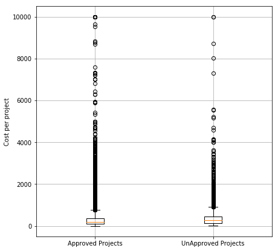

```python
approvedProjectsPrice = projectsData[projectsData['project_is_approved'] == 1].price;
unApprovedProjectsPrice = projectsData[projectsData['project_is_approved'] == 0].price;
plt.boxplot([approvedProjectsPrice, unApprovedProjectsPrice]);
plt.grid();
plt.xticks([1, 2], ['Approved Projects', 'UnApproved Projects']);
plt.ylabel('Cost per project');
plt.show();
```

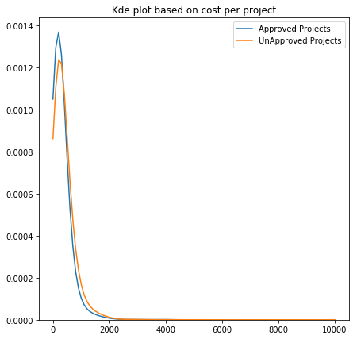

```python
plt.title("Kde plot based on cost per project");
sbrn.kdeplot(approvedProjectsPrice, label = "Approved Projects", bw = 0.6);
sbrn.kdeplot(unApprovedProjectsPrice, label = "UnApproved Projects", bw = 0.6);
plt.legend();
plt.show();
```

```python
pricePercentilesApproved = [round(np.percentile(approvedProjectsPrice, percentile), 3) for percentile in np.arange(0, 100, 5)];
pricePercentilesUnApproved = [round(np.percentile(unApprovedProjectsPrice, percentile), 3) for percentile in np.arange(0, 100, 5)];
percentileValuePricesData = pd.DataFrame({'Percentile': np.arange(0, 100, 5), 'Approved projects': pricePercentilesApproved, 'UnApproved Projects': pricePercentilesUnApproved});
percentileValuePricesData
```

|  | Percentile | Approved projects | UnApproved Projects |
| --- | --- | --- | --- |
| 0 | 0 | 0.660 | 1.970 |
| 1 | 5 | 13.590 | 41.900 |
| 2 | 10 | 33.880 | 73.670 |
| 3 | 15 | 58.000 | 99.109 |
| 4 | 20 | 77.380 | 118.560 |
| 5 | 25 | 99.950 | 140.892 |
| 6 | 30 | 116.680 | 162.230 |
| 7 | 35 | 137.232 | 184.014 |
| 8 | 40 | 157.000 | 208.632 |
| 9 | 45 | 178.265 | 235.106 |
| 10 | 50 | 198.990 | 263.145 |
| 11 | 55 | 223.990 | 292.610 |
| 12 | 60 | 255.630 | 325.144 |
| 13 | 65 | 285.412 | 362.390 |
| 14 | 70 | 321.225 | 399.990 |
| 15 | 75 | 366.075 | 449.945 |
| 16 | 80 | 411.670 | 519.282 |
| 17 | 85 | 479.000 | 618.276 |
| 18 | 90 | 593.110 | 739.356 |
| 19 | 95 | 801.598 | 992.486 |

### Observation:

1. Most of the projects proposed are of less cost.

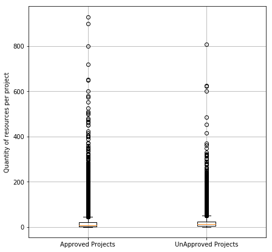

```python
approvedProjectsQuantity = projectsData[projectsData['project_is_approved'] == 1].quantity;
unApprovedProjectsQuantity = projectsData[projectsData['project_is_approved'] == 0].quantity;
plt.boxplot([approvedProjectsQuantity, unApprovedProjectsQuantity]);
plt.grid();
plt.xticks([1, 2], ['Approved Projects', 'UnApproved Projects']);
plt.ylabel('Quantity of resources per project');
plt.show();
```

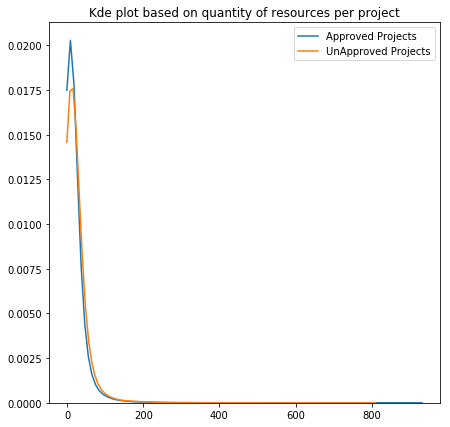

```python
plt.title("Kde plot based on quantity of resources per project");
sbrn.kdeplot(approvedProjectsQuantity, label = "Approved Projects", bw = 0.6);
sbrn.kdeplot(unApprovedProjectsQuantity, label = "UnApproved Projects", bw = 0.6);
plt.legend();
plt.show();
```

```python
quantityPercentilesApproved = [round(np.percentile(approvedProjectsQuantity, percentile), 3) for percentile in np.arange(0, 100, 5)];
quantityPercentilesUnApproved = [round(np.percentile(unApprovedProjectsQuantity, percentile), 3) for percentile in np.arange(0, 100, 5)];
percentileValueQuantitiesData = pd.DataFrame({'Percentile': np.arange(0, 100, 5), 'Approved projects': quantityPercentilesApproved, 'UnApproved Projects': quantityPercentilesUnApproved});
percentileValueQuantitiesData
```

|  | Percentile | Approved projects | UnApproved Projects |
| --- | --- | --- | --- |
| 0 | 0 | 1.0 | 1.0 |
| 1 | 5 | 1.0 | 2.0 |
| 2 | 10 | 1.0 | 3.0 |
| 3 | 15 | 2.0 | 4.0 |
| 4 | 20 | 3.0 | 5.0 |
| 5 | 25 | 3.0 | 6.0 |
| 6 | 30 | 4.0 | 7.0 |
| 7 | 35 | 5.0 | 8.0 |
| 8 | 40 | 6.0 | 9.0 |
| 9 | 45 | 7.0 | 10.0 |
| 10 | 50 | 8.0 | 12.0 |
| 11 | 55 | 10.0 | 13.0 |
| 12 | 60 | 11.0 | 15.0 |
| 13 | 65 | 14.0 | 18.0 |
| 14 | 70 | 16.0 | 20.0 |
| 15 | 75 | 20.0 | 24.0 |
| 16 | 80 | 25.0 | 29.0 |
| 17 | 85 | 30.0 | 35.0 |
| 18 | 90 | 38.0 | 45.0 |
| 19 | 95 | 56.0 | 63.0 |

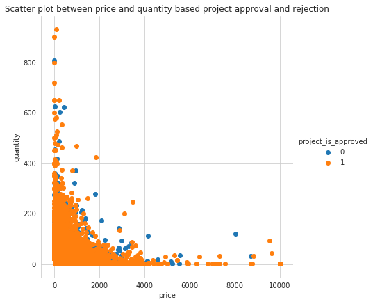

```python
sbrn.set_style('whitegrid');
sbrn.FacetGrid(projectsData, hue = 'project_is_approved', size = 6) \
    .map(plt.scatter, 'price', 'quantity') \
    .add_legend();
plt.title("Scatter plot between price and quantity based project approval and rejection");
plt.show();
```

### Observation:

1. When plotted scatter plot between approved and rejected projects based on price and quantity there is huge overlap. So the projects approval is not actually depending on price and quantity resources of the project.

### Univariate Analysis: teacher_number_of_previously_posted_projects

```python
projectsData.head(5)
```

|  | Unnamed: 0 | id | teacher_id | teacher_prefix | school_state | project_submitted_datetime | project_grade_category | project_subject_categories | project_subject_subcategories | project_title | project_essay_1 | project_essay_2 | project_essay_3 | project_essay_4 | project_resource_summary | teacher_number_of_previously_posted_projects | project_is_approved | cleaned_categories | cleaned_sub_categories | project_essay | price | quantity |
| --- | --- | --- | --- | --- | --- | --- | --- | --- | --- | --- | --- | --- | --- | --- | --- | --- | --- | --- | --- | --- | --- | --- |
| 0 | 160221 | p253737 | c90749f5d961ff158d4b4d1e7dc665fc | Mrs. | IN | 2016-12-05 13:43:57 | Grades PreK-2 | Literacy & Language | ESL, Literacy | Educational Support for English Learners at Home | My students are English learners that are work... | \"The limits of your language are the limits o... | NaN | NaN | My students need opportunities to practice beg... | 0 | 0 | Literacy_Language | ESL Literacy | My students are English learners that are work... | 154.60 | 23 |
| 1 | 140945 | p258326 | 897464ce9ddc600bced1151f324dd63a | Mr. | FL | 2016-10-25 09:22:10 | Grades 6-8 | History & Civics, Health & Sports | Civics & Government, Team Sports | Wanted: Projector for Hungry Learners | Our students arrive to our school eager to lea... | The projector we need for our school is very c... | NaN | NaN | My students need a projector to help with view... | 7 | 1 | History_Civics Health_Sports | Civics_Government TeamSports | Our students arrive to our school eager to lea... | 299.00 | 1 |
| 2 | 21895 | p182444 | 3465aaf82da834c0582ebd0ef8040ca0 | Ms. | AZ | 2016-08-31 12:03:56 | Grades 6-8 | Health & Sports | Health & Wellness, Team Sports | Soccer Equipment for AWESOME Middle School Stu... | \r\n\"True champions aren't always the ones th... | The students on the campus come to school know... | NaN | NaN | My students need shine guards, athletic socks,... | 1 | 0 | Health_Sports | Health_Wellness TeamSports | \r\n\"True champions aren't always the ones th... | 516.85 | 22 |
| 3 | 45 | p246581 | f3cb9bffbba169bef1a77b243e620b60 | Mrs. | KY | 2016-10-06 21:16:17 | Grades PreK-2 | Literacy & Language, Math & Science | Literacy, Mathematics | Techie Kindergarteners | I work at a unique school filled with both ESL... | My students live in high poverty conditions wi... | NaN | NaN | My students need to engage in Reading and Math... | 4 | 1 | Literacy_Language Math_Science | Literacy Mathematics | I work at a unique school filled with both ESL... | 232.90 | 4 |
| 4 | 172407 | p104768 | be1f7507a41f8479dc06f047086a39ec | Mrs. | TX | 2016-07-11 01:10:09 | Grades PreK-2 | Math & Science | Mathematics | Interactive Math Tools | Our second grade classroom next year will be m... | For many students, math is a subject that does... | NaN | NaN | My students need hands on practice in mathemat... | 1 | 1 | Math_Science | Mathematics | Our second grade classroom next year will be m... | 67.98 | 4 |

```python
previouslyPostedApprovedNumberData = projectsData.groupby('teacher_number_of_previously_posted_projects')['project_is_approved'].agg(lambda x: x.eq(1).sum()).reset_index();
previouslyPostedRejectedNumberData = projectsData.groupby('teacher_number_of_previously_posted_projects')['project_is_approved'].agg(lambda x: x.eq(0).sum()).reset_index();
print("Total number of projects approved: ", len(projectsData[projectsData['project_is_approved'] == 1]));
print("Total number of projects rejected: ", len(projectsData[projectsData['project_is_approved'] == 0]));
print("Number of projects approved categorized by previously_posted: ", previouslyPostedApprovedNumberData['project_is_approved'].sum());
print("Number of projects rejected categorized by previously_posted: ", previouslyPostedRejectedNumberData['project_is_approved'].sum());
previouslyPostedNumberData = pd.merge(previouslyPostedApprovedNumberData, previouslyPostedRejectedNumberData, on = 'teacher_number_of_previously_posted_projects', how = 'inner');
previouslyPostedNumberData.head(5)
```

```
Total number of projects approved:  92706
Total number of projects rejected:  16542
Number of projects approved categorized by previously_posted:  92706
Number of projects rejected categorized by previously_posted:  16542
```

|  | teacher_number_of_previously_posted_projects | project_is_approved_x | project_is_approved_y |
| --- | --- | --- | --- |
| 0 | 0 | 24652 | 5362 |
| 1 | 1 | 13329 | 2729 |
| 2 | 2 | 8705 | 1645 |
| 3 | 3 | 5997 | 1113 |
| 4 | 4 | 4452 | 814 |

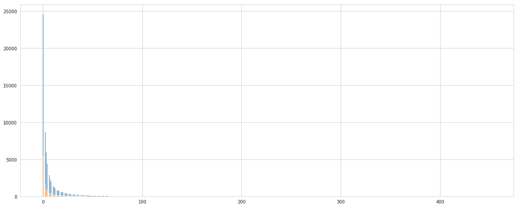

```python
plt.figure(figsize = (20, 8));
plt.bar(previouslyPostedNumberData.teacher_number_of_previously_posted_projects, previouslyPostedNumberData.project_is_approved_x);
plt.bar(previouslyPostedNumberData.teacher_number_of_previously_posted_projects, previouslyPostedNumberData.project_is_approved_y);
plt.show();
```

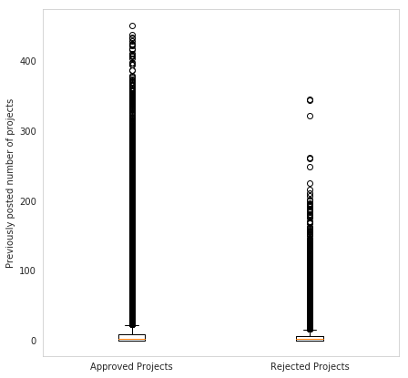

```python
previouslyPostedApprovedData = projectsData[projectsData['project_is_approved'] == 1].teacher_number_of_previously_posted_projects;
previouslyPostedRejectedData = projectsData[projectsData['project_is_approved'] == 0].teacher_number_of_previously_posted_projects;
plt.boxplot([previouslyPostedApprovedData, previouslyPostedRejectedData]);
plt.grid();
plt.xticks([1, 2], ['Approved Projects', 'Rejected Projects']);
plt.ylabel('Previously posted number of projects');
plt.show();
```

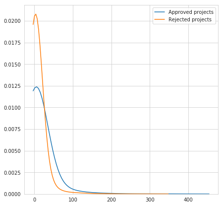

```python
sbrn.kdeplot(previouslyPostedApprovedData, label = "Approved projects", bw = 1);
sbrn.kdeplot(previouslyPostedRejectedData, label = "Rejected projects", bw = 1);
plt.show();
```

### Observation:

1. Most of the projects approved and rejected are with less number of teacher_number_of_previously_posted_projects. So the approval is not much depending on how many number of projects proposed by teacher previously.

```python
def stringContainsNumbers(string):
    return any([character.isdigit() for character in string])
```

```python
numericResourceApprovedData = projectsData[(projectsData['project_resource_summary'].apply(stringContainsNumbers) == True) & (projectsData['project_is_approved'] == 1)]
textResourceApprovedData = projectsData[(projectsData['project_resource_summary'].apply(stringContainsNumbers) == False) & (projectsData['project_is_approved'] == 1)]
numericResourceRejectedData = projectsData[(projectsData['project_resource_summary'].apply(stringContainsNumbers) == True) & (projectsData['project_is_approved'] == 0)]
textResourceRejectedData = projectsData[(projectsData['project_resource_summary'].apply(stringContainsNumbers) == False) & (projectsData['project_is_approved'] == 0)]
print("Checking whether numbers in resource summary will be useful for project approval?");
equalsBorder(70);
print("Number of approved projects with numbers in resource summary: ", numericResourceApprovedData.shape[0]);
print("Number of rejected projects with numbers in resource summary: ", numericResourceRejectedData.shape[0]);
print("Number of approved projects without numbers in resource summary: ", textResourceApprovedData.shape[0]);
print("Number of rejected projects without numbers in resource summary: ", textResourceRejectedData.shape[0]);
```

```
Checking whether numbers in resource summary will be useful for project approval?
======================================================================
Number of approved projects with numbers in resource summary:  14090
Number of rejected projects with numbers in resource summary:  1666
Number of approved projects without numbers in resource summary:  78616
Number of rejected projects without numbers in resource summary:  14876
```

### Observation:

1. The rejection rate of project is less when projects resource summary has numbers in it.
2. Even the number of projects approved without numbers in resource summary is high which means that the classification does not actually depends on whether resource summary contains numerical digits or not.

## Conclusion of univariate analysis:

1. There is huge overlap of approved and rejected projects when taken for all single featurs. So, this project cannot be classified using single features.
2. project_title is some what better in text type of feature because of less overlap than others.
3. The project approval is not depending on resources cost, but the probability of project rejection is more when resources cost is more.

## Preprocessing data

```python
# https://gist.github.com/sebleier/554280
# we are removing the words from the stop words list: 'no', 'nor', 'not'
# All stopwords that are needed to be removed in the text
stopWords= set(['br', 'the', 'i', 'me', 'my', 'myself', 'we', 'our', 'ours', 'ourselves', 'you', "you're", "you've",\
            "you'll", "you'd", 'your', 'yours', 'yourself', 'yourselves', 'he', 'him', 'his', 'himself', \
            'she', "she's", 'her', 'hers', 'herself', 'it', "it's", 'its', 'itself', 'they', 'them', 'their',\
            'theirs', 'themselves', 'what', 'which', 'who', 'whom', 'this', 'that', "that'll", 'these', 'those', \
            'am', 'is', 'are', 'was', 'were', 'be', 'been', 'being', 'have', 'has', 'had', 'having', 'do', 'does', \
            'did', 'doing', 'a', 'an', 'the', 'and', 'but', 'if', 'or', 'because', 'as', 'until', 'while', 'of', \
            'at', 'by', 'for', 'with', 'about', 'against', 'between', 'into', 'through', 'during', 'before', 'after',\
            'above', 'below', 'to', 'from', 'up', 'down', 'in', 'out', 'on', 'off', 'over', 'under', 'again', 'further',\
            'then', 'once', 'here', 'there', 'when', 'where', 'why', 'how', 'all', 'any', 'both', 'each', 'few', 'more',\
            'most', 'other', 'some', 'such', 'only', 'own', 'same', 'so', 'than', 'too', 'very', \
            's', 't', 'can', 'will', 'just', 'don', "don't", 'should', "should've", 'now', 'd', 'll', 'm', 'o', 're', \
            've', 'y', 'ain', 'aren', "aren't", 'couldn', "couldn't", 'didn', "didn't", 'doesn', "doesn't", 'hadn',\
            "hadn't", 'hasn', "hasn't", 'haven', "haven't", 'isn', "isn't", 'ma', 'mightn', "mightn't", 'mustn',\
            "mustn't", 'needn', "needn't", 'shan', "shan't", 'shouldn', "shouldn't", 'wasn', "wasn't", 'weren', "weren't", \
            'won', "won't", 'wouldn', "wouldn't"]);
def preProcessingWithAndWithoutStopWords(texts):
    """
    This function takes list of texts and returns preprocessed list of texts one with
    stop words and one without stopwords.
    """
    # Variable for storing preprocessed text with stop words
    preProcessedTextsWithStopWords = [];
    # Variable for storing preprocessed text without stop words
    preProcessedTextsWithoutStopWords = [];

    # Looping over list of texts for performing pre processing
    for text in tqdm(texts, total = len(texts)):
        # Removing all links in the text
        text = re.sub(r"http\S+", "", text);

        # Removing all html tags in the text
        text = re.sub(r"<\w+/>", "", text);
        text = re.sub(r"<\w+>", "", text);

        # https://stackoverflow.com/a/47091490/4084039
        # Replacing all below words with adverbs
        text = re.sub(r"won't", "will not", text)
        text = re.sub(r"can\'t", "can not", text)
        text = re.sub(r"n\'t", " not", text)
        text = re.sub(r"\'re", " are", text)
        text = re.sub(r"\'s", " is", text)
        text = re.sub(r"\'d", " would", text)
        text = re.sub(r"\'ll", " will", text)
        text = re.sub(r"\'t", " not", text)
        text = re.sub(r"\'ve", " have", text)
        text = re.sub(r"\'m", " am", text)

        # Removing backslash symbols in text
        text = text.replace('\\r', ' ');
        text = text.replace('\\n', ' ');
        text = text.replace('\\"', ' ');

        # Removing all special characters of text
        text = re.sub(r"[^a-zA-Z0-9]+", " ", text);

        # Converting whole review text into lower case
        text = text.lower();

        # adding this preprocessed text without stopwords to list
        preProcessedTextsWithStopWords.append(text);

        # removing stop words from text
        textWithoutStopWords = ' '.join([word for word in text.split() if word not in stopWords]);
        # adding this preprocessed text without stopwords to list
        preProcessedTextsWithoutStopWords.append(textWithoutStopWords);

    return [preProcessedTextsWithStopWords, preProcessedTextsWithoutStopWords];
```

```python
texts = [projectsData['project_essay'].values[0]]
preProcessedTextsWithStopWords, preProcessedTextsWithoutStopWords = preProcessingWithAndWithoutStopWords(texts);
print("Example project essay without pre-processing: ");
equalsBorder(70);
print(texts);
equalsBorder(70);
print("Example project essay with stop words and pre-processing: ");
equalsBorder(70);
print(preProcessedTextsWithStopWords);
equalsBorder(70);
print("Example project essay without stop words and pre-processing: ");
equalsBorder(70);
print(preProcessedTextsWithoutStopWords);
```

```
Example project essay without pre-processing:
======================================================================
['My students are English learners that are working on English as their second or third languages. We are a melting pot of refugees, immigrants, and native-born Americans bringing the gift of language to our school. \\r\\n\\r\\n We have over 24 languages represented in our English Learner program wi…
======================================================================
Example project essay with stop words and pre-processing:
======================================================================
['my students are english learners that are working on english as their second or third languages we are a melting pot of refugees immigrants and native born americans bringing the gift of language to our school we have over 24 languages represented in our english learner program with students at ev…
======================================================================
Example project essay without stop words and pre-processing:
======================================================================
['students english learners working english second third languages melting pot refugees immigrants native born americans bringing gift language school 24 languages represented english learner program students every level mastery also 40 countries represented families within school student brings wea…
```

```python
projectEssays = projectsData['project_essay'];
preProcessedEssaysWithStopWords, preProcessedEssaysWithoutStopWords = preProcessingWithAndWithoutStopWords(projectEssays);
```

```python
preProcessedEssaysWithoutStopWords[0:3]
```

```
['students english learners working english second third languages melting pot refugees immigrants native born americans bringing gift language school 24 languages represented english learner program students every level mastery also 40 countries represented families within school student brings wea…
 'students arrive school eager learn polite generous strive best know education succeed life help improve lives school focuses families low incomes tries give student education deserve not much students use materials given best projector need school crucial academic improvement students technology c…
 'true champions not always ones win guts mia hamm quote best describes students cholla middle school approach playing sports especially girls boys soccer teams teams made 7th 8th grade students not opportunity play organized sport due family financial difficulties teach title one middle school urba…
```

```python
projectTitles = projectsData['project_title'];
preProcessedProjectTitlesWithStopWords, preProcessedProjectTitlesWithoutStopWords = preProcessingWithAndWithoutStopWords(projectTitles);
preProcessedProjectTitlesWithoutStopWords[0:5]
```

```
['educational support english learners home',
 'wanted projector hungry learners',
 'soccer equipment awesome middle school students',
 'techie kindergarteners',
 'interactive math tools']
```

```python
projectsData['preprocessed_titles'] = preProcessedProjectTitlesWithoutStopWords;
projectsData['preprocessed_essays'] = preProcessedEssaysWithoutStopWords;
projectsData.shape
```

```
(109248, 24)
```

## Preparing data for classification and modelling

```python
pd.DataFrame(projectsData.columns, columns = ['All features in projects data'])
```

|  | All features in projects data |
| --- | --- |
| 0 | Unnamed: 0 |
| 1 | id |
| 2 | teacher_id |
| 3 | teacher_prefix |
| 4 | school_state |
| 5 | project_submitted_datetime |
| 6 | project_grade_category |
| 7 | project_subject_categories |
| 8 | project_subject_subcategories |
| 9 | project_title |
| 10 | project_essay_1 |
| 11 | project_essay_2 |
| 12 | project_essay_3 |
| 13 | project_essay_4 |
| 14 | project_resource_summary |
| 15 | teacher_number_of_previously_posted_projects |
| 16 | project_is_approved |
| 17 | cleaned_categories |
| 18 | cleaned_sub_categories |
| 19 | project_essay |
| 20 | price |
| 21 | quantity |
| 22 | preprocessed_titles |
| 23 | preprocessed_essays |

### Useful features:

#### Here we will consider only below features for classification and we can ignore the other features

##### Categorical data:

1. **school_state** - categorical data
2. **project_grade_category** - categorical data
3. **cleaned_categories** - categorical data
4. **cleaned_sub_categories** - categorical data
5. **teacher_prefix** - categorical data

##### Text data:

1. **project_resource_summary** - text data
2. **project_title - text data**
3. **project_resource_summary** - text data

##### Numerical data:

1. **teacher_number_of_previously_posted_projects** - numerical data
2. **price** - numerical data
3. **quantity** - numerical data

## Vectorizing categorical data

### 1. Vectorizing cleaned_categories(project_subject_categories cleaned) - One Hot Encoding

```python
# Using CountVectorizer for performing one-hot-encoding by setting vocabulary as list of all unique cleaned_categories
subjectsCategoriesVectorizer = CountVectorizer(vocabulary = list(sortedCategoriesDictionary.keys()), lowercase = False, binary = True);
# Fitting CountVectorizer with cleaned_categories values
subjectsCategoriesVectorizer.fit(projectsData['cleaned_categories'].values);
# Vectorizing categories using one-hot-encoding
categoriesVectors = subjectsCategoriesVectorizer.transform(projectsData['cleaned_categories'].values);
```

```python
print("Features used in vectorizing categories: ");
equalsBorder(70);
print(subjectsCategoriesVectorizer.get_feature_names());
equalsBorder(70);
print("Shape of cleaned_categories matrix after vectorization(one-hot-encoding): ", categoriesVectors.shape);
equalsBorder(70);
print("Sample vectors of categories: ");
equalsBorder(70);
print(categoriesVectors[0:4])
```

```
Features used in vectorizing categories:
======================================================================
['Warmth', 'Care_Hunger', 'History_Civics', 'Music_Arts', 'AppliedLearning', 'SpecialNeeds', 'Health_Sports', 'Math_Science', 'Literacy_Language']
======================================================================
Shape of cleaned_categories matrix after vectorization(one-hot-encoding):  (109248, 9)
======================================================================
Sample vectors of categories:
======================================================================
  (0, 8)	1
  (1, 2)	1
  (1, 6)	1
  (2, 6)	1
  (3, 7)	1
  (3, 8)	1
```

### 2. Vectorizing cleaned_sub_categories(project_subject_sub_categories cleaned) - One Hot Encoding

```python
# Using CountVectorizer for performing one-hot-encoding by setting vocabulary as list of all unique cleaned_sub_categories
subjectsSubCategoriesVectorizer = CountVectorizer(vocabulary = list(sortedDictionarySubCategories.keys()), lowercase = False, binary = True);
# Fitting CountVectorizer with cleaned_sub_categories values
subjectsSubCategoriesVectorizer.fit(projectsData['cleaned_sub_categories'].values);
# Vectorizing sub categories using one-hot-encoding
subCategoriesVectors = subjectsSubCategoriesVectorizer.transform(projectsData['cleaned_sub_categories'].values);
```

```python
print("Features used in vectorizing subject sub categories: ");
equalsBorder(70);
print(subjectsSubCategoriesVectorizer.get_feature_names());
equalsBorder(70);
print("Shape of cleaned_categories matrix after vectorization(one-hot-encoding): ", subCategoriesVectors.shape);
equalsBorder(70);
print("Sample vectors of categories: ");
equalsBorder(70);
print(subCategoriesVectors[0:4])
```

```
Features used in vectorizing subject sub categories:
======================================================================
['Economics', 'CommunityService', 'FinancialLiteracy', 'ParentInvolvement', 'Extracurricular', 'Civics_Government', 'ForeignLanguages', 'NutritionEducation', 'Warmth', 'Care_Hunger', 'SocialSciences', 'PerformingArts', 'CharacterEducation', 'TeamSports', 'Other', 'College_CareerPrep', 'Music', 'Hist…
======================================================================
Shape of cleaned_categories matrix after vectorization(one-hot-encoding):  (109248, 30)
======================================================================
Sample vectors of categories:
======================================================================
  (0, 20)	1
  (0, 29)	1
  (1, 5)	1
  (1, 13)	1
  (2, 13)	1
  (2, 24)	1
  (3, 28)	1
  (3, 29)	1
```

### 3. Vectorizing teacher_prefix - One Hot Encoding

```python
def giveCounter(data):
    counter = Counter();
    for dataValue in data:
        counter.update(str(dataValue).split());
    return counter
```

```python
giveCounter(projectsData['teacher_prefix'].values)
```

```
Counter({'Mrs.': 57269,
         'Mr.': 10648,
         'Ms.': 38955,
         'Teacher': 2360,
         'nan': 3,
         'Dr.': 13})
```

```python
projectsData = projectsData.dropna(subset = ['teacher_prefix']);
projectsData.shape
```

```
(109245, 22)
```

```python
teacherPrefixDictionary = dict(giveCounter(projectsData['teacher_prefix'].values));
# Using CountVectorizer for performing one-hot-encoding by setting vocabulary as list of all unique teacher_prefix
teacherPrefixVectorizer = CountVectorizer(vocabulary = list(teacherPrefixDictionary.keys()), lowercase = False, binary = True);
# Fitting CountVectorizer with teacher_prefix values
teacherPrefixVectorizer.fit(projectsData['teacher_prefix'].values);
# Vectorizing teacher_prefix using one-hot-encoding
teacherPrefixVectors = teacherPrefixVectorizer.transform(projectsData['teacher_prefix'].values);
```

```python
print("Features used in vectorizing teacher_prefix: ");
equalsBorder(70);
print(teacherPrefixVectorizer.get_feature_names());
equalsBorder(70);
print("Shape of teacher_prefix matrix after vectorization(one-hot-encoding): ", teacherPrefixVectors.shape);
equalsBorder(70);
print("Sample vectors of teacher_prefix: ");
equalsBorder(70);
print(teacherPrefixVectors[0:100]);
```

```
Features used in vectorizing teacher_prefix:
======================================================================
['Mrs.', 'Mr.', 'Ms.', 'Teacher', 'Dr.']
======================================================================
Shape of teacher_prefix matrix after vectorization(one-hot-encoding):  (109245, 5)
======================================================================
Sample vectors of teacher_prefix:
======================================================================
  (27, 3)	1
  (75, 3)	1
  (82, 3)	1
  (88, 3)	1
```

```python
teacherPrefixes = [prefix.replace('.', '') for prefix in projectsData['teacher_prefix'].values];
teacherPrefixes[0:5]
```

```
['Mrs', 'Mr', 'Ms', 'Mrs', 'Mrs']
```

```python
projectsData['teacher_prefix'] = teacherPrefixes;
projectsData.head(3)
```

|  | Unnamed: 0 | id | teacher_id | teacher_prefix | school_state | project_submitted_datetime | project_grade_category | project_subject_categories | project_subject_subcategories | project_title | ... | project_essay_3 | project_essay_4 | project_resource_summary | teacher_number_of_previously_posted_projects | project_is_approved | cleaned_categories | cleaned_sub_categories | project_essay | price | quantity |
| --- | --- | --- | --- | --- | --- | --- | --- | --- | --- | --- | --- | --- | --- | --- | --- | --- | --- | --- | --- | --- | --- |
| 0 | 160221 | p253737 | c90749f5d961ff158d4b4d1e7dc665fc | Mrs | IN | 2016-12-05 13:43:57 | Grades PreK-2 | Literacy & Language | ESL, Literacy | Educational Support for English Learners at Home | ... | NaN | NaN | My students need opportunities to practice beg... | 0 | 0 | Literacy_Language | ESL Literacy | My students are English learners that are work... | 154.60 | 23 |
| 1 | 140945 | p258326 | 897464ce9ddc600bced1151f324dd63a | Mr | FL | 2016-10-25 09:22:10 | Grades 6-8 | History & Civics, Health & Sports | Civics & Government, Team Sports | Wanted: Projector for Hungry Learners | ... | NaN | NaN | My students need a projector to help with view... | 7 | 1 | History_Civics Health_Sports | Civics_Government TeamSports | Our students arrive to our school eager to lea... | 299.00 | 1 |
| 2 | 21895 | p182444 | 3465aaf82da834c0582ebd0ef8040ca0 | Ms | AZ | 2016-08-31 12:03:56 | Grades 6-8 | Health & Sports | Health & Wellness, Team Sports | Soccer Equipment for AWESOME Middle School Stu... | ... | NaN | NaN | My students need shine guards, athletic socks,... | 1 | 0 | Health_Sports | Health_Wellness TeamSports | \r\n\"True champions aren't always the ones th... | 516.85 | 22 |

3 rows × 22 columns

```python
teacherPrefixDictionary = dict(giveCounter(projectsData['teacher_prefix'].values));
# Using CountVectorizer for performing one-hot-encoding by setting vocabulary as list of all unique teacher_prefix
teacherPrefixVectorizer = CountVectorizer(vocabulary = list(teacherPrefixDictionary.keys()), lowercase = False, binary = True);
# Fitting CountVectorizer with teacher_prefix values
teacherPrefixVectorizer.fit(projectsData['teacher_prefix'].values);
# Vectorizing teacher_prefix using one-hot-encoding
teacherPrefixVectors = teacherPrefixVectorizer.transform(projectsData['teacher_prefix'].values);
```

```python
print("Features used in vectorizing teacher_prefix: ");
equalsBorder(70);
print(teacherPrefixVectorizer.get_feature_names());
equalsBorder(70);
print("Shape of teacher_prefix matrix after vectorization(one-hot-encoding): ", teacherPrefixVectors.shape);
equalsBorder(70);
print("Sample vectors of teacher_prefix: ");
equalsBorder(70);
print(teacherPrefixVectors[0:4]);
```

```
Features used in vectorizing teacher_prefix:
======================================================================
['Mrs', 'Mr', 'Ms', 'Teacher', 'Dr']
======================================================================
Shape of teacher_prefix matrix after vectorization(one-hot-encoding):  (109245, 5)
======================================================================
Sample vectors of teacher_prefix:
======================================================================
  (0, 0)	1
  (1, 1)	1
  (2, 2)	1
  (3, 0)	1
```

### 4. Vectorizing school_state - One Hot Encoding

```python
schoolStateDictionary = dict(giveCounter(projectsData['school_state'].values));
# Using CountVectorizer for performing one-hot-encoding by setting vocabulary as list of all unique school states
schoolStateVectorizer = CountVectorizer(vocabulary = list(schoolStateDictionary.keys()), lowercase = False, binary = True);
# Fitting CountVectorizer with school_state values
schoolStateVectorizer.fit(projectsData['school_state'].values);
# Vectorizing school_state using one-hot-encoding
schoolStateVectors = schoolStateVectorizer.transform(projectsData['school_state'].values);
```

```python
print("Features used in vectorizing school_state: ");
equalsBorder(70);
print(schoolStateVectorizer.get_feature_names());
equalsBorder(70);
print("Shape of school_state matrix after vectorization(one-hot-encoding): ", schoolStateVectors.shape);
equalsBorder(70);
print("Sample vectors of school_state: ");
equalsBorder(70);
print(schoolStateVectors[0:4]);
```

```
Features used in vectorizing school_state:
======================================================================
['IN', 'FL', 'AZ', 'KY', 'TX', 'CT', 'GA', 'SC', 'NC', 'CA', 'NY', 'OK', 'MA', 'NV', 'OH', 'PA', 'AL', 'LA', 'VA', 'AR', 'WA', 'WV', 'ID', 'TN', 'MS', 'CO', 'UT', 'IL', 'MI', 'HI', 'IA', 'RI', 'NJ', 'MO', 'DE', 'MN', 'ME', 'WY', 'ND', 'OR', 'AK', 'MD', 'WI', 'SD', 'NE', 'NM', 'DC', 'KS', 'MT', 'NH',…
======================================================================
Shape of school_state matrix after vectorization(one-hot-encoding):  (109245, 51)
======================================================================
Sample vectors of school_state:
======================================================================
  (0, 0)	1
  (1, 1)	1
  (2, 2)	1
  (3, 3)	1
```

### 5. Vectorizing project_grade_category - One Hot Encoding

```python
giveCounter(projectsData['project_grade_category'])
```

```
Counter({'Grades': 109245,
         'PreK-2': 44225,
         '6-8': 16923,
         '3-5': 37135,
         '9-12': 10962})
```

```python
cleanedGrades = []
for grade in projectsData['project_grade_category'].values:
    grade = grade.replace(' ', '');
    grade = grade.replace('-', 'to');
    cleanedGrades.append(grade);
cleanedGrades[0:4]
```

```
['GradesPreKto2', 'Grades6to8', 'Grades6to8', 'GradesPreKto2']
```

```python
projectsData['project_grade_category'] = cleanedGrades
projectsData.head(4)
```

|  | Unnamed: 0 | id | teacher_id | teacher_prefix | school_state | project_submitted_datetime | project_grade_category | project_subject_categories | project_subject_subcategories | project_title | ... | project_essay_3 | project_essay_4 | project_resource_summary | teacher_number_of_previously_posted_projects | project_is_approved | cleaned_categories | cleaned_sub_categories | project_essay | price | quantity |
| --- | --- | --- | --- | --- | --- | --- | --- | --- | --- | --- | --- | --- | --- | --- | --- | --- | --- | --- | --- | --- | --- |
| 0 | 160221 | p253737 | c90749f5d961ff158d4b4d1e7dc665fc | Mrs | IN | 2016-12-05 13:43:57 | GradesPreKto2 | Literacy & Language | ESL, Literacy | Educational Support for English Learners at Home | ... | NaN | NaN | My students need opportunities to practice beg... | 0 | 0 | Literacy_Language | ESL Literacy | My students are English learners that are work... | 154.60 | 23 |
| 1 | 140945 | p258326 | 897464ce9ddc600bced1151f324dd63a | Mr | FL | 2016-10-25 09:22:10 | Grades6to8 | History & Civics, Health & Sports | Civics & Government, Team Sports | Wanted: Projector for Hungry Learners | ... | NaN | NaN | My students need a projector to help with view... | 7 | 1 | History_Civics Health_Sports | Civics_Government TeamSports | Our students arrive to our school eager to lea... | 299.00 | 1 |
| 2 | 21895 | p182444 | 3465aaf82da834c0582ebd0ef8040ca0 | Ms | AZ | 2016-08-31 12:03:56 | Grades6to8 | Health & Sports | Health & Wellness, Team Sports | Soccer Equipment for AWESOME Middle School Stu... | ... | NaN | NaN | My students need shine guards, athletic socks,... | 1 | 0 | Health_Sports | Health_Wellness TeamSports | \r\n\"True champions aren't always the ones th... | 516.85 | 22 |
| 3 | 45 | p246581 | f3cb9bffbba169bef1a77b243e620b60 | Mrs | KY | 2016-10-06 21:16:17 | GradesPreKto2 | Literacy & Language, Math & Science | Literacy, Mathematics | Techie Kindergarteners | ... | NaN | NaN | My students need to engage in Reading and Math... | 4 | 1 | Literacy_Language Math_Science | Literacy Mathematics | I work at a unique school filled with both ESL... | 232.90 | 4 |

4 rows × 22 columns

```python
projectGradeDictionary = dict(giveCounter(projectsData['project_grade_category'].values));
# Using CountVectorizer for performing one-hot-encoding by setting vocabulary as list of all unique project grade categories
projectGradeVectorizer = CountVectorizer(vocabulary = list(projectGradeDictionary.keys()), lowercase = False, binary = True);
# Fitting CountVectorizer with project_grade_category values
projectGradeVectorizer.fit(projectsData['project_grade_category'].values);
# Vectorizing project_grade_category using one-hot-encoding
projectGradeVectors = projectGradeVectorizer.transform(projectsData['project_grade_category'].values);
```

```python
print("Features used in vectorizing project_grade_category: ");
equalsBorder(70);
print(projectGradeVectorizer.get_feature_names());
equalsBorder(70);
print("Shape of school_state matrix after vectorization(one-hot-encoding): ", projectGradeVectors.shape);
equalsBorder(70);
print("Sample vectors of school_state: ");
equalsBorder(70);
print(projectGradeVectors[0:4]);
```

```
Features used in vectorizing project_grade_category:
======================================================================
['GradesPreKto2', 'Grades6to8', 'Grades3to5', 'Grades9to12']
======================================================================
Shape of school_state matrix after vectorization(one-hot-encoding):  (109245, 4)
======================================================================
Sample vectors of school_state:
======================================================================
  (0, 0)	1
  (1, 1)	1
  (2, 1)	1
  (3, 0)	1
```

```python
projectsDataSub = projectsData[0:40000];
preProcessedEssaysWithoutStopWordsSub = preProcessedEssaysWithoutStopWords[0:40000];
preProcessedProjectTitlesWithoutStopWordsSub = preProcessedProjectTitlesWithoutStopWords[0:40000];
```

## Vectorizing Text Data

### Bag of Words

#### 1. Vectorizing project_essay

```python
# Initializing countvectorizer for bag of words vectorization of preprocessed project essays
bowEssayVectorizer = CountVectorizer(min_df = 10);
# Transforming the preprocessed essays to bag of words vectors
bowEssayModel = bowEssayVectorizer.fit_transform(preProcessedEssaysWithoutStopWordsSub);
```

```python
print("Some of the Features used in vectorizing preprocessed essays: ");
equalsBorder(70);
print(bowEssayVectorizer.get_feature_names()[-40:]);
equalsBorder(70);
print("Shape of preprocessed essay matrix after vectorization: ", bowEssayModel.shape);
equalsBorder(70);
print("Sample bag-of-words vector of preprocessed essay: ");
equalsBorder(70);
print(bowEssayModel[0])
```

```
Some of the Features used in vectorizing preprocessed essays:
======================================================================
['yeats', 'yell', 'yelling', 'yellow', 'yemen', 'yes', 'yesterday', 'yet', 'yield', 'yields', 'yoga', 'york', 'younannan', 'young', 'younger', 'youngest', 'youngsters', 'youth', 'youthful', 'youths', 'youtube', 'yummy', 'zeal', 'zearn', 'zen', 'zenergy', 'zero', 'zest', 'zip', 'ziploc', 'zippers', '…
======================================================================
Shape of preprocessed essay matrix after vectorization:  (40000, 11077)
======================================================================
Sample bag-of-words vector of preprocessed essay:
======================================================================
  (0, 6533)	1
  (0, 3306)	1
  (0, 1981)	1
  (0, 11036)	1
  (0, 7347)	1
  (0, 11029)	1
  (0, 10530)	2
  (0, 1734)	1
  (0, 6855)	1
  (0, 7374)	2
  (0, 232)	1
  (0, 6687)	1
  (0, 3211)	1
  (0, 2805)	1
  (0, 10766)	1
  (0, 8133)	1
  (0, 8803)	1
  (0, 9831)	1
  (0, 1794)	1
  (0, 9237)	1
  (0, 10639)	3
  (0, 3274)	2
  (0, 7068)	1
  (0, 6798)	1
  (0, 9399)	1
  :	:
  (0, 6123)	2
  (0, 5785)	2
  (0, 3613)	1
  (0, 7703)	2
  (0, 5732)	3
  (0, 8269)	2
  (0, 67)	1
  (0, 8670)	2
  (0, 5664)	3
  (0, 4383)	1
  (0, 1339)	1
  (0, 553)	1
  (0, 1248)	1
  (0, 6549)	1
  (0, 5003)	1
  (0, 8116)	1
  (0, 7501)	1
  (0, 6207)	1
  (0, 5665)	2
  (0, 9968)	1
  (0, 8736)	1
  (0, 10964)	1
  (0, 5733)	1
  (0, 3449)	7
  (0, 9553)	5
```

#### 2. Vectorizing project_title

```python
# Initializing countvectorizer for bag of words vectorization of preprocessed project titles
bowTitleVectorizer = CountVectorizer(min_df = 10);
# Transforming the preprocessed project titles to bag of words vectors
bowTitleModel = bowTitleVectorizer.fit_transform(preProcessedProjectTitlesWithoutStopWordsSub);
```

```python
print("Some of the Features used in vectorizing preprocessed titles: ");
equalsBorder(70);
print(bowTitleVectorizer.get_feature_names()[-40:]);
equalsBorder(70);
print("Shape of preprocessed title matrix after vectorization: ", bowTitleModel.shape);
equalsBorder(70);
print("Sample bag-of-words vector of preprocessed title: ");
equalsBorder(70);
print(bowTitleModel[0])
```

```
Some of the Features used in vectorizing preprocessed titles:
======================================================================
['wireless', 'wise', 'wish', 'within', 'without', 'wizards', 'wo', 'wobble', 'wobbles', 'wobbling', 'wobbly', 'wonder', 'wonderful', 'wonders', 'word', 'words', 'work', 'workers', 'working', 'works', 'workshop', 'world', 'worlds', 'worms', 'worth', 'would', 'wow', 'write', 'writer', 'writers', 'writ…
======================================================================
Shape of preprocessed title matrix after vectorization:  (40000, 1774)
======================================================================
Sample bag-of-words vector of preprocessed title:
======================================================================
  (0, 766)	1
  (0, 906)	1
  (0, 514)	1
  (0, 1553)	1
  (0, 483)	1
```

### Tf-Idf Vectorization

#### 1. Vectorizing project_essay

```python
# Intializing tfidf vectorizer for tf-idf vectorization of preprocessed project essays
tfIdfEssayVectorizer = TfidfVectorizer(min_df = 10);
# Transforming the preprocessed project essays to tf-idf vectors
tfIdfEssayModel = tfIdfEssayVectorizer.fit_transform(preProcessedEssaysWithoutStopWordsSub);
```

```python
print("Some of the Features used in tf-idf vectorizing preprocessed essays: ");
equalsBorder(70);
print(tfIdfEssayVectorizer.get_feature_names()[-40:]);
equalsBorder(70);
print("Shape of preprocessed title matrix after tf-idf vectorization: ", tfIdfEssayModel.shape);
equalsBorder(70);
print("Sample Tf-Idf vector of preprocessed essay: ");
equalsBorder(70);
print(tfIdfEssayModel[0])
```

```
Some of the Features used in tf-idf vectorizing preprocessed essays:
======================================================================
['yeats', 'yell', 'yelling', 'yellow', 'yemen', 'yes', 'yesterday', 'yet', 'yield', 'yields', 'yoga', 'york', 'younannan', 'young', 'younger', 'youngest', 'youngsters', 'youth', 'youthful', 'youths', 'youtube', 'yummy', 'zeal', 'zearn', 'zen', 'zenergy', 'zero', 'zest', 'zip', 'ziploc', 'zippers', '…
======================================================================
Shape of preprocessed title matrix after tf-idf vectorization:  (40000, 11077)
======================================================================
Sample Tf-Idf vector of preprocessed essay:
======================================================================
  (0, 9553)	0.07732161197654648
  (0, 3449)	0.2978137199079083
  (0, 5733)	0.03611311825070974
  (0, 10964)	0.03819325396356506
  (0, 8736)	0.04966730436190034
  (0, 9968)	0.05933894161734909
  (0, 5665)	0.13189136979245247
  (0, 6207)	0.09909858268088724
  (0, 7501)	0.09797369103397546
  (0, 8116)	0.09716121418147701
  (0, 5003)	0.09174889764250635
  (0, 6549)	0.07739523816315956
  (0, 1248)	0.09041771504928811
  (0, 553)	0.09502243963232913
  (0, 1339)	0.07922532406820633
  (0, 4383)	0.08387324724715874
  (0, 5664)	0.12052414724469786
  (0, 8670)	0.03565737676523101
  (0, 67)	0.0797508795755641
  (0, 8269)	0.18440093271700464
  (0, 5732)	0.23244852084297085
  (0, 7703)	0.0932371184396508
  (0, 3613)	0.033250154942777416
  (0, 5785)	0.08336998078832462
  (0, 6123)	0.18451571587493337
  :	:
  (0, 9399)	0.0680639151319745
  (0, 6798)	0.08632328546640713
  (0, 7068)	0.046135007257522224
  (0, 3274)	0.10489683635458984
  (0, 10639)	0.2063461965343629
  (0, 9237)	0.1100116652395096
  (0, 1794)	0.07900547931629058
  (0, 9831)	0.03792376194008962
  (0, 8803)	0.09740047454864696
  (0, 8133)	0.09001501053091984
  (0, 10766)	0.07024528926492071
  (0, 2805)	0.05089165427462248
  (0, 3211)	0.06222851802675729
  (0, 6687)	0.022226920710368445
  (0, 232)	0.040248356980164615
  (0, 7374)	0.1846309297399045
  (0, 6855)	0.03799907965204156
  (0, 1734)	0.07743897673831124
  (0, 10530)	0.05491069896079749
  (0, 11029)	0.030886589234837624
  (0, 7347)	0.06268239285732621
  (0, 11036)	0.04610937510882687
  (0, 1981)	0.02654012905964554
  (0, 3306)	0.1031894334469226
  (0, 6533)	0.016043824658976313
```

#### 2. Vectorizing project_title

```python
# Intializing tfidf vectorizer for tf-idf vectorization of preprocessed project titles
tfIdfTitleVectorizer = TfidfVectorizer(min_df = 10);
# Transforming the preprocessed project titles to tf-idf vectors
tfIdfTitleModel = tfIdfTitleVectorizer.fit_transform(preProcessedProjectTitlesWithoutStopWordsSub);
```

```python
print("Some of the Features used in tf-idf vectorizing preprocessed titles: ");
equalsBorder(70);
print(tfIdfTitleVectorizer.get_feature_names()[-40:]);
equalsBorder(70);
print("Shape of preprocessed title matrix after tf-idf vectorization: ", tfIdfTitleModel.shape);
equalsBorder(70);
print("Sample Tf-Idf vector of preprocessed title: ");
equalsBorder(70);
print(tfIdfTitleModel[0])
```

```
Some of the Features used in tf-idf vectorizing preprocessed titles:
======================================================================
['wireless', 'wise', 'wish', 'within', 'without', 'wizards', 'wo', 'wobble', 'wobbles', 'wobbling', 'wobbly', 'wonder', 'wonderful', 'wonders', 'word', 'words', 'work', 'workers', 'working', 'works', 'workshop', 'world', 'worlds', 'worms', 'worth', 'would', 'wow', 'write', 'writer', 'writers', 'writ…
======================================================================
Shape of preprocessed title matrix after tf-idf vectorization:  (40000, 1774)
======================================================================
Sample Tf-Idf vector of preprocessed title:
======================================================================
  (0, 483)	0.5356140846908081
  (0, 1553)	0.4441059196924978
  (0, 514)	0.4615835742389133
  (0, 906)	0.3400969810242112
  (0, 766)	0.4326223894644794
```

### Average Word2Vector Vectorization

```python
# stronging variables into pickle files python: http://www.jessicayung.com/how-to-use-pickle-to-save-and-load-variables-in-python/
# We should have glove_vectors file for creating below model
with open('glove_vectors', 'rb') as f:
    gloveModel = pickle.load(f)
    gloveWords =  set(gloveModel.keys())
```

```python
print("Glove vector of sample word: ");
equalsBorder(70);
print(gloveModel['technology']);
equalsBorder(70);
print("Shape of glove vector: ", gloveModel['technology'].shape);
```

```
Glove vector of sample word:
======================================================================
[-0.26078   -0.36898   -0.022831   0.21666    0.16672   -0.20268
 -3.1219     0.33057    0.71512    0.28874    0.074368  -0.033203
  0.23783    0.21052    0.076562   0.13007   -0.31706   -0.45888
 -0.45463   -0.13191    0.49761    0.072704   0.16811    0.18846
 -0.16688   -0.21973    0.08575   -0.19577   -0.2101    -0.32436
 -0.56336    0.077996  -0.22758   -0.66569    0.14824    0.038945
  0.50881   -0.1352     0.49966   -0.4401    -0.022335  -0.22744
  0.22086    0.21865    0.36647    0.30495   -0.16565    0.038759
  0.28108   -0.2167     0.12453    0.65401    0.34584   -0.2557
 -0.046363  -0.31111   -0.020936  -0.17122   -0.77114    0.29289
 -0.14625    0.39541   -0.078938   0.051127   0.15076    0.085126
  0.183     -0.06755    0.26312    0.0087276  0.0066415  0.37033
  0.03496   -0.12627   -0.052626  -0.34897    0.14672    0.14799
 -0.21821   -0.042785   0.2661    -1.1105     0.31789    0.27278
  0.054468  -0.27458    0.42732   -0.44101   -0.19302   -0.32948
  0.61501   -0.22301   -0.36354   -0.34983   -0.16125   -0.17195
 -3.363      0.45146   -0.13753    0.31107    0.2061     0.33063
  0.45879    0.24256    0.042342   0.074837  -0.12869    0.12066
  0.42843   -0.4704    -0.18937    0.32685    0.26079    0.20518
 -0.18432   -0.47658    0.69193    0.18731   -0.12516    0.35447
 -0.1969    -0.58981   -0.88914    0.5176     0.13177   -0.078557
  0.032963  -0.19411    0.15109    0.10547   -0.1113    -0.61533
  0.0948    -0.3393    -0.20071   -0.30197    0.29531    0.28017
  0.16049    0.25294   -0.44266   -0.39412    0.13486    0.25178
 -0.044114   1.1519     0.32234   -0.34323   -0.10713   -0.15616
  0.031206   0.46636   -0.52761   -0.39296   -0.068424  -0.04072
  0.41508   -0.34564    0.71001   -0.364      0.2996     0.032281
  0.34035    0.23452    0.78342    0.48045   -0.1609     0.40102
 -0.071795  -0.16531    0.082153   0.52065    0.24194    0.17113
  0.33552   -0.15725   -0.38984    0.59337   -0.19388   -0.39864
 -0.47901    1.0835     0.24473    0.41309    0.64952    0.46846
  0.024386  -0.72087   -0.095061   0.10095   -0.025229   0.29435
 -0.57696    0.53166   -0.0058338 -0.3304     0.19661   -0.085206
  0.34225    0.56262    0.19924   -0.027111  -0.44567    0.17266
  0.20887   -0.40702    0.63954    0.50708   -0.31862   -0.39602
 -0.1714    -0.040006  -0.45077   -0.32482   -0.0316     0.54908
 -0.1121     0.12951   -0.33577   -0.52768   -0.44592   -0.45388
  0.66145    0.33023   -1.9089     0.5318     0.21626   -0.13152
  0.48258    0.68028   -0.84115   -0.51165    0.40017    0.17233
 -0.033749   0.045275   0.37398   -0.18252    0.19877    0.1511
  0.029803   0.16657   -0.12987   -0.50489    0.55311   -0.22504
  0.13085   -0.78459    0.36481   -0.27472    0.031805   0.53052
 -0.20078    0.46392   -0.63554    0.040289  -0.19142   -0.0097011
  0.068084  -0.10602    0.25567    0.096125  -0.10046    0.15016
 -0.26733   -0.26494    0.057888   0.062678  -0.11596    0.28115
  0.25375   -0.17954    0.20615    0.24189    0.062696   0.27719
 -0.42601   -0.28619   -0.44697   -0.082253  -0.73415   -0.20675
 -0.60289   -0.06728    0.15666   -0.042614   0.41368   -0.17367
 -0.54012    0.23883    0.23075    0.13608   -0.058634  -0.089705
  0.18469    0.023634   0.16178    0.23384    0.24267    0.091846 ]
======================================================================
Shape of glove vector:  (300,)
```

```python
def getWord2VecVectors(texts):
    word2VecTextsVectors = [];
    for preProcessedText in tqdm(texts):
        word2VecTextVector = np.zeros(300);
        numberOfWordsInText = 0;
        for word in preProcessedText.split():
            if word in gloveWords:
                word2VecTextVector += gloveModel[word];
                numberOfWordsInText += 1;
        if numberOfWordsInText != 0:
            word2VecTextVector = word2VecTextVector / numberOfWordsInText;
        word2VecTextsVectors.append(word2VecTextVector);
    return word2VecTextsVectors;
```

#### 1. Vectorizing project_essay

```python
word2VecEssaysVectors = getWord2VecVectors(preProcessedEssaysWithoutStopWords);
```

```python
print("Shape of Word2Vec vectorization matrix of essays: {},{}".format(len(word2VecEssaysVectors), len(word2VecEssaysVectors[0])));
equalsBorder(70);
print("Sample essay: ");
equalsBorder(70);
print(preProcessedEssaysWithoutStopWords[0]);
equalsBorder(70);
print("Word2Vec vector of sample essay: ");
equalsBorder(70);
print(word2VecEssaysVectors[0]);
```

```
Shape of Word2Vec vectorization matrix of essays: 109248,300
======================================================================
Sample essay:
======================================================================
students english learners working english second third languages melting pot refugees immigrants native born americans bringing gift language school 24 languages represented english learner program students every level mastery also 40 countries represented families within school student brings wealt…
======================================================================
Word2Vec vector of sample essay:
======================================================================
[-1.40030644e-02  8.78995685e-02  3.50108161e-02 -5.90358980e-03
 -5.93166809e-02 -6.21039893e-02 -2.96711248e+00  9.45840302e-02
 -8.18737785e-03  4.46964161e-02 -7.64722101e-02  6.97099444e-02
  8.44441262e-02 -1.22974138e-01 -3.55310208e-02 -8.90947154e-02
  1.20959579e-01 -1.21977699e-01  4.61334597e-02 -3.33640832e-02
  1.24900557e-01  7.18837631e-02 -6.14885114e-02 -2.67269047e-02
  6.82086621e-02 -3.60263034e-02  1.17172255e-01 -1.17868631e-01
 -1.13467710e-01 -9.25920168e-02 -2.42461725e-01 -7.92963658e-02
  3.52513154e-03  1.79752468e-01 -4.69217812e-02 -3.56593007e-02
 -7.95331477e-03 -6.71107383e-04 -1.80828067e-02 -1.16224805e-02
 -3.69645852e-02  1.61287176e-01 -1.75201329e-01 -6.02256376e-02
  1.48811886e-02 -9.00106181e-02  7.72160490e-02  7.42989819e-02
 -1.02682389e-02 -1.33311658e-01 -2.82030537e-02 -7.71051879e-03
  7.33988450e-02  3.54095087e-02 -5.80719597e-03 -8.70242758e-02
 -3.57117638e-02  2.78475651e-02 -1.54957291e-01 -3.24157495e-02
 -5.93266570e-02 -8.80254174e-02  2.18914318e-01 -1.22730395e-02
 -1.05831485e-01  1.53985730e-01  7.15618933e-02 -3.97147470e-02
  1.47169116e-01 -4.50476644e-03 -1.49678829e-01  5.52201396e-02
  3.04915879e-02 -6.24086617e-02 -7.68483134e-02 -7.50149195e-02
 -1.07105068e-01 -2.69954530e-02  1.28067340e-01 -3.42946330e-02
  4.24139667e-02 -4.49685043e-01  1.52793905e-01 -9.06178181e-02
 -6.67951510e-02 -2.72063766e-02  7.37261792e-02 -8.64977130e-02
  1.64616877e-01  4.86745523e-02 -4.44542828e-02 -3.04823530e-02
  2.63897436e-02 -6.59345034e-02 -5.21813664e-02 -7.45015886e-02
 -2.21975948e+00  8.57858456e-02  7.73778584e-02  1.14644799e-01
 -1.50536483e-01 -5.17326940e-02  3.23826117e-02 -1.15700542e-01
  7.15651973e-02  9.15412617e-02  5.41334631e-02 -1.25451318e-01
  2.80941483e-02 -3.95890262e-02 -1.67010497e-02  1.74708879e-02
  4.58374505e-02  2.56664910e-01  3.74891134e-02  3.00990497e-02
 -2.18904765e-01  9.37672966e-02  9.99403436e-02  5.26255996e-02
 -6.67958718e-02  5.97650946e-02  4.14311192e-02 -6.85917603e-02
  1.72453235e-02  1.02485026e-01  3.02940430e-02  9.59998859e-03
```

[output cut: 28 more lines]

```
 -1.40422433e-01 -5.03571812e-04 -2.50305216e-01  3.79384141e-02
 -6.44086637e-02 -1.53146188e-02 -2.55858274e-02 -1.10195376e-01
  1.62183899e-02 -1.61929591e-02  2.03421993e-02  1.21424534e-01
  5.02740463e-02  2.37900799e-02  9.07398322e-02  1.57962685e-02
  3.73036075e-02 -8.14876248e-02  1.37349395e-01 -8.17880913e-02
  9.27907812e-02  6.76093826e-03 -5.22928389e-02  6.02994188e-02
  8.28096711e-03 -1.05344042e-01 -1.02705751e-01  2.45275938e-02
 -1.18970611e-02  9.86759282e-02 -1.92870134e-02  9.71936577e-03
 -1.40249490e-01  1.61314103e-01 -4.55344879e-02  2.21929812e-02
  9.54108215e-02 -1.25028370e-02  2.89625007e-02  1.65818081e-02
 -2.34467852e-02 -7.88610081e-02  3.34242148e-03  4.43269879e-02
 -4.08419376e-02  6.06990416e-02  2.33916564e-02 -1.02773899e-02
  9.21596550e-02  9.90483805e-02  7.50525638e-03 -4.07725570e-03
 -6.93980047e-02 -3.50341946e-02 -8.79849597e-02 -4.10474223e-02
  4.55004698e-03  2.27073689e-01  1.37340472e-01  4.43856114e-02]
```

#### 2. Vectorizing project_title

```python
word2VecTitlesVectors = getWord2VecVectors(preProcessedProjectTitlesWithoutStopWords);
```

```python
print("Shape of Word2Vec vectorization matrix of project titles: {}, {}".format(len(word2VecTitlesVectors), len(word2VecTitlesVectors[0])));
equalsBorder(70);
print("Sample title: ");
equalsBorder(70);
print(preProcessedProjectTitlesWithoutStopWords[0]);
equalsBorder(70);
print("Word2Vec vector of sample title: ");
equalsBorder(70);
print(word2VecTitlesVectors[0]);
```

```
Shape of Word2Vec vectorization matrix of project titles: 109248, 300
======================================================================
Sample title:
======================================================================
educational support english learners home
======================================================================
Word2Vec vector of sample title:
======================================================================
[-4.1285000e-02  4.4970000e-02  1.4283080e-01  1.9901860e-02
 -8.4519200e-02 -4.3207400e-01 -2.8496800e+00 -2.2953320e-01
  2.1736960e-01  3.4239600e-01 -7.5568200e-02  1.8077600e-01
  1.3998316e-01 -1.6401800e-01 -2.9812820e-01 -2.5030200e-01
  2.0420960e-01 -1.6882720e-01  6.5439800e-02 -1.6061000e-01
  2.2179020e-01  2.9944900e-01  2.7358000e-02 -8.8528800e-02
  1.5856400e-01  6.2905000e-02  2.0427440e-01 -1.9312560e-01
 -9.2904600e-02 -2.2050020e-01 -5.7761060e-01 -1.2101294e-01
  1.6846980e-01  2.8212460e-01 -1.8210120e-01  1.7754000e-02
  1.4805200e-01  4.1059000e-02  3.1145000e-02 -9.5658000e-02
 -9.6840000e-03  2.4896520e-01 -2.5047440e-01  7.7859000e-02
 -3.7512000e-03 -2.7071920e-01  2.5586200e-02  2.3205600e-01
  1.0154800e-01 -5.2259200e-01 -1.3211440e-01  1.1908300e-01
  2.7147196e-01  5.6135400e-02 -5.3140200e-02 -1.4937160e-01
 -1.0488160e-01  1.2059600e-01 -1.2639620e-01 -1.4316640e-01
 -2.2147600e-01 -1.9137800e-01  1.6595340e-01 -5.6078000e-02
  3.9884400e-02  1.0854760e-01  1.5552920e-01  7.8204600e-02
  9.5928000e-02 -6.2156000e-03 -1.1407312e-01  3.6862800e-02
 -8.7530020e-02 -4.7668000e-02 -2.3264200e-01 -6.1687200e-02
 -3.1690916e-01 -1.1851380e-01  1.4931240e-01 -7.7857200e-02
  1.8634840e-01 -4.6202100e-01  2.7096800e-01 -3.0512800e-02
 -2.1226400e-01 -1.5356200e-02  1.0844260e-01 -8.2669200e-02
  2.8918600e-01  1.3372960e-01 -8.3522800e-02  4.6474200e-02
  2.0703580e-01 -2.1937640e-01 -1.0252400e-01 -2.5177000e-01
 -2.8408000e+00  1.6622880e-01  1.1216234e-01  2.0837920e-01
 -1.5711600e-01 -1.9159400e-01 -1.4992160e-01 -2.7392820e-01
  3.4989140e-01  1.3991600e-01  1.6275200e-01  1.3887200e-01
  1.8212760e-01 -3.2218600e-02  4.3172000e-02  1.8323640e-01
  1.2295780e-01  4.4706600e-01  2.1688400e-02 -3.8988200e-02
 -3.2467400e-01  3.8389160e-01 -1.4416560e-01  1.1117380e-01
 -1.6218300e-01  1.3871928e-01  1.4305240e-01 -7.6173200e-02
  8.9476800e-02  2.6043820e-01  5.1114000e-02  1.0619800e-01
```

[output cut: 28 more lines]

```
 -2.4364960e-01 -1.3650800e-01 -3.0984180e-01 -3.9546200e-02
 -1.1410800e-01 -6.6744640e-02  1.6330620e-01 -4.0601000e-01
  9.3793000e-02 -8.3026800e-02  9.0567600e-02  3.1595600e-01
  1.6786620e-01  1.0099860e-01  3.5043600e-02  6.6221200e-02
 -3.5907800e-02 -2.4589760e-01  2.6006800e-01 -8.0637000e-02
  1.5359624e-01 -1.1078680e-01 -5.6956400e-02  2.2253080e-01
  3.5808000e-02 -1.8873860e-01 -2.5032660e-01  3.6167400e-02
 -2.2424700e-01  2.7863640e-01  2.2622600e-02  1.3753300e-01
 -2.3369620e-01  2.8058040e-01  5.0818000e-02 -3.4805800e-02
  1.7916600e-01 -7.5374000e-02  7.1228900e-02  1.7556000e-01
 -5.8004120e-01 -2.0522500e-01 -1.3367960e-01  1.3656000e-02
 -2.9052200e-02  1.3698600e-02  1.1746340e-01 -2.3288400e-02
  2.7706200e-01  1.6106000e-01 -2.0183340e-01  5.7781800e-02
 -2.0954400e-01 -1.4111260e-02 -3.1186860e-01 -2.9536360e-02
 -1.7226500e-01  3.5709400e-01  2.9448200e-01  8.5600000e-05]
```

### Tf-Idf Weighted Word2Vec Vectorization

#### 1. Vectorizing project_essay

```python
# Initializing tfidf vectorizer
tfIdfEssayTempVectorizer = TfidfVectorizer();
# Vectorizing preprocessed essays using tfidf vectorizer initialized above
tfIdfEssayTempVectorizer.fit(preProcessedEssaysWithoutStopWords);
# Saving dictionary in which each word is key and it's idf is value
tfIdfEssayDictionary = dict(zip(tfIdfEssayTempVectorizer.get_feature_names(), list(tfIdfEssayTempVectorizer.idf_)));
# Creating set of all unique words used by tfidf vectorizer
tfIdfEssayWords = set(tfIdfEssayTempVectorizer.get_feature_names());
```

```python
# Creating list to save tf-idf weighted vectors of essays
tfIdfWeightedWord2VecEssaysVectors = [];
# Iterating over each essay
for essay in tqdm(preProcessedEssaysWithoutStopWords):
    # Sum of tf-idf values of all words in a particular essay
    cumulativeSumTfIdfWeightOfEssay = 0;
    # Tf-Idf weighted word2vec vector of a particular essay
    tfIdfWeightedWord2VecEssayVector = np.zeros(300);
    # Splitting essay into list of words
    splittedEssay = essay.split();
    # Iterating over each word
    for word in splittedEssay:
        # Checking if word is in glove words and set of words used by tfIdf essay vectorizer
        if (word in gloveWords) and (word in tfIdfEssayWords):
            # Tf-Idf value of particular word in essay
            tfIdfValueWord = tfIdfEssayDictionary[word] * (essay.count(word) / len(splittedEssay));
            # Making tf-idf weighted word2vec
            tfIdfWeightedWord2VecEssayVector += tfIdfValueWord * gloveModel[word];
            # Summing tf-idf weight of word to cumulative sum
            cumulativeSumTfIdfWeightOfEssay += tfIdfValueWord;
    if cumulativeSumTfIdfWeightOfEssay != 0:
        # Taking average of sum of vectors with tf-idf cumulative sum
        tfIdfWeightedWord2VecEssayVector = tfIdfWeightedWord2VecEssayVector / cumulativeSumTfIdfWeightOfEssay;
    # Appending the above calculated tf-idf weighted vector of particular essay to list of vectors of essays
    tfIdfWeightedWord2VecEssaysVectors.append(tfIdfWeightedWord2VecEssayVector);
```

```python
print("Shape of Tf-Idf weighted Word2Vec vectorization matrix of project essays: {}, {}".format(len(tfIdfWeightedWord2VecEssaysVectors), len(tfIdfWeightedWord2VecEssaysVectors[0])));
equalsBorder(70);
print("Sample Essay: ");
equalsBorder(70);
print(preProcessedEssaysWithoutStopWords[0]);
equalsBorder(70);
print("Tf-Idf Weighted Word2Vec vector of sample essay: ");
equalsBorder(70);
print(tfIdfWeightedWord2VecEssaysVectors[0]);
```

```
Shape of Tf-Idf weighted Word2Vec vectorization matrix of project essays: 109248, 300
======================================================================
Sample Essay:
======================================================================
students english learners working english second third languages melting pot refugees immigrants native born americans bringing gift language school 24 languages represented english learner program students every level mastery also 40 countries represented families within school student brings wealt…
======================================================================
Tf-Idf Weighted Word2Vec vector of sample essay:
======================================================================
[-5.37582850e-02  7.68689598e-02  7.85741822e-02  4.38958976e-02
 -8.56874440e-02 -1.20832331e-01 -2.68120986e+00  7.17018732e-02
  1.03799206e-04 -5.17255299e-03 -2.67529751e-02  7.40185988e-02
  1.36881934e-01 -8.62706493e-02 -6.35020145e-02 -8.44084597e-02
  1.27523921e-01 -1.77105602e-01  3.68451284e-02 -5.74471880e-02
  1.86477259e-01  9.28786009e-02 -9.73137896e-02 -1.15230456e-02
  4.41962185e-02 -9.32894883e-02  1.11912943e-01 -1.17540961e-01
 -1.22150893e-01 -9.14028838e-02 -1.73918944e-01 -4.54143189e-02
 -7.82036060e-02  3.05617633e-01 -8.71850266e-02  6.31466708e-03
  1.15683161e-01  1.71477594e-02 -5.52983597e-02  9.08989585e-02
 -3.89808292e-04  1.97696142e-01 -4.08078376e-01 -5.39990199e-02
 -1.20129600e-02 -1.12456389e-01  2.92046345e-02  1.37924729e-01
  2.83465620e-02 -2.26817169e-01 -2.29639267e-02  6.94257143e-03
  5.80535394e-02  2.86454339e-02 -7.51508216e-02 -6.21569354e-02
 -1.41805544e-01  2.78707358e-02 -1.63165999e-01 -1.29716251e-01
 -5.67625355e-02 -8.59507500e-02  3.54019902e-01 -4.96274469e-02
 -6.88414062e-02  1.58623510e-01  1.24798600e-01  4.29711440e-02
  7.82814323e-02 -1.73260116e-02 -1.23679491e-01  1.47617250e-01
  4.27083617e-02 -1.16531047e-01 -1.27122530e-01 -5.93638332e-03
 -1.99224414e-01 -8.66160391e-02  2.47701354e-01  1.61218205e-02
  3.56880345e-02 -3.71320273e-01  2.65501745e-01 -4.56454865e-02
 -7.85433814e-02 -5.99177835e-02  4.42212779e-02 -8.20739267e-02
  2.14031939e-01  2.42131497e-02 -1.34069697e-01  7.15871686e-03
  4.00667270e-02 -6.75881497e-02 -7.07967357e-02 -2.15984749e-02
 -2.09734597e+00  1.02300477e-01  6.61169899e-02  5.70146517e-02
 -1.91302495e-01 -1.38114014e-01 -1.10709961e-01 -1.66994098e-01
  9.17800823e-02  1.35327093e-01  2.20333244e-02 -3.83844831e-02
  2.57206511e-02 -5.54503565e-02 -3.41973653e-03  1.99777588e-02
  4.85050396e-02  2.13190534e-01  4.64281665e-02  6.51171751e-02
 -5.80015838e-02  1.19900386e-01  1.18803830e-01  7.05550873e-02
 -1.87330886e-01  1.41219129e-01  1.33569574e-01  1.00530000e-01
  4.14498415e-02  1.39860952e-01 -7.95709830e-02  9.70242332e-02
```

[output cut: 28 more lines]

```
 -1.70510752e-01 -5.74331307e-02 -2.38994456e-01  5.64188931e-02
 -8.55051184e-02 -5.52984572e-02 -5.00408589e-02 -6.81572658e-02
  5.15848477e-03 -3.58487773e-02  7.00056842e-02  1.33127170e-01
  5.57938159e-02  1.03106840e-01  4.18598320e-02 -2.78162076e-03
  8.83131944e-02 -1.31482831e-01  1.34875022e-01 -8.31772344e-02
  1.62319378e-01  9.25839856e-02 -7.07548194e-02  1.74355644e-01
  1.53106818e-02 -1.74504449e-01 -5.39158255e-02 -1.16968555e-02
 -1.37824311e-01  1.07713713e-01  4.48548015e-02  1.07272158e-01
 -1.59084558e-01  1.94342786e-01 -4.73514319e-02 -4.87250503e-02
  2.82023483e-02 -4.18474756e-02  8.04397595e-02 -3.34005484e-02
 -1.00808502e-01 -1.15380334e-01  7.05894205e-02  2.92052920e-02
 -5.72604859e-02 -7.39274088e-03  1.44106517e-02 -2.64282237e-02
  2.31512689e-01  1.50161666e-01 -5.21462274e-02 -1.00796916e-02
 -4.47392305e-02  4.83958092e-02 -2.21927272e-01 -9.69846899e-02
 -5.91211767e-03  2.52508756e-01  1.08677704e-01  5.05047869e-02]
```

#### 2. Vectorizing project_title

```python
# Initializing tfidf vectorizer
tfIdfTitleTempVectorizer = TfidfVectorizer();
# Vectorizing preprocessed titles using tfidf vectorizer initialized above
tfIdfTitleTempVectorizer.fit(preProcessedProjectTitlesWithoutStopWords);
# Saving dictionary in which each word is key and it's idf is value
tfIdfTitleDictionary = dict(zip(tfIdfTitleTempVectorizer.get_feature_names(), list(tfIdfTitleTempVectorizer.idf_)));
# Creating set of all unique words used by tfidf vectorizer
tfIdfTitleWords = set(tfIdfTitleTempVectorizer.get_feature_names());
```

```python
# Creating list to save tf-idf weighted vectors of project titles
tfIdfWeightedWord2VecTitlesVectors = [];
# Iterating over each title
for title in tqdm(preProcessedProjectTitlesWithoutStopWords):
    # Sum of tf-idf values of all words in a particular project title
    cumulativeSumTfIdfWeightOfTitle = 0;
    # Tf-Idf weighted word2vec vector of a particular project title
    tfIdfWeightedWord2VecTitleVector = np.zeros(300);
    # Splitting title into list of words
    splittedTitle = title.split();
    # Iterating over each word
    for word in splittedTitle:
        # Checking if word is in glove words and set of words used by tfIdf title vectorizer
        if (word in gloveWords) and (word in tfIdfTitleWords):
            # Tf-Idf value of particular word in title
            tfIdfValueWord = tfIdfTitleDictionary[word] * (title.count(word) / len(splittedTitle));
            # Making tf-idf weighted word2vec
            tfIdfWeightedWord2VecTitleVector += tfIdfValueWord * gloveModel[word];
            # Summing tf-idf weight of word to cumulative sum
            cumulativeSumTfIdfWeightOfTitle += tfIdfValueWord;
    if cumulativeSumTfIdfWeightOfTitle != 0:
        # Taking average of sum of vectors with tf-idf cumulative sum
        tfIdfWeightedWord2VecTitleVector = tfIdfWeightedWord2VecTitleVector / cumulativeSumTfIdfWeightOfTitle;
    # Appending the above calculated tf-idf weighted vector of particular title to list of vectors of project titles
    tfIdfWeightedWord2VecTitlesVectors.append(tfIdfWeightedWord2VecTitleVector);
```

```python
print("Shape of Tf-Idf weighted Word2Vec vectorization matrix of project titles: {}, {}".format(len(tfIdfWeightedWord2VecTitlesVectors), len(tfIdfWeightedWord2VecTitlesVectors[0])));
equalsBorder(70);
print("Sample Title: ");
equalsBorder(70);
print(preProcessedProjectTitlesWithoutStopWords[0]);
equalsBorder(70);
print("Tf-Idf Weighted Word2Vec vector of sample title: ");
equalsBorder(70);
print(tfIdfWeightedWord2VecTitlesVectors[0]);
```

```
Shape of Tf-Idf weighted Word2Vec vectorization matrix of project titles: 109248, 300
======================================================================
Sample Title:
======================================================================
educational support english learners home
======================================================================
Tf-Idf Weighted Word2Vec vector of sample title:
======================================================================
[-3.23904891e-02  5.58064810e-02  1.32666911e-01  3.84227573e-02
 -6.71984492e-02 -4.30940397e-01 -2.84607947e+00 -2.45905055e-01
  1.96794858e-01  3.19604663e-01 -6.12568872e-02  1.59218099e-01
  1.25129027e-01 -1.67580327e-01 -2.82644062e-01 -2.47555536e-01
  2.18304104e-01 -1.57431101e-01  7.66481545e-02 -1.61436633e-01
  2.38451267e-01  2.86712258e-01  2.70730890e-02 -9.74962294e-02
  1.67511144e-01  7.18131102e-02  1.82846112e-01 -1.96778087e-01
 -8.19948978e-02 -2.25877630e-01 -5.54573752e-01 -1.28462870e-01
  1.61012606e-01  2.94412658e-01 -1.63196910e-01 -1.23217523e-02
  1.37466355e-01  4.45437696e-02  4.65691769e-02 -1.17867965e-01
 -2.41502151e-03  2.24350668e-01 -2.51274676e-01  8.29431360e-02
 -1.65996673e-02 -2.47747576e-01  1.45110611e-03  2.37117949e-01
  9.71345150e-02 -5.13516477e-01 -1.40296688e-01  1.42775548e-01
  2.89949805e-01  6.49771690e-02 -3.41581088e-02 -1.58076306e-01
 -1.07731741e-01  7.59015357e-02 -1.21511682e-01 -1.16519972e-01
 -2.27321940e-01 -1.63525257e-01  1.80860125e-01 -4.17314689e-02
  4.60171896e-02  1.00024674e-01  1.54588362e-01  8.25394911e-02
  7.45768118e-02 -1.80240543e-02 -1.22956246e-01 -4.97450371e-03
 -8.06577406e-02 -5.00614538e-02 -2.15836210e-01 -5.89271531e-02
 -3.26363335e-01 -1.32706775e-01  1.61236199e-01 -1.25038790e-01
  1.96493846e-01 -4.95095193e-01  2.34765396e-01 -4.44646606e-02
 -2.04266125e-01 -3.21415735e-02  8.48111983e-02 -7.27603472e-02
  2.79183660e-01  1.18968262e-01 -7.43300594e-02  6.34587771e-02
  1.99863053e-01 -2.13382053e-01 -1.01221319e-01 -2.49884070e-01
 -2.92249478e+00  1.60273141e-01  7.74579728e-02  1.85323805e-01
 -1.33255909e-01 -2.00013519e-01 -1.31974722e-01 -2.62288530e-01
  3.54852941e-01  1.18537924e-01  1.62207829e-01  1.24436802e-01
  1.98867481e-01 -4.87526944e-03  3.00886908e-02  2.09330567e-01
  1.17189984e-01  3.94887340e-01  2.52941492e-02 -5.13348554e-02
 -2.91140828e-01  4.06939567e-01 -1.70319175e-01  1.17651155e-01
 -1.66813086e-01  1.53049826e-01  1.41255472e-01 -8.10785736e-02
  9.57549943e-02  2.73610111e-01  5.85622995e-02  7.91410001e-02
```

[output cut: 28 more lines]

```
 -2.40551078e-01 -1.40415333e-01 -2.92432371e-01 -3.03761027e-02
 -9.90320454e-02 -8.43648662e-02  1.81116706e-01 -4.05719699e-01
  1.22898740e-01 -8.80109292e-02  1.09543672e-01  2.96110858e-01
  1.85027885e-01  9.14976115e-02  9.63416424e-03  5.50340717e-02
 -2.59328007e-02 -2.43942768e-01  2.54260096e-01 -1.03280950e-01
  1.56799018e-01 -9.58635926e-02 -4.31948365e-02  2.01228907e-01
  5.20033765e-02 -2.08030399e-01 -2.49149283e-01  3.11752465e-02
 -2.39410711e-01  2.54421815e-01  3.50420005e-02  1.31625993e-01
 -2.19027956e-01  2.75093693e-01  4.31276229e-02 -6.89266192e-02
  1.80694153e-01 -9.77254221e-02  6.52789959e-02  1.81468103e-01
 -5.79288980e-01 -1.91501478e-01 -1.43298895e-01  1.56769073e-02
 -2.28584041e-02 -7.96762354e-03  1.38764109e-01 -2.67804890e-02
  3.02808634e-01  1.63688874e-01 -1.98263925e-01  8.94007093e-02
 -2.01132765e-01  8.29230669e-03 -3.17426319e-01 -4.07929287e-02
 -1.63872993e-01  3.69860278e-01  2.90009047e-01  4.56005599e-02]
```

### Vectorizing numerical features

#### 1. Vectorizing price

```python
# Standardizing the price data using StandardScaler(Uses mean and std for standardization)
priceScaler = StandardScaler();
priceScaler.fit(projectsData['price'].values.reshape(-1, 1));
priceStandardized = priceScaler.transform(projectsData['price'].values.reshape(-1, 1));
```

```python
print("Shape of standardized matrix of prices: ", priceStandardized.shape);
equalsBorder(70);
print("Sample original prices: ");
equalsBorder(70);
print(projectsData['price'].values[0:5]);
print("Sample standardized prices: ");
equalsBorder(70);
print(priceStandardized[0:5]);
```

```
Shape of standardized matrix of prices:  (109245, 1)
======================================================================
Sample original prices:
======================================================================
[154.6  299.   516.85 232.9   67.98]
Sample standardized prices:
======================================================================
[[-0.39052147]
 [ 0.00240752]
 [ 0.5952024 ]
 [-0.17745817]
 [-0.62622444]]
```

#### 2. Vectorizing quantity

```python
# Standardizing the quantity data using StandardScaler(Uses mean and std for standardization)
quantityScaler = StandardScaler();
quantityScaler.fit(projectsData['quantity'].values.reshape(-1, 1));
quantityStandardized = quantityScaler.transform(projectsData['quantity'].values.reshape(-1, 1));
```

```python
print("Shape of standardized matrix of quantities: ", quantityStandardized.shape);
equalsBorder(70);
print("Sample original quantities: ");
equalsBorder(70);
print(projectsData['quantity'].values[0:5]);
print("Sample standardized quantities: ");
equalsBorder(70);
print(quantityStandardized[0:5]);
```

```
Shape of standardized matrix of quantities:  (109245, 1)
======================================================================
Sample original quantities:
======================================================================
[23  1 22  4  4]
Sample standardized quantities:
======================================================================
[[ 0.23045805]
 [-0.6097785 ]
 [ 0.19226548]
 [-0.49520079]
 [-0.49520079]]
```

#### 3. Vectorizing teacher_number_of_previously_posted_projects

```python
# Standardizing the teacher_number_of_previously_posted_projects data using StandardScaler(Uses mean and std for standardization)
previouslyPostedScaler = StandardScaler();
previouslyPostedScaler.fit(projectsData['teacher_number_of_previously_posted_projects'].values.reshape(-1, 1));
previouslyPostedStandardized = previouslyPostedScaler.transform(projectsData['teacher_number_of_previously_posted_projects'].values.reshape(-1, 1));
```

```python
print("Shape of standardized matrix of teacher_number_of_previously_posted_projects: ", previouslyPostedStandardized.shape);
equalsBorder(70);
print("Sample original quantities: ");
equalsBorder(70);
print(projectsData['teacher_number_of_previously_posted_projects'].values[0:5]);
print("Sample standardized teacher_number_of_previously_posted_projects: ");
equalsBorder(70);
print(previouslyPostedStandardized[0:5]);
```

```
Shape of standardized matrix of teacher_number_of_previously_posted_projects:  (109245, 1)
======================================================================
Sample original quantities:
======================================================================
[0 7 1 4 1]
Sample standardized teacher_number_of_previously_posted_projects:
======================================================================
[[-0.40153083]
 [-0.14952695]
 [-0.36553028]
 [-0.25752861]
 [-0.36553028]]
```

## Taking 6k points(to avoid memory errors)

```python
numberOfPoints = 6000;
# Categorical data
categoriesVectorsSub = categoriesVectors[0:numberOfPoints];
subCategoriesVectorsSub = subCategoriesVectors[0:numberOfPoints];
teacherPrefixVectorsSub = teacherPrefixVectors[0:numberOfPoints];
schoolStateVectorsSub = schoolStateVectors[0:numberOfPoints];
projectGradeVectorsSub = projectGradeVectors[0:numberOfPoints];

# Text data
bowEssayModelSub = bowEssayModel[0:numberOfPoints];
bowTitleModelSub = bowTitleModel[0:numberOfPoints];
tfIdfEssayModelSub = tfIdfEssayModel[0:numberOfPoints];
tfIdfTitleModelSub = tfIdfTitleModel[0:numberOfPoints];
word2VecEssaysVectorsSub = word2VecEssaysVectors[0:numberOfPoints];
word2VecTitlesVectorsSub = word2VecTitlesVectors[0:numberOfPoints];
tfIdfWeightedWord2VecEssaysVectorsSub = tfIdfWeightedWord2VecEssaysVectors[0:numberOfPoints];
tfIdfWeightedWord2VecTitlesVectorsSub = tfIdfWeightedWord2VecTitlesVectors[0:numberOfPoints];

# Numerical data
priceStandardizedSub = priceStandardized[0:numberOfPoints];
quantityStandardizedSub = quantityStandardized[0:numberOfPoints];
previouslyPostedStandardizedSub = previouslyPostedStandardized[0:numberOfPoints];
```

```python
classesDataSub = projectsData['project_is_approved'][0:numberOfPoints].values
```

```python
classesDataSub.shape
```

```
(6000,)
```

# Classification & Modelling using support vector machine

## Classification using data(orginal dimensions) by support vector machine

### Splitting Data(Only training and test)

```python
projectsData = projectsData.dropna(subset = ['teacher_prefix']);
projectsData.shape
```

```
(109245, 30)
```

```python
classesData = projectsData['project_is_approved']
print(classesData.shape)
```

```
(109245,)
```

```python
trainingData, testData, classesTraining, classesTest = model_selection.train_test_split(projectsData, classesData, test_size =  0.3, random_state = 0, stratify = classesData);
trainingData, crossValidateData, classesTraining, classesCrossValidate = model_selection.train_test_split(trainingData, classesTraining, test_size = 0.3, random_state = 0, stratify = classesTraining);
```

```python
print("Shapes of splitted data: ");
equalsBorder(70);

print("testData shape: ", testData.shape);
print("classesTest: ", classesTest.shape);
print("trainingData shape: ", trainingData.shape);
print("classesTraining shape: ", classesTraining.shape);
```

```
Shapes of splitted data:
======================================================================
testData shape:  (32774, 30)
classesTest:  (32774,)
trainingData shape:  (53529, 30)
classesTraining shape:  (53529,)
```

```python
print("Number of negative points: ", trainingData[trainingData['project_is_approved'] == 0].shape);
print("Number of positive points: ", trainingData[trainingData['project_is_approved'] == 1].shape);
```

```
Number of negative points:  (8105, 30)
Number of positive points:  (45424, 30)
```

```python
vectorizedFeatureNames = [];
```

## Vectorizing categorical data

### 1. Vectorizing cleaned_categories(project_subject_categories cleaned) - One Hot Encoding

```python
# Using CountVectorizer for performing one-hot-encoding by setting vocabulary as list of all unique cleaned_categories
subjectsCategoriesVectorizer = CountVectorizer(vocabulary = list(sortedCategoriesDictionary.keys()), lowercase = False, binary = True);
# Fitting CountVectorizer with cleaned_categories values
subjectsCategoriesVectorizer.fit(trainingData['cleaned_categories'].values);
# Vectorizing categories using one-hot-encoding
categoriesVectors = subjectsCategoriesVectorizer.transform(trainingData['cleaned_categories'].values);
```

```python
print("Features used in vectorizing categories: ");
equalsBorder(70);
print(subjectsCategoriesVectorizer.get_feature_names());
equalsBorder(70);
print("Shape of cleaned_categories matrix after vectorization(one-hot-encoding): ", categoriesVectors.shape);
equalsBorder(70);
print("Sample vectors of categories: ");
equalsBorder(70);
print(categoriesVectors[0:4])
```

```
Features used in vectorizing categories:
======================================================================
['Warmth', 'Care_Hunger', 'History_Civics', 'Music_Arts', 'AppliedLearning', 'SpecialNeeds', 'Health_Sports', 'Math_Science', 'Literacy_Language']
======================================================================
Shape of cleaned_categories matrix after vectorization(one-hot-encoding):  (53529, 9)
======================================================================
Sample vectors of categories:
======================================================================
  (0, 3)	1
  (0, 7)	1
  (1, 7)	1
  (1, 8)	1
  (2, 6)	1
  (2, 7)	1
  (3, 7)	1
```

### 2. Vectorizing cleaned_sub_categories(project_subject_sub_categories cleaned) - One Hot Encoding

```python
# Using CountVectorizer for performing one-hot-encoding by setting vocabulary as list of all unique cleaned_sub_categories
subjectsSubCategoriesVectorizer = CountVectorizer(vocabulary = list(sortedDictionarySubCategories.keys()), lowercase = False, binary = True);
# Fitting CountVectorizer with cleaned_sub_categories values
subjectsSubCategoriesVectorizer.fit(trainingData['cleaned_sub_categories'].values);
# Vectorizing sub categories using one-hot-encoding
subCategoriesVectors = subjectsSubCategoriesVectorizer.transform(trainingData['cleaned_sub_categories'].values);
```

```python
print("Features used in vectorizing subject sub categories: ");
equalsBorder(70);
print(subjectsSubCategoriesVectorizer.get_feature_names());
equalsBorder(70);
print("Shape of cleaned_categories matrix after vectorization(one-hot-encoding): ", subCategoriesVectors.shape);
equalsBorder(70);
print("Sample vectors of categories: ");
equalsBorder(70);
print(subCategoriesVectors[0:4])
```

```
Features used in vectorizing subject sub categories:
======================================================================
['Economics', 'CommunityService', 'FinancialLiteracy', 'ParentInvolvement', 'Extracurricular', 'Civics_Government', 'ForeignLanguages', 'NutritionEducation', 'Warmth', 'Care_Hunger', 'SocialSciences', 'PerformingArts', 'CharacterEducation', 'TeamSports', 'Other', 'College_CareerPrep', 'Music', 'Hist…
======================================================================
Shape of cleaned_categories matrix after vectorization(one-hot-encoding):  (53529, 30)
======================================================================
Sample vectors of categories:
======================================================================
  (0, 23)	1
  (0, 25)	1
  (1, 28)	1
  (1, 29)	1
  (2, 24)	1
  (2, 25)	1
  (3, 28)	1
```

### 3. Vectorizing teacher_prefix - One Hot Encoding

```python
def giveCounter(data):
    counter = Counter();
    for dataValue in data:
        counter.update(str(dataValue).split());
    return counter
```

```python
giveCounter(trainingData['teacher_prefix'].values)
```

```
Counter({'Dr.': 4, 'Mr.': 5206, 'Mrs.': 28216, 'Ms.': 18934, 'Teacher': 1169})
```

```python
teacherPrefixDictionary = dict(giveCounter(trainingData['teacher_prefix'].values));
# Using CountVectorizer for performing one-hot-encoding by setting vocabulary as list of all unique teacher_prefix
teacherPrefixVectorizer = CountVectorizer(vocabulary = list(teacherPrefixDictionary.keys()), lowercase = False, binary = True);
# Fitting CountVectorizer with teacher_prefix values
teacherPrefixVectorizer.fit(trainingData['teacher_prefix'].values);
# Vectorizing teacher_prefix using one-hot-encoding
teacherPrefixVectors = teacherPrefixVectorizer.transform(trainingData['teacher_prefix'].values);
```

```python
print("Features used in vectorizing teacher_prefix: ");
equalsBorder(70);
print(teacherPrefixVectorizer.get_feature_names());
equalsBorder(70);
print("Shape of teacher_prefix matrix after vectorization(one-hot-encoding): ", teacherPrefixVectors.shape);
equalsBorder(70);
print("Sample vectors of teacher_prefix: ");
equalsBorder(70);
print(teacherPrefixVectors[0:100]);
```

```
Features used in vectorizing teacher_prefix:
======================================================================
['Ms.', 'Mrs.', 'Teacher', 'Mr.', 'Dr.']
======================================================================
Shape of teacher_prefix matrix after vectorization(one-hot-encoding):  (53529, 5)
======================================================================
Sample vectors of teacher_prefix:
======================================================================
  (21, 2)	1
```

```python
teacherPrefixes = [prefix.replace('.', '') for prefix in trainingData['teacher_prefix'].values];
teacherPrefixes[0:5]
```

```
['Ms', 'Ms', 'Mrs', 'Mrs', 'Mrs']
```

```python
trainingData['teacher_prefix'] = teacherPrefixes;
trainingData.head(3)
```

|  | Unnamed: 0 | id | teacher_id | teacher_prefix | school_state | project_submitted_datetime | project_grade_category | project_subject_categories | project_subject_subcategories | project_title | project_essay_1 | project_essay_2 | project_essay_3 | project_essay_4 | project_resource_summary | teacher_number_of_previously_posted_projects | project_is_approved | cleaned_categories | cleaned_sub_categories | project_essay | price | quantity | preprocessed_titles | preprocessed_essays | number_of_words_in_title | number_of_words_in_essay | positive_sentiment_score | negative_sentiment_score | neutral_sentiment_score | … |
| --- | --- | --- | --- | --- | --- | --- | --- | --- | --- | --- | --- | --- | --- | --- | --- | --- | --- | --- | --- | --- | --- | --- | --- | --- | --- | --- | --- | --- | --- | --- |
| 66637 | 174395 | p233512 | c9e73f31af5ad4c7d3a140e81554da3b | Ms | GA | 2017-01-05 09:22:33 | Grades 3-5 | Math & Science, Music & The Arts | Applied Sciences, Visual Arts | STEAMing Up With Chromebooks! | I am a third grade teacher at an inner city sc... | In the words of Benjamin Franklin, \"Tell me a... | NaN | NaN | My students need four Chromebooks to engage in... | 1 | 1 | Math_Science Music_Arts | AppliedSciences VisualArts | I am a third grade teacher at an inner city sc... | 159.00 | 4 | steaming chromebooks | third grade teacher inner city school students... | 2 | 167 | 0.390 | 0.036 | 0.573 | … |
| 76424 | 11981 | p088047 | e1aa00913e0009364b5c7c3c4ab9a6f5 | Ms | WA | 2017-03-14 16:13:15 | Grades PreK-2 | Literacy & Language, Math & Science | Literacy, Mathematics | iPad for Autism Preschool Program! | The students in our Autism Preschool Program a... | Our class would love to integrate the iPad int... | NaN | NaN | My students need an iPad 2 to expand their lea... | 9 | 1 | Literacy_Language Math_Science | Literacy Mathematics | The students in our Autism Preschool Program a... | 509.85 | 1 | ipad autism preschool program | students autism preschool program wonderful gr... | 4 | 139 | 0.301 | 0.031 | 0.668 | … |
| 34433 | 11994 | p210041 | a6c5d41f4e18aca1530159f7cee84084 | Mrs | NC | 2016-08-18 17:14:11 | Grades 3-5 | Math & Science, Health & Sports | Applied Sciences, Health & Wellness | Active With Our Robots | Benjamin Franklin once said, \"Tell me and I f... | Last year, I had the opportunity to learn codi... | NaN | NaN | My students need robots, Kindle Fires, Kindle ... | 25 | 1 | Math_Science Health_Sports | AppliedSciences Health_Wellness | Benjamin Franklin once said, \"Tell me and I f... | 289.92 | 12 | active robots | benjamin franklin said tell forget teach remem... | 2 | 210 | 0.232 | 0.047 | 0.720 | … |

```python
teacherPrefixDictionary = dict(giveCounter(trainingData['teacher_prefix'].values));
# Using CountVectorizer for performing one-hot-encoding by setting vocabulary as list of all unique teacher_prefix
teacherPrefixVectorizer = CountVectorizer(vocabulary = list(teacherPrefixDictionary.keys()), lowercase = False, binary = True);
# Fitting CountVectorizer with teacher_prefix values
teacherPrefixVectorizer.fit(trainingData['teacher_prefix'].values);
# Vectorizing teacher_prefix using one-hot-encoding
teacherPrefixVectors = teacherPrefixVectorizer.transform(trainingData['teacher_prefix'].values);
```

```python
print("Features used in vectorizing teacher_prefix: ");
equalsBorder(70);
print(teacherPrefixVectorizer.get_feature_names());
equalsBorder(70);
print("Shape of teacher_prefix matrix after vectorization(one-hot-encoding): ", teacherPrefixVectors.shape);
equalsBorder(70);
print("Sample vectors of teacher_prefix: ");
equalsBorder(70);
print(teacherPrefixVectors[0:4]);
```

```
Features used in vectorizing teacher_prefix:
======================================================================
['Ms', 'Mrs', 'Teacher', 'Mr', 'Dr']
======================================================================
Shape of teacher_prefix matrix after vectorization(one-hot-encoding):  (53529, 5)
======================================================================
Sample vectors of teacher_prefix:
======================================================================
  (0, 0)	1
  (1, 0)	1
  (2, 1)	1
  (3, 1)	1
```

### 4. Vectorizing school_state - One Hot Encoding

```python
schoolStateDictionary = dict(giveCounter(trainingData['school_state'].values));
# Using CountVectorizer for performing one-hot-encoding by setting vocabulary as list of all unique school states
schoolStateVectorizer = CountVectorizer(vocabulary = list(schoolStateDictionary.keys()), lowercase = False, binary = True);
# Fitting CountVectorizer with school_state values
schoolStateVectorizer.fit(trainingData['school_state'].values);
# Vectorizing school_state using one-hot-encoding
schoolStateVectors = schoolStateVectorizer.transform(trainingData['school_state'].values);
```

```python
print("Features used in vectorizing school_state: ");
equalsBorder(70);
print(schoolStateVectorizer.get_feature_names());
equalsBorder(70);
print("Shape of school_state matrix after vectorization(one-hot-encoding): ", schoolStateVectors.shape);
equalsBorder(70);
print("Sample vectors of school_state: ");
equalsBorder(70);
print(schoolStateVectors[0:4]);
```

```
Features used in vectorizing school_state:
======================================================================
['GA', 'WA', 'NC', 'MI', 'NV', 'KY', 'CA', 'CT', 'PA', 'SC', 'WV', 'CO', 'FL', 'AZ', 'MS', 'OH', 'LA', 'TX', 'NY', 'IN', 'MO', 'KS', 'IA', 'NJ', 'AR', 'MA', 'WI', 'OK', 'UT', 'MN', 'OR', 'DC', 'VA', 'AL', 'NM', 'TN', 'IL', 'HI', 'DE', 'MD', 'ID', 'SD', 'NH', 'NE', 'ME', 'MT', 'AK', 'ND', 'VT', 'WY',…
======================================================================
Shape of school_state matrix after vectorization(one-hot-encoding):  (53529, 51)
======================================================================
Sample vectors of school_state:
======================================================================
  (0, 0)	1
  (1, 1)	1
  (2, 2)	1
  (3, 3)	1
```

### 5. Vectorizing project_grade_category - One Hot Encoding

```python
giveCounter(trainingData['project_grade_category'])
```

```
Counter({'3-5': 18193,
         '6-8': 8300,
         '9-12': 5289,
         'Grades': 53529,
         'PreK-2': 21747})
```

```python
cleanedGrades = []
for grade in trainingData['project_grade_category'].values:
    grade = grade.replace(' ', '');
    grade = grade.replace('-', 'to');
    cleanedGrades.append(grade);
cleanedGrades[0:4]
```

```
['Grades3to5', 'GradesPreKto2', 'Grades3to5', 'Grades3to5']
```

```python
trainingData['project_grade_category'] = cleanedGrades
trainingData.head(4)
```

|  | Unnamed: 0 | id | teacher_id | teacher_prefix | school_state | project_submitted_datetime | project_grade_category | project_subject_categories | project_subject_subcategories | project_title | project_essay_1 | project_essay_2 | project_essay_3 | project_essay_4 | project_resource_summary | teacher_number_of_previously_posted_projects | project_is_approved | cleaned_categories | cleaned_sub_categories | project_essay | price | quantity | preprocessed_titles | preprocessed_essays | number_of_words_in_title | number_of_words_in_essay | positive_sentiment_score | negative_sentiment_score | neutral_sentiment_score | … |
| --- | --- | --- | --- | --- | --- | --- | --- | --- | --- | --- | --- | --- | --- | --- | --- | --- | --- | --- | --- | --- | --- | --- | --- | --- | --- | --- | --- | --- | --- | --- |
| 66637 | 174395 | p233512 | c9e73f31af5ad4c7d3a140e81554da3b | Ms | GA | 2017-01-05 09:22:33 | Grades3to5 | Math & Science, Music & The Arts | Applied Sciences, Visual Arts | STEAMing Up With Chromebooks! | I am a third grade teacher at an inner city sc... | In the words of Benjamin Franklin, \"Tell me a... | NaN | NaN | My students need four Chromebooks to engage in... | 1 | 1 | Math_Science Music_Arts | AppliedSciences VisualArts | I am a third grade teacher at an inner city sc... | 159.00 | 4 | steaming chromebooks | third grade teacher inner city school students... | 2 | 167 | 0.390 | 0.036 | 0.573 | … |
| 76424 | 11981 | p088047 | e1aa00913e0009364b5c7c3c4ab9a6f5 | Ms | WA | 2017-03-14 16:13:15 | GradesPreKto2 | Literacy & Language, Math & Science | Literacy, Mathematics | iPad for Autism Preschool Program! | The students in our Autism Preschool Program a... | Our class would love to integrate the iPad int... | NaN | NaN | My students need an iPad 2 to expand their lea... | 9 | 1 | Literacy_Language Math_Science | Literacy Mathematics | The students in our Autism Preschool Program a... | 509.85 | 1 | ipad autism preschool program | students autism preschool program wonderful gr... | 4 | 139 | 0.301 | 0.031 | 0.668 | … |
| 34433 | 11994 | p210041 | a6c5d41f4e18aca1530159f7cee84084 | Mrs | NC | 2016-08-18 17:14:11 | Grades3to5 | Math & Science, Health & Sports | Applied Sciences, Health & Wellness | Active With Our Robots | Benjamin Franklin once said, \"Tell me and I f... | Last year, I had the opportunity to learn codi... | NaN | NaN | My students need robots, Kindle Fires, Kindle ... | 25 | 1 | Math_Science Health_Sports | AppliedSciences Health_Wellness | Benjamin Franklin once said, \"Tell me and I f... | 289.92 | 12 | active robots | benjamin franklin said tell forget teach remem... | 2 | 210 | 0.232 | 0.047 | 0.720 | … |
| 84559 | 145506 | p030629 | 8c9462aaf17c6a5869fe54c62af8b23c | Mrs | MI | 2016-11-18 22:22:10 | Grades3to5 | Math & Science | Mathematics | Flexible Seating for Flexible Learners | My class is composed of 33 geniuses. These stu... | I believe that an engaged learner is a success... | NaN | NaN | My students need flexible seating in order to ... | 0 | 0 | Math_Science | Mathematics | My class is composed of 33 geniuses. These stu... | 190.24 | 17 | flexible seating flexible learners | class composed 33 geniuses students passionate... | 4 | 97 | 0.451 | 0.016 | 0.532 | … |

```python
projectGradeDictionary = dict(giveCounter(trainingData['project_grade_category'].values));
# Using CountVectorizer for performing one-hot-encoding by setting vocabulary as list of all unique project grade categories
projectGradeVectorizer = CountVectorizer(vocabulary = list(projectGradeDictionary.keys()), lowercase = False, binary = True);
# Fitting CountVectorizer with project_grade_category values
projectGradeVectorizer.fit(trainingData['project_grade_category'].values);
# Vectorizing project_grade_category using one-hot-encoding
projectGradeVectors = projectGradeVectorizer.transform(trainingData['project_grade_category'].values);
```

```python
print("Features used in vectorizing project_grade_category: ");
equalsBorder(70);
print(projectGradeVectorizer.get_feature_names());
equalsBorder(70);
print("Shape of school_state matrix after vectorization(one-hot-encoding): ", projectGradeVectors.shape);
equalsBorder(70);
print("Sample vectors of school_state: ");
equalsBorder(70);
print(projectGradeVectors[0:4]);
```

```
Features used in vectorizing project_grade_category:
======================================================================
['Grades3to5', 'GradesPreKto2', 'Grades6to8', 'Grades9to12']
======================================================================
Shape of school_state matrix after vectorization(one-hot-encoding):  (53529, 4)
======================================================================
Sample vectors of school_state:
======================================================================
  (0, 0)	1
  (1, 1)	1
  (2, 0)	1
  (3, 0)	1
```

## Vectorizing Text Data

```python
preProcessedEssaysWithStopWords, preProcessedEssaysWithoutStopWords = preProcessingWithAndWithoutStopWords(trainingData['project_essay']);
preProcessedProjectTitlesWithStopWords, preProcessedProjectTitlesWithoutStopWords = preProcessingWithAndWithoutStopWords(trainingData['project_title']);
```

```python
bagOfWordsVectorizedFeatures = [];
```

### Bag of Words

#### 1. Vectorizing project_essay

```python
# Initializing countvectorizer for bag of words vectorization of preprocessed project essays
bowEssayVectorizer = CountVectorizer(min_df = 10, max_features = 5000);
# Transforming the preprocessed essays to bag of words vectors
bowEssayModel = bowEssayVectorizer.fit_transform(preProcessedEssaysWithoutStopWords);
```

```python
print("Some of the Features used in vectorizing preprocessed essays: ");
equalsBorder(70);
print(bowEssayVectorizer.get_feature_names()[-40:]);
equalsBorder(70);
print("Shape of preprocessed essay matrix after vectorization: ", bowEssayModel.shape);
equalsBorder(70);
print("Sample bag-of-words vector of preprocessed essay: ");
equalsBorder(70);
print(bowEssayModel[0])
```

```
Some of the Features used in vectorizing preprocessed essays:
======================================================================
['worrying', 'worse', 'worst', 'worth', 'worthwhile', 'worthy', 'would', 'wow', 'write', 'writer', 'writers', 'writing', 'writings', 'written', 'wrong', 'wrote', 'xylophone', 'xylophones', 'yard', 'year', 'yearbook', 'yearly', 'yearn', 'yearning', 'years', 'yes', 'yesterday', 'yet', 'yoga', 'york', …
======================================================================
Shape of preprocessed essay matrix after vectorization:  (53529, 5000)
======================================================================
Sample bag-of-words vector of preprocessed essay:
======================================================================
  (0, 4549)	1
  (0, 2057)	2
  (0, 4482)	1
  (0, 2398)	1
  (0, 817)	1
  (0, 3956)	2
  (0, 4366)	9
  (0, 2284)	1
  (0, 3868)	2
  (0, 138)	1
  (0, 2657)	1
  (0, 4273)	1
  (0, 244)	1
  (0, 148)	3
  (0, 596)	1
  (0, 3038)	3
  (0, 2451)	3
  (0, 2136)	2
  (0, 2631)	2
  (0, 1693)	4
  (0, 2800)	1
  (0, 2838)	1
  (0, 4201)	1
  (0, 2676)	2
  (0, 3631)	1
  :	:
  (0, 4678)	1
  (0, 874)	1
  (0, 1643)	1
  (0, 2061)	1
  (0, 4839)	1
  (0, 2858)	1
  (0, 807)	2
  (0, 958)	1
  (0, 2972)	1
  (0, 2996)	1
  (0, 2036)	1
  (0, 4547)	1
  (0, 2030)	1
  (0, 1547)	1
  (0, 1554)	1
  (0, 4527)	1
  (0, 183)	1
  (0, 4457)	1
  (0, 4578)	1
  (0, 3665)	1
  (0, 819)	1
  (0, 3548)	1
  (0, 2329)	1
  (0, 3270)	1
  (0, 3015)	1
```

#### 2. Vectorizing project_title

```python
# Initializing countvectorizer for bag of words vectorization of preprocessed project titles
bowTitleVectorizer = CountVectorizer(min_df = 10);
# Transforming the preprocessed project titles to bag of words vectors
bowTitleModel = bowTitleVectorizer.fit_transform(preProcessedProjectTitlesWithoutStopWords);
```

```python
print("Some of the Features used in vectorizing preprocessed titles: ");
equalsBorder(70);
print(bowTitleVectorizer.get_feature_names()[-40:]);
equalsBorder(70);
print("Shape of preprocessed title matrix after vectorization: ", bowTitleModel.shape);
equalsBorder(70);
print("Sample bag-of-words vector of preprocessed title: ");
equalsBorder(70);
print(bowTitleModel[0])
```

```
Some of the Features used in vectorizing preprocessed titles:
======================================================================
['wobble', 'wobbles', 'wobbling', 'wobbly', 'women', 'wonder', 'wonderful', 'wonders', 'word', 'words', 'work', 'workers', 'working', 'works', 'worksheets', 'workshop', 'world', 'worlds', 'worms', 'worth', 'would', 'wow', 'wrestling', 'write', 'writer', 'writers', 'writing', 'written', 'xylophone', …
======================================================================
Shape of preprocessed title matrix after vectorization:  (53529, 2097)
======================================================================
Sample bag-of-words vector of preprocessed title:
======================================================================
  (0, 1772)	1
  (0, 329)	1
```

### Tf-Idf Vectorization

#### 1. Vectorizing project_essay

```python
# Intializing tfidf vectorizer for tf-idf vectorization of preprocessed project essays
tfIdfEssayVectorizer = TfidfVectorizer(min_df = 10, max_features = 5000);
# Transforming the preprocessed project essays to tf-idf vectors
tfIdfEssayModel = tfIdfEssayVectorizer.fit_transform(preProcessedEssaysWithoutStopWords);
```

```python
print("Some of the Features used in tf-idf vectorizing preprocessed essays: ");
equalsBorder(70);
print(tfIdfEssayVectorizer.get_feature_names()[-40:]);
equalsBorder(70);
print("Shape of preprocessed title matrix after tf-idf vectorization: ", tfIdfEssayModel.shape);
equalsBorder(70);
print("Sample Tf-Idf vector of preprocessed essay: ");
equalsBorder(70);
print(tfIdfEssayModel[0])
```

```
Some of the Features used in tf-idf vectorizing preprocessed essays:
======================================================================
['worrying', 'worse', 'worst', 'worth', 'worthwhile', 'worthy', 'would', 'wow', 'write', 'writer', 'writers', 'writing', 'writings', 'written', 'wrong', 'wrote', 'xylophone', 'xylophones', 'yard', 'year', 'yearbook', 'yearly', 'yearn', 'yearning', 'years', 'yes', 'yesterday', 'yet', 'yoga', 'york', …
======================================================================
Shape of preprocessed title matrix after tf-idf vectorization:  (53529, 5000)
======================================================================
Sample Tf-Idf vector of preprocessed essay:
======================================================================
  (0, 3015)	0.018051068352693163
  (0, 3270)	0.08620378214515413
  (0, 2329)	0.0868099712148866
  (0, 3548)	0.03989961379391851
  (0, 819)	0.03249360548155223
  (0, 3665)	0.04281871407058692
  (0, 4578)	0.0351796237345842
  (0, 4457)	0.06890520374374785
  (0, 183)	0.08712124261849882
  (0, 4527)	0.06478904776131371
  (0, 1554)	0.05814510281984422
  (0, 1547)	0.08338171723911092
  (0, 2030)	0.04214570871240633
  (0, 4547)	0.07880844018762262
  (0, 2036)	0.09031933761596805
  (0, 2996)	0.08874752356244359
  (0, 2972)	0.06350584145816565
  (0, 958)	0.0613390145189937
  (0, 807)	0.13587268941092268
  (0, 2858)	0.055859746638881234
  (0, 4839)	0.03574434738102111
  (0, 2061)	0.09267456514811052
  (0, 1643)	0.03720683017383728
  (0, 874)	0.0765942316269479
  (0, 4678)	0.11049865549086603
  :	:
  (0, 3631)	0.08677371745168418
  (0, 2676)	0.07932359724134007
  (0, 4201)	0.08369698697657602
  (0, 2838)	0.05433784357835223
  (0, 2800)	0.027249812838612678
  (0, 1693)	0.19919775680158697
  (0, 2631)	0.04704082949651936
  (0, 2136)	0.09124153230707235
  (0, 2451)	0.20164827458339624
  (0, 3038)	0.08633333603161536
  (0, 596)	0.08078971350072964
  (0, 148)	0.16733527409646612
  (0, 244)	0.03227209350906117
  (0, 4273)	0.06878347355128343
  (0, 2657)	0.04644230701675306
  (0, 138)	0.09111577094048866
  (0, 3868)	0.1653640440161924
  (0, 2284)	0.09654443358148647
  (0, 4366)	0.15651690626229334
  (0, 3956)	0.04010637372510135
  (0, 817)	0.060203527703254454
  (0, 2398)	0.0762562423159442
  (0, 4482)	0.04255975892365114
  (0, 2057)	0.07273237168369645
  (0, 4549)	0.06613153877057763
```

#### 2. Vectorizing project_title

```python
# Intializing tfidf vectorizer for tf-idf vectorization of preprocessed project titles
tfIdfTitleVectorizer = TfidfVectorizer(min_df = 10);
# Transforming the preprocessed project titles to tf-idf vectors
tfIdfTitleModel = tfIdfTitleVectorizer.fit_transform(preProcessedProjectTitlesWithoutStopWords);
```

```python
print("Some of the Features used in tf-idf vectorizing preprocessed titles: ");
equalsBorder(70);
print(tfIdfTitleVectorizer.get_feature_names()[-40:]);
equalsBorder(70);
print("Shape of preprocessed title matrix after tf-idf vectorization: ", tfIdfTitleModel.shape);
equalsBorder(70);
print("Sample Tf-Idf vector of preprocessed title: ");
equalsBorder(70);
print(tfIdfTitleModel[0])
```

```
Some of the Features used in tf-idf vectorizing preprocessed titles:
======================================================================
['wobble', 'wobbles', 'wobbling', 'wobbly', 'women', 'wonder', 'wonderful', 'wonders', 'word', 'words', 'work', 'workers', 'working', 'works', 'worksheets', 'workshop', 'world', 'worlds', 'worms', 'worth', 'would', 'wow', 'wrestling', 'write', 'writer', 'writers', 'writing', 'written', 'xylophone', …
======================================================================
Shape of preprocessed title matrix after tf-idf vectorization:  (53529, 2097)
======================================================================
Sample Tf-Idf vector of preprocessed title:
======================================================================
  (0, 329)	0.5001682594739306
  (0, 1772)	0.865928237335415
```

### Average Word2Vector Vectorization

```python
# stronging variables into pickle files python: http://www.jessicayung.com/how-to-use-pickle-to-save-and-load-variables-in-python/
# We should have glove_vectors file for creating below model
with open('drive/My Drive/glove_vectors', 'rb') as f:
    gloveModel = pickle.load(f)
    gloveWords =  set(gloveModel.keys())
```

```python
print("Glove vector of sample word: ");
equalsBorder(70);
print(gloveModel['technology']);
equalsBorder(70);
print("Shape of glove vector: ", gloveModel['technology'].shape);
```

```
Glove vector of sample word:
======================================================================
[-0.26078   -0.36898   -0.022831   0.21666    0.16672   -0.20268
 -3.1219     0.33057    0.71512    0.28874    0.074368  -0.033203
  0.23783    0.21052    0.076562   0.13007   -0.31706   -0.45888
 -0.45463   -0.13191    0.49761    0.072704   0.16811    0.18846
 -0.16688   -0.21973    0.08575   -0.19577   -0.2101    -0.32436
 -0.56336    0.077996  -0.22758   -0.66569    0.14824    0.038945
  0.50881   -0.1352     0.49966   -0.4401    -0.022335  -0.22744
  0.22086    0.21865    0.36647    0.30495   -0.16565    0.038759
  0.28108   -0.2167     0.12453    0.65401    0.34584   -0.2557
 -0.046363  -0.31111   -0.020936  -0.17122   -0.77114    0.29289
 -0.14625    0.39541   -0.078938   0.051127   0.15076    0.085126
  0.183     -0.06755    0.26312    0.0087276  0.0066415  0.37033
  0.03496   -0.12627   -0.052626  -0.34897    0.14672    0.14799
 -0.21821   -0.042785   0.2661    -1.1105     0.31789    0.27278
  0.054468  -0.27458    0.42732   -0.44101   -0.19302   -0.32948
  0.61501   -0.22301   -0.36354   -0.34983   -0.16125   -0.17195
 -3.363      0.45146   -0.13753    0.31107    0.2061     0.33063
  0.45879    0.24256    0.042342   0.074837  -0.12869    0.12066
  0.42843   -0.4704    -0.18937    0.32685    0.26079    0.20518
 -0.18432   -0.47658    0.69193    0.18731   -0.12516    0.35447
 -0.1969    -0.58981   -0.88914    0.5176     0.13177   -0.078557
  0.032963  -0.19411    0.15109    0.10547   -0.1113    -0.61533
  0.0948    -0.3393    -0.20071   -0.30197    0.29531    0.28017
  0.16049    0.25294   -0.44266   -0.39412    0.13486    0.25178
 -0.044114   1.1519     0.32234   -0.34323   -0.10713   -0.15616
  0.031206   0.46636   -0.52761   -0.39296   -0.068424  -0.04072
  0.41508   -0.34564    0.71001   -0.364      0.2996     0.032281
  0.34035    0.23452    0.78342    0.48045   -0.1609     0.40102
 -0.071795  -0.16531    0.082153   0.52065    0.24194    0.17113
  0.33552   -0.15725   -0.38984    0.59337   -0.19388   -0.39864
 -0.47901    1.0835     0.24473    0.41309    0.64952    0.46846
  0.024386  -0.72087   -0.095061   0.10095   -0.025229   0.29435
 -0.57696    0.53166   -0.0058338 -0.3304     0.19661   -0.085206
  0.34225    0.56262    0.19924   -0.027111  -0.44567    0.17266
  0.20887   -0.40702    0.63954    0.50708   -0.31862   -0.39602
 -0.1714    -0.040006  -0.45077   -0.32482   -0.0316     0.54908
 -0.1121     0.12951   -0.33577   -0.52768   -0.44592   -0.45388
  0.66145    0.33023   -1.9089     0.5318     0.21626   -0.13152
  0.48258    0.68028   -0.84115   -0.51165    0.40017    0.17233
 -0.033749   0.045275   0.37398   -0.18252    0.19877    0.1511
  0.029803   0.16657   -0.12987   -0.50489    0.55311   -0.22504
  0.13085   -0.78459    0.36481   -0.27472    0.031805   0.53052
 -0.20078    0.46392   -0.63554    0.040289  -0.19142   -0.0097011
  0.068084  -0.10602    0.25567    0.096125  -0.10046    0.15016
 -0.26733   -0.26494    0.057888   0.062678  -0.11596    0.28115
  0.25375   -0.17954    0.20615    0.24189    0.062696   0.27719
 -0.42601   -0.28619   -0.44697   -0.082253  -0.73415   -0.20675
 -0.60289   -0.06728    0.15666   -0.042614   0.41368   -0.17367
 -0.54012    0.23883    0.23075    0.13608   -0.058634  -0.089705
  0.18469    0.023634   0.16178    0.23384    0.24267    0.091846 ]
======================================================================
Shape of glove vector:  (300,)
```

```python
def getWord2VecVectors(texts):
    word2VecTextsVectors = [];
    for preProcessedText in tqdm(texts):
        word2VecTextVector = np.zeros(300);
        numberOfWordsInText = 0;
        for word in preProcessedText.split():
            if word in gloveWords:
                word2VecTextVector += gloveModel[word];
                numberOfWordsInText += 1;
        if numberOfWordsInText != 0:
            word2VecTextVector = word2VecTextVector / numberOfWordsInText;
        word2VecTextsVectors.append(word2VecTextVector);
    return word2VecTextsVectors;
```

#### 1. Vectorizing project_essay

```python
word2VecEssaysVectors = getWord2VecVectors(preProcessedEssaysWithoutStopWords);
```

```python
print("Shape of Word2Vec vectorization matrix of essays: {},{}".format(len(word2VecEssaysVectors), len(word2VecEssaysVectors[0])));
equalsBorder(70);
print("Sample essay: ");
equalsBorder(70);
print(preProcessedEssaysWithoutStopWords[0]);
equalsBorder(70);
print("Word2Vec vector of sample essay: ");
equalsBorder(70);
print(word2VecEssaysVectors[0]);
```

```
Shape of Word2Vec vectorization matrix of essays: 53529,300
======================================================================
Sample essay:
======================================================================
third grade teacher inner city school students identified risk achieving grade level standards also active boys need interactive hands learning experiences many may sound like quite feat honor charged providing educational learning experiences need therefore work tenaciously ensure receive high qual…
======================================================================
Word2Vec vector of sample essay:
======================================================================
[ 2.04543569e-02  2.07545385e-02  3.97038946e-02 -5.16370090e-02
 -9.58477898e-02 -3.00796796e-02 -2.97243546e+00  5.54538475e-02
  6.24832898e-02  9.82128958e-02 -2.80520186e-02  7.14508762e-02
  6.79008479e-02 -1.74055817e-01 -6.41051453e-02 -6.15239509e-02
  6.73092749e-02 -8.82404551e-02  5.57375383e-02 -2.23718964e-02
  8.42551216e-02  5.39485766e-02  2.04348341e-02 -9.78144850e-03
  6.14343765e-02  3.31668291e-02  1.20466743e-01 -3.68431916e-02
 -7.01159383e-02 -8.96005401e-02 -3.08510261e-01 -8.29343796e-02
  4.33746366e-02  6.54051036e-02  4.11941880e-03 -3.70316668e-02
 -6.56590814e-02 -1.28904024e-03 -1.13302267e-01 -4.82476114e-02
 -6.82111216e-02  6.65962706e-02  1.21791148e-01 -1.54549257e-01
  4.35683138e-02 -7.31888234e-02  8.15812060e-02  4.29595701e-02
  5.91722527e-02 -1.36467096e-01  1.63599551e-02  4.17764072e-04
  5.83761365e-02 -3.80841952e-02  4.68790299e-03 -1.03284434e-01
  1.82574216e-03 -4.54995683e-02 -1.62345655e-01  1.15280077e-01
 -4.54551916e-02 -1.04781402e-02  7.93058980e-02 -7.10872626e-02
 -3.57805078e-02  9.04414677e-02  3.52333198e-02 -8.62842365e-02
  1.84669286e-01 -1.54362054e-01 -1.07727418e-01  6.27495587e-02
 -9.91135329e-04 -1.54905075e-01 -1.00464093e-01 -1.01985782e-01
  6.14864886e-03 -2.66078725e-02 -4.60630096e-02 -3.50799714e-02
  6.41047480e-02 -4.42517444e-01 -5.59305156e-02 -4.38270317e-02
 -1.26194318e-01 -3.02254144e-02  1.19733359e-01 -1.04827645e-01
  1.29428951e-01  2.39440838e-03  9.64035240e-02  1.33687814e-02
 -3.30521156e-02  2.84618640e-02  9.93352317e-03 -1.51602778e-01
 -2.32553707e+00  1.15290568e-01  1.54815023e-01  1.97641831e-01
 -9.32669623e-02 -6.51458922e-03  1.34759735e-01 -9.78091491e-02
  1.42680931e-01  6.36353563e-02  9.28927960e-02 -1.68964296e-01
  5.76116354e-02  3.42074383e-02 -1.19521625e-01  1.42357665e-03
  1.72342241e-02  1.89282992e-01  2.71800599e-02 -2.36099305e-02
 -3.19515849e-01  9.47798946e-02  8.99973749e-02  6.61103171e-02
 -3.29540437e-02  3.08461952e-02 -6.45036890e-02 -9.43297431e-02
  1.38943126e-02  1.57894850e-02  9.70188257e-02 -2.65705281e-02
```

[output cut: 28 more lines]

```
 -1.65363725e-02  3.20647559e-02 -2.23584287e-01  6.96195585e-02
  8.37502874e-03 -1.63984796e-03 -6.95668189e-02 -7.84659751e-02
  4.52903359e-02 -8.38755360e-02  1.41688024e-02  1.12331315e-01
  8.49013832e-03 -7.36611365e-02  8.94757926e-02  3.90677246e-03
  1.55559977e-01  2.58652623e-02  1.33693125e-01 -1.21997134e-01
  4.64458381e-02  4.22075713e-02 -7.94508982e-03  5.39547503e-02
 -1.39836032e-02 -6.89185497e-02 -1.60573070e-01 -3.99081145e-02
  1.51480287e-02  7.79384965e-02 -7.51498749e-02 -1.29864305e-02
 -1.25145272e-01  1.19537827e-01 -5.90359898e-02  8.26312814e-02
  6.33621497e-03 -9.46705665e-02 -1.50488756e-02  8.54141011e-02
 -1.00302599e-01 -6.09363974e-02 -4.36927216e-02 -1.35023355e-02
  2.77190874e-02  1.14352888e-01  5.58733353e-03  4.04366551e-02
 -1.54433407e-02  3.46840228e-02  2.46053778e-02 -3.86298629e-02
 -1.16255043e-01 -4.41248295e-02  7.76928719e-02  2.32383605e-02
  1.23024677e-02  1.92424659e-01  1.81368320e-01  3.50246186e-02]
```

#### 2. Vectorizing project_title

```python
word2VecTitlesVectors = getWord2VecVectors(preProcessedProjectTitlesWithoutStopWords);
```

```python
print("Shape of Word2Vec vectorization matrix of project titles: {}, {}".format(len(word2VecTitlesVectors), len(word2VecTitlesVectors[0])));
equalsBorder(70);
print("Sample title: ");
equalsBorder(70);
print(preProcessedProjectTitlesWithoutStopWords[0]);
equalsBorder(70);
print("Word2Vec vector of sample title: ");
equalsBorder(70);
print(word2VecTitlesVectors[0]);
```

```
Shape of Word2Vec vectorization matrix of project titles: 53529, 300
======================================================================
Sample title:
======================================================================
steaming chromebooks
======================================================================
Word2Vec vector of sample title:
======================================================================
[ 1.86585500e-01 -2.06677000e-01  1.69029400e-01 -9.09015000e-01
  6.89250000e-02  1.34635000e-01 -6.30880500e-01  9.68625000e-02
  3.24390000e-01 -5.98255000e-01  1.93035000e-01  2.73000000e-02
  6.40480000e-01 -2.96480000e-01 -1.43084500e-01  1.17845000e-01
 -2.51900000e-01 -1.28365500e-01 -3.59500950e-01  1.56255000e-01
 -4.87780000e-01 -2.21435000e-01  2.48296500e-01  1.12586500e-01
 -8.73900000e-02  1.46641000e-01  4.00420000e-01 -2.13070000e-02
 -1.16589000e-01 -3.88050000e-01 -5.23230000e-01  4.19790000e-01
  3.94555000e-01 -3.37480000e-02  6.45310000e-01 -6.50940000e-02
  5.29050000e-02  1.40730000e-01 -2.24210000e-01 -7.35465000e-02
  2.65775000e-01 -1.08428000e-01  3.86240000e-01 -4.73719500e-01
 -4.64885000e-01  2.58855000e-01 -3.70475000e-01  1.48070000e-01
 -5.75000000e-04  5.89500000e-02  2.41550000e-01 -1.22307500e-01
  1.43700000e-01 -1.05265000e-02 -2.34276500e-01 -1.87985000e-01
 -4.68195000e-01  9.27800000e-03 -2.36700000e-02  4.10425000e-01
  1.84120000e-01  1.81925000e-01  2.41420000e-01  4.19525000e-01
 -2.45390000e-01 -1.04420000e-01 -1.64397000e-01  2.55921000e-01
  6.82875000e-01  1.65986000e-01  1.79350000e-01  2.41350000e-01
 -1.95050000e-02  1.87040000e-01 -5.19580000e-02 -3.35400000e-02
  3.09955000e-01 -2.87745000e-01 -8.49350000e-02  2.87249500e-01
 -5.21810000e-02  4.30045000e-01  2.89104500e-01 -7.02400000e-02
 -1.77425000e-01 -5.75500000e-02 -9.49915000e-02 -1.50665000e-01
 -3.17471500e-01  4.67890000e-02 -5.73500000e-03  2.81490000e-01
 -1.53865000e-01  1.57073500e-01 -1.57965500e-01 -5.77880000e-01
 -9.49600000e-02 -3.28560000e-01 -8.05440000e-02  3.31145000e-01
  5.92160000e-02  1.34388000e-01  3.81404000e-01 -3.33900000e-02
 -1.62870000e-01  8.30545000e-02 -3.97865000e-01  1.55565000e-01
  1.36857000e-01 -1.01540750e-01  1.52500000e-02  2.48575000e-01
 -1.30378500e-01 -3.25766000e-01  3.83300000e-02 -3.82645700e-01
 -1.66295000e-01  2.03658500e-01 -6.80880000e-02  6.64050000e-02
 -4.38685000e-01  5.76740000e-01 -2.58265000e-01 -1.25510000e-01
  4.32100000e-02 -6.89650000e-02  3.91870000e-01 -3.19540000e-01
```

[output cut: 28 more lines]

```
 -4.32800000e-02 -4.45615000e-01  1.90379750e-01 -1.73793500e-01
 -3.75000000e-03 -2.72780000e-01  1.77280000e-01 -3.94273600e-02
 -9.34400000e-02 -5.34040000e-02  2.07742000e-01  8.34750000e-02
  3.23775000e-01  1.78810000e-01  2.59927900e-01 -3.93445000e-01
  4.14195000e-01 -6.83150000e-02 -3.51115000e-01 -1.62710500e-01
  8.56050000e-02  2.52135000e-01 -2.64650000e-01  4.77300000e-02
  3.90600000e-02 -1.07145000e-01 -9.90395000e-02  4.25135000e-01
 -6.84350000e-02 -9.98900000e-02  3.15045500e-01 -1.21643000e-01
 -3.10290000e-01  4.65215000e-01 -8.38220000e-02  1.87770000e-01
 -5.03900000e-02  6.69125000e-02 -3.87745000e-01 -1.31255000e-01
  4.52585000e-01 -3.95270000e-01 -3.77054000e-01 -5.32945000e-01
 -2.05935000e-01 -2.74801500e-01 -6.15330000e-02 -1.22235000e-01
  1.87785000e-01 -6.70300000e-02 -2.65410000e-01  5.43800000e-02
  2.00986500e-01 -1.50010000e-01  4.32850000e-01  1.01997500e-01
  1.11460500e-01 -1.16722000e-01  6.64000000e-02 -1.14385000e-01]
```

### Tf-Idf Weighted Word2Vec Vectorization

#### 1. Vectorizing project_essay

```python
# Initializing tfidf vectorizer
tfIdfEssayTempVectorizer = TfidfVectorizer();
# Vectorizing preprocessed essays using tfidf vectorizer initialized above
tfIdfEssayTempVectorizer.fit(preProcessedEssaysWithoutStopWords);
# Saving dictionary in which each word is key and it's idf is value
tfIdfEssayDictionary = dict(zip(tfIdfEssayTempVectorizer.get_feature_names(), list(tfIdfEssayTempVectorizer.idf_)));
# Creating set of all unique words used by tfidf vectorizer
tfIdfEssayWords = set(tfIdfEssayTempVectorizer.get_feature_names());
```

```python
# Creating list to save tf-idf weighted vectors of essays
tfIdfWeightedWord2VecEssaysVectors = [];
# Iterating over each essay
for essay in tqdm(preProcessedEssaysWithoutStopWords):
    # Sum of tf-idf values of all words in a particular essay
    cumulativeSumTfIdfWeightOfEssay = 0;
    # Tf-Idf weighted word2vec vector of a particular essay
    tfIdfWeightedWord2VecEssayVector = np.zeros(300);
    # Splitting essay into list of words
    splittedEssay = essay.split();
    # Iterating over each word
    for word in splittedEssay:
        # Checking if word is in glove words and set of words used by tfIdf essay vectorizer
        if (word in gloveWords) and (word in tfIdfEssayWords):
            # Tf-Idf value of particular word in essay
            tfIdfValueWord = tfIdfEssayDictionary[word] * (essay.count(word) / len(splittedEssay));
            # Making tf-idf weighted word2vec
            tfIdfWeightedWord2VecEssayVector += tfIdfValueWord * gloveModel[word];
            # Summing tf-idf weight of word to cumulative sum
            cumulativeSumTfIdfWeightOfEssay += tfIdfValueWord;
    if cumulativeSumTfIdfWeightOfEssay != 0:
        # Taking average of sum of vectors with tf-idf cumulative sum
        tfIdfWeightedWord2VecEssayVector = tfIdfWeightedWord2VecEssayVector / cumulativeSumTfIdfWeightOfEssay;
    # Appending the above calculated tf-idf weighted vector of particular essay to list of vectors of essays
    tfIdfWeightedWord2VecEssaysVectors.append(tfIdfWeightedWord2VecEssayVector);
```

```python
print("Shape of Tf-Idf weighted Word2Vec vectorization matrix of project essays: {}, {}".format(len(tfIdfWeightedWord2VecEssaysVectors), len(tfIdfWeightedWord2VecEssaysVectors[0])));
equalsBorder(70);
print("Sample Essay: ");
equalsBorder(70);
print(preProcessedEssaysWithoutStopWords[0]);
equalsBorder(70);
print("Tf-Idf Weighted Word2Vec vector of sample essay: ");
equalsBorder(70);
print(tfIdfWeightedWord2VecEssaysVectors[0]);
```

```
Shape of Tf-Idf weighted Word2Vec vectorization matrix of project essays: 53529, 300
======================================================================
Sample Essay:
======================================================================
third grade teacher inner city school students identified risk achieving grade level standards also active boys need interactive hands learning experiences many may sound like quite feat honor charged providing educational learning experiences need therefore work tenaciously ensure receive high qual…
======================================================================
Tf-Idf Weighted Word2Vec vector of sample essay:
======================================================================
[ 3.77641104e-02  2.87515761e-02  3.64392397e-02 -2.51074409e-02
 -8.38105647e-02 -7.57442248e-02 -2.91080120e+00  5.46845993e-02
  1.06096961e-01  1.50433207e-01 -1.99995724e-02  5.53792123e-02
  2.78238259e-02 -1.83537569e-01 -6.43857895e-02 -7.35416375e-02
  9.15225833e-02 -7.73431568e-02  7.41488140e-02 -5.15891642e-03
  7.44805198e-02  5.80347270e-02  4.23444145e-02 -2.77460050e-02
  4.64730976e-02  5.38944439e-02  1.37153667e-01 -4.99762514e-02
 -7.61492541e-02 -1.13714235e-01 -3.01039515e-01 -7.73390401e-02
  2.85406827e-02  7.39748176e-02 -8.68365742e-03 -2.59379358e-02
 -4.84487721e-02  1.07423908e-02 -1.41962565e-01 -3.15083842e-02
 -8.21734979e-02  2.23690113e-02  1.54454193e-01 -1.74442916e-01
  5.02397179e-02 -1.12234991e-01  8.36296258e-02  5.48051985e-02
  3.98414982e-02 -1.51839962e-01  1.65648589e-02 -1.18798127e-02
  6.75889576e-02 -3.51683301e-02 -2.68851269e-02 -1.14156546e-01
  9.25676183e-03 -2.83452598e-02 -1.84962935e-01  9.11067138e-02
 -3.57143793e-02  2.07288618e-02  1.10715987e-01 -6.89107763e-02
 -4.53091914e-02  8.60475201e-02  3.43334147e-02 -8.60162298e-02
  2.16029373e-01 -1.76320125e-01 -1.22441100e-01  5.31714212e-02
 -3.12787806e-02 -1.49376687e-01 -9.86316751e-02 -9.38878907e-02
 -1.81109116e-02 -4.36637357e-02 -3.71285674e-02 -4.00130979e-02
  5.71872732e-02 -4.58292774e-01 -4.81915168e-02 -5.53614531e-02
 -1.51323969e-01 -3.76933689e-03  1.10322568e-01 -9.98910876e-02
  1.49105244e-01 -6.65136262e-03  8.74105359e-02 -2.78258988e-03
 -4.61411111e-02  3.70600814e-02  1.54886174e-02 -1.36074347e-01
 -2.35410769e+00  1.32119112e-01  1.66644155e-01  2.24406886e-01
 -1.12997163e-01 -1.03596407e-02  1.53747010e-01 -1.06668550e-01
  1.45614052e-01  8.11199312e-02  1.24443353e-01 -1.68013649e-01
  9.90313790e-02  3.95880158e-02 -1.36353220e-01  1.61782951e-02
  1.68100146e-02  1.57974529e-01  4.43057533e-02  1.87201763e-03
 -3.57689934e-01  1.27564190e-01  1.10946379e-01  3.70642033e-02
 -4.05146380e-02  1.60133603e-02 -6.83403261e-02 -9.01827366e-02
  3.09529317e-02  2.93637013e-02  1.35949524e-01 -1.35330941e-02
```

[output cut: 28 more lines]

```
 -5.86853992e-02  2.47528846e-02 -2.07882415e-01  8.45935654e-02
  2.55343770e-03 -1.35930991e-02 -7.74395771e-02 -9.68503237e-02
  4.63826083e-02 -1.10941909e-01  1.92488792e-02  1.34928671e-01
  3.32381325e-02 -1.03461806e-01  9.38714008e-02  1.87974335e-02
  1.65987410e-01  2.73435111e-03  1.46750394e-01 -1.28205169e-01
  3.52778500e-02  7.90625271e-02 -1.78828506e-02  1.03116168e-01
  7.21360600e-03 -6.41967874e-02 -2.07532136e-01 -8.60026099e-02
  2.80042820e-02  8.88864853e-02 -7.32027927e-02 -3.60664544e-03
 -9.79051733e-02  1.61808407e-01 -7.03135902e-02  8.38246119e-02
 -2.73289864e-02 -1.34080163e-01 -1.23953261e-02  9.57355185e-02
 -1.93847198e-01 -3.11262816e-02 -2.36442024e-02 -5.46218077e-02
  3.11275315e-02  1.24065613e-01  5.48052495e-03  1.79827773e-02
  3.08831061e-03  4.26440885e-02  2.55502931e-02 -4.69813528e-02
 -1.43106149e-01 -5.51938360e-02  7.47254555e-02  2.96492111e-02
  1.53614615e-02  2.05773569e-01  1.99488694e-01  2.94221155e-03]
```

#### 2. Vectorizing project_title

```python
# Initializing tfidf vectorizer
tfIdfTitleTempVectorizer = TfidfVectorizer();
# Vectorizing preprocessed titles using tfidf vectorizer initialized above
tfIdfTitleTempVectorizer.fit(preProcessedProjectTitlesWithoutStopWords);
# Saving dictionary in which each word is key and it's idf is value
tfIdfTitleDictionary = dict(zip(tfIdfTitleTempVectorizer.get_feature_names(), list(tfIdfTitleTempVectorizer.idf_)));
# Creating set of all unique words used by tfidf vectorizer
tfIdfTitleWords = set(tfIdfTitleTempVectorizer.get_feature_names());
```

```python
# Creating list to save tf-idf weighted vectors of project titles
tfIdfWeightedWord2VecTitlesVectors = [];
# Iterating over each title
for title in tqdm(preProcessedProjectTitlesWithoutStopWords):
    # Sum of tf-idf values of all words in a particular project title
    cumulativeSumTfIdfWeightOfTitle = 0;
    # Tf-Idf weighted word2vec vector of a particular project title
    tfIdfWeightedWord2VecTitleVector = np.zeros(300);
    # Splitting title into list of words
    splittedTitle = title.split();
    # Iterating over each word
    for word in splittedTitle:
        # Checking if word is in glove words and set of words used by tfIdf title vectorizer
        if (word in gloveWords) and (word in tfIdfTitleWords):
            # Tf-Idf value of particular word in title
            tfIdfValueWord = tfIdfTitleDictionary[word] * (title.count(word) / len(splittedTitle));
            # Making tf-idf weighted word2vec
            tfIdfWeightedWord2VecTitleVector += tfIdfValueWord * gloveModel[word];
            # Summing tf-idf weight of word to cumulative sum
            cumulativeSumTfIdfWeightOfTitle += tfIdfValueWord;
    if cumulativeSumTfIdfWeightOfTitle != 0:
        # Taking average of sum of vectors with tf-idf cumulative sum
        tfIdfWeightedWord2VecTitleVector = tfIdfWeightedWord2VecTitleVector / cumulativeSumTfIdfWeightOfTitle;
    # Appending the above calculated tf-idf weighted vector of particular title to list of vectors of project titles
    tfIdfWeightedWord2VecTitlesVectors.append(tfIdfWeightedWord2VecTitleVector);
```

```python
print("Shape of Tf-Idf weighted Word2Vec vectorization matrix of project titles: {}, {}".format(len(tfIdfWeightedWord2VecTitlesVectors), len(tfIdfWeightedWord2VecTitlesVectors[0])));
equalsBorder(70);
print("Sample Title: ");
equalsBorder(70);
print(preProcessedProjectTitlesWithoutStopWords[0]);
equalsBorder(70);
print("Tf-Idf Weighted Word2Vec vector of sample title: ");
equalsBorder(70);
print(tfIdfWeightedWord2VecTitlesVectors[0]);
```

```
Shape of Tf-Idf weighted Word2Vec vectorization matrix of project titles: 53529, 300
======================================================================
Sample Title:
======================================================================
steaming chromebooks
======================================================================
Tf-Idf Weighted Word2Vec vector of sample title:
======================================================================
[ 1.23127012e-01 -1.26576136e-01  1.22900151e-01 -9.04520968e-01
  1.56239341e-01  3.44128678e-02 -7.78678727e-01  1.00572720e-01
  2.85222176e-01 -7.02731536e-01  1.04655050e-01 -9.30549132e-02
  5.77443070e-01 -1.78197402e-01 -9.17383449e-02  3.83058564e-02
 -2.83177498e-01 -1.38251701e-01 -2.61149243e-01  1.60411678e-01
 -4.46285507e-01 -2.18785703e-01  3.19401402e-01  7.35623190e-02
 -3.57882861e-02  2.07040414e-01  3.20659970e-01 -2.41541573e-02
 -1.41526660e-01 -3.92863982e-01 -3.56167678e-01  3.46091625e-01
  3.33050887e-01 -6.77436043e-02  5.69857922e-01 -7.40742993e-02
  4.94591739e-02  1.34360443e-01 -2.08415961e-01 -6.07368357e-02
  3.66337163e-01 -9.39560660e-02  2.55788575e-01 -3.71281678e-01
 -4.54559570e-01  2.21565379e-01 -2.37676826e-01  5.58091450e-02
 -1.79092619e-01  1.54078361e-01  2.56348042e-01 -1.33965610e-01
  1.44760254e-01 -2.45317318e-03 -1.89431631e-01 -1.92701257e-01
 -4.53553586e-01 -1.72101480e-02  1.05794227e-02  4.56426912e-01
  1.67335320e-01  2.75049320e-01  2.30630040e-01  4.07038901e-01
 -2.59403561e-01  7.44752496e-03 -1.23664766e-01  3.06812933e-01
  6.39668304e-01  1.42466564e-01  1.00698418e-01  2.35339216e-01
 -9.85327584e-02  1.91588919e-01 -8.24381656e-02  8.15832549e-02
  3.55587429e-01 -2.59826312e-01  9.91089387e-03  1.89438241e-01
 -5.14848735e-02  5.38751843e-01  2.05728495e-01 -5.71769189e-02
 -2.48897109e-01  6.37875225e-02 -5.21426395e-02  6.66054446e-02
 -3.96328841e-01  4.90348111e-02  2.77821512e-02  9.58839392e-02
 -7.26230239e-02  1.21847760e-01 -2.13177567e-01 -6.06769249e-01
 -1.94714924e-01 -3.05116602e-01 -8.99593784e-02  3.52131875e-01
  2.43550570e-02  1.75674190e-01  2.65877527e-01  2.43242398e-02
 -2.83412332e-01  7.00193978e-02 -4.10530486e-01  9.36639135e-03
  1.52073522e-01 -7.35459568e-02 -2.58187848e-02  3.70194989e-01
 -1.15422089e-01 -4.00806828e-01 -3.79949135e-02 -4.85526312e-01
 -2.37791205e-01  1.60940029e-01 -3.65823866e-02 -3.39590349e-02
 -4.36070510e-01  5.13978843e-01 -2.65155313e-01 -3.37658851e-02
 -3.38056851e-02 -2.69365000e-04  3.50667345e-01 -1.74245017e-01
```

[output cut: 28 more lines]

```
 -1.13784225e-01 -5.15477986e-01  2.43344332e-01 -1.06947553e-01
 -2.15739254e-01 -1.46403593e-01  2.83080515e-01 -5.01684952e-02
  3.01492239e-02 -5.97328606e-02  1.47942594e-01  1.45565466e-01
  2.89800012e-01  1.85158138e-01  1.92387005e-01 -4.72108631e-01
  3.50800636e-01 -2.15075865e-01 -3.23892439e-01 -1.97647883e-01
  3.11719256e-02  7.40939598e-02 -1.35722022e-01 -3.19845139e-02
  7.95424321e-02 -2.65188281e-02 -4.86076802e-02  4.31104285e-01
 -1.42456003e-01 -1.57432886e-01  2.49412955e-01 -1.32547286e-01
 -3.63838191e-01  5.08941114e-01 -4.30616528e-02  2.72239593e-01
  2.81973245e-02  1.04663305e-01 -4.64352380e-01 -5.01308300e-02
  6.79285281e-01 -3.70870767e-01 -2.98475779e-01 -5.28630355e-01
 -2.27738485e-01 -2.22546900e-01 -6.85389775e-02 -6.32797809e-02
  3.13694199e-01 -1.97941939e-01 -2.48737771e-01 -1.61389757e-01
  2.73812976e-01 -1.14603017e-03  3.86755718e-01  1.45198172e-01
  9.50507909e-02 -8.60420997e-02 -6.12562090e-02 -2.47105529e-01]
```

### Method for vectorizing unknown essays using our training data tf-idf weighted model

```python
def getAvgTfIdfEssayVectors(arrayOfTexts):
    # Creating list to save tf-idf weighted vectors of essays
    tfIdfWeightedWord2VecEssaysVectors = [];
    # Iterating over each essay
    for essay in tqdm(arrayOfTexts):
        # Sum of tf-idf values of all words in a particular essay
        cumulativeSumTfIdfWeightOfEssay = 0;
        # Tf-Idf weighted word2vec vector of a particular essay
        tfIdfWeightedWord2VecEssayVector = np.zeros(300);
        # Splitting essay into list of words
        splittedEssay = essay.split();
        # Iterating over each word
        for word in splittedEssay:
            # Checking if word is in glove words and set of words used by tfIdf essay vectorizer
            if (word in gloveWords) and (word in tfIdfEssayWords):
                # Tf-Idf value of particular word in essay
                tfIdfValueWord = tfIdfEssayDictionary[word] * (essay.count(word) / len(splittedEssay));
                # Making tf-idf weighted word2vec
                tfIdfWeightedWord2VecEssayVector += tfIdfValueWord * gloveModel[word];
                # Summing tf-idf weight of word to cumulative sum
                cumulativeSumTfIdfWeightOfEssay += tfIdfValueWord;
        if cumulativeSumTfIdfWeightOfEssay != 0:
            # Taking average of sum of vectors with tf-idf cumulative sum
            tfIdfWeightedWord2VecEssayVector = tfIdfWeightedWord2VecEssayVector / cumulativeSumTfIdfWeightOfEssay;
        # Appending the above calculated tf-idf weighted vector of particular essay to list of vectors of essays
        tfIdfWeightedWord2VecEssaysVectors.append(tfIdfWeightedWord2VecEssayVector);
    return tfIdfWeightedWord2VecEssaysVectors;
```

### Method for vectorizing unknown titles using our training data tf-idf weighted model

```python
def getAvgTfIdfTitleVectors(arrayOfTexts):
    # Creating list to save tf-idf weighted vectors of project titles
    tfIdfWeightedWord2VecTitlesVectors = [];
    # Iterating over each title
    for title in tqdm(arrayOfTexts):
        # Sum of tf-idf values of all words in a particular project title
        cumulativeSumTfIdfWeightOfTitle = 0;
        # Tf-Idf weighted word2vec vector of a particular project title
        tfIdfWeightedWord2VecTitleVector = np.zeros(300);
        # Splitting title into list of words
        splittedTitle = title.split();
        # Iterating over each word
        for word in splittedTitle:
            # Checking if word is in glove words and set of words used by tfIdf title vectorizer
            if (word in gloveWords) and (word in tfIdfTitleWords):
                # Tf-Idf value of particular word in title
                tfIdfValueWord = tfIdfTitleDictionary[word] * (title.count(word) / len(splittedTitle));
                # Making tf-idf weighted word2vec
                tfIdfWeightedWord2VecTitleVector += tfIdfValueWord * gloveModel[word];
                # Summing tf-idf weight of word to cumulative sum
                cumulativeSumTfIdfWeightOfTitle += tfIdfValueWord;
        if cumulativeSumTfIdfWeightOfTitle != 0:
            # Taking average of sum of vectors with tf-idf cumulative sum
            tfIdfWeightedWord2VecTitleVector = tfIdfWeightedWord2VecTitleVector / cumulativeSumTfIdfWeightOfTitle;
        # Appending the above calculated tf-idf weighted vector of particular title to list of vectors of project titles
        tfIdfWeightedWord2VecTitlesVectors.append(tfIdfWeightedWord2VecTitleVector);
    return tfIdfWeightedWord2VecTitlesVectors;
```

### Vectorizing numerical features

#### 1. Vectorizing price

```python
# Standardizing the price data using StandardScaler(Uses mean and std for standardization)
priceScaler = MinMaxScaler();
priceScaler.fit(trainingData['price'].values.reshape(-1, 1));
priceStandardized = priceScaler.transform(trainingData['price'].values.reshape(-1, 1));
```

```python
print("Shape of standardized matrix of prices: ", priceStandardized.shape);
equalsBorder(70);
print("Sample original prices: ");
equalsBorder(70);
print(trainingData['price'].values[0:5]);
print("Sample standardized prices: ");
equalsBorder(70);
print(priceStandardized[0:5]);
```

```
Shape of standardized matrix of prices:  (53529, 1)
======================================================================
Sample original prices:
======================================================================
[159.   509.85 289.92 190.24 438.99]
Sample standardized prices:
======================================================================
[[0.01583663]
 [0.05092745]
 [0.0289308 ]
 [0.01896115]
 [0.04384028]]
```

#### 2. Vectorizing quantity

```python
# Standardizing the quantity data using StandardScaler(Uses mean and std for standardization)
quantityScaler = MinMaxScaler();
quantityScaler.fit(trainingData['quantity'].values.reshape(-1, 1));
quantityStandardized = quantityScaler.transform(trainingData['quantity'].values.reshape(-1, 1));
```

```python
print("Shape of standardized matrix of quantities: ", quantityStandardized.shape);
equalsBorder(70);
print("Sample original quantities: ");
equalsBorder(70);
print(trainingData['quantity'].values[0:5]);
print("Sample standardized quantities: ");
equalsBorder(70);
print(quantityStandardized[0:5]);
```

```
Shape of standardized matrix of quantities:  (53529, 1)
======================================================================
Sample original quantities:
======================================================================
[ 4  1 12 17  2]
Sample standardized quantities:
======================================================================
[[0.00322928]
 [0.        ]
 [0.01184069]
 [0.01722282]
 [0.00107643]]
```

#### 3. Vectorizing teacher_number_of_previously_posted_projects

```python
# Standardizing the teacher_number_of_previously_posted_projects data using StandardScaler(Uses mean and std for standardization)
previouslyPostedScaler = MinMaxScaler();
previouslyPostedScaler.fit(trainingData['teacher_number_of_previously_posted_projects'].values.reshape(-1, 1));
previouslyPostedStandardized = previouslyPostedScaler.transform(trainingData['teacher_number_of_previously_posted_projects'].values.reshape(-1, 1));
```

```python
print("Shape of standardized matrix of teacher_number_of_previously_posted_projects: ", previouslyPostedStandardized.shape);
equalsBorder(70);
print("Sample original quantities: ");
equalsBorder(70);
print(trainingData['teacher_number_of_previously_posted_projects'].values[0:5]);
print("Sample standardized teacher_number_of_previously_posted_projects: ");
equalsBorder(70);
print(previouslyPostedStandardized[0:5]);
```

```
Shape of standardized matrix of teacher_number_of_previously_posted_projects:  (53529, 1)
======================================================================
Sample original quantities:
======================================================================
[ 1  9 25  0  0]
Sample standardized teacher_number_of_previously_posted_projects:
======================================================================
[[0.00221729]
 [0.01995565]
 [0.05543237]
 [0.        ]
 [0.        ]]
```

```python
numberOfPoints = previouslyPostedStandardized.shape[0];
# Categorical data
categoriesVectorsSub = categoriesVectors[0:numberOfPoints];
subCategoriesVectorsSub = subCategoriesVectors[0:numberOfPoints];
teacherPrefixVectorsSub = teacherPrefixVectors[0:numberOfPoints];
schoolStateVectorsSub = schoolStateVectors[0:numberOfPoints];
projectGradeVectorsSub = projectGradeVectors[0:numberOfPoints];

# Text data
bowEssayModelSub = bowEssayModel[0:numberOfPoints];
bowTitleModelSub = bowTitleModel[0:numberOfPoints];
tfIdfEssayModelSub = tfIdfEssayModel[0:numberOfPoints];
tfIdfTitleModelSub = tfIdfTitleModel[0:numberOfPoints];

# Numerical data
priceStandardizedSub = priceStandardized[0:numberOfPoints];
quantityStandardizedSub = quantityStandardized[0:numberOfPoints];
previouslyPostedStandardizedSub = previouslyPostedStandardized[0:numberOfPoints];

# Classes
classesTrainingSub = classesTraining;
```

```python
supportVectorMachineResultsDataFrame = pd.DataFrame(columns =  ['Vectorizer', 'Model', 'Hyper Parameter - alpha', 'AUC', 'Data']);
supportVectorMachineResultsDataFrame
```

|  | Vectorizer | Model | Hyper Parameter - alpha | AUC | Data |
| --- | --- | --- | --- | --- | --- |

### Preparing cross validate data for analysis

```python
# Test data categorical features transformation
categoriesTransformedCrossValidateData = subjectsCategoriesVectorizer.transform(crossValidateData['cleaned_categories']);
subCategoriesTransformedCrossValidateData = subjectsSubCategoriesVectorizer.transform(crossValidateData['cleaned_sub_categories']);
teacherPrefixTransformedCrossValidateData = teacherPrefixVectorizer.transform(crossValidateData['teacher_prefix']);
schoolStateTransformedCrossValidateData = schoolStateVectorizer.transform(crossValidateData['school_state']);
projectGradeTransformedCrossValidateData = projectGradeVectorizer.transform(crossValidateData['project_grade_category']);

# Test data text features transformation
preProcessedEssaysTemp = preProcessingWithAndWithoutStopWords(crossValidateData['project_essay'])[1];
preProcessedTitlesTemp = preProcessingWithAndWithoutStopWords(crossValidateData['project_title'])[1];
bowEssayTransformedCrossValidateData = bowEssayVectorizer.transform(preProcessedEssaysTemp);
bowTitleTransformedCrossValidateData = bowTitleVectorizer.transform(preProcessedTitlesTemp);
tfIdfEssayTransformedCrossValidateData = tfIdfEssayVectorizer.transform(preProcessedEssaysTemp);
tfIdfTitleTransformedCrossValidateData = tfIdfTitleVectorizer.transform(preProcessedTitlesTemp);
avgWord2VecEssayTransformedCrossValidateData = getWord2VecVectors(preProcessedEssaysTemp);
avgWord2VecTitleTransformedCrossValidateData = getWord2VecVectors(preProcessedTitlesTemp);
tfIdfWeightedWord2VecEssayTransformedCrossValidateData = getAvgTfIdfEssayVectors(preProcessedEssaysTemp);
tfIdfWeightedWord2VecTitleTransformedCrossValidateData = getAvgTfIdfTitleVectors(preProcessedTitlesTemp);


# Test data numerical features transformation
priceTransformedCrossValidateData = priceScaler.transform(crossValidateData['price'].values.reshape(-1, 1));
quantityTransformedCrossValidateData = quantityScaler.transform(crossValidateData['quantity'].values.reshape(-1, 1));
previouslyPostedTransformedCrossValidateData = previouslyPostedScaler.transform(crossValidateData['teacher_number_of_previously_posted_projects'].values.reshape(-1, 1));
```

### Preparing Test data for analysis

```python
# Test data categorical features transformation
categoriesTransformedTestData = subjectsCategoriesVectorizer.transform(testData['cleaned_categories']);
subCategoriesTransformedTestData = subjectsSubCategoriesVectorizer.transform(testData['cleaned_sub_categories']);
teacherPrefixTransformedTestData = teacherPrefixVectorizer.transform(testData['teacher_prefix']);
schoolStateTransformedTestData = schoolStateVectorizer.transform(testData['school_state']);
projectGradeTransformedTestData = projectGradeVectorizer.transform(testData['project_grade_category']);

# Test data text features transformation
preProcessedEssaysTemp = preProcessingWithAndWithoutStopWords(testData['project_essay'])[1];
preProcessedTitlesTemp = preProcessingWithAndWithoutStopWords(testData['project_title'])[1];
bowEssayTransformedTestData = bowEssayVectorizer.transform(preProcessedEssaysTemp);
bowTitleTransformedTestData = bowTitleVectorizer.transform(preProcessedTitlesTemp);
tfIdfEssayTransformedTestData = tfIdfEssayVectorizer.transform(preProcessedEssaysTemp);
tfIdfTitleTransformedTestData = tfIdfTitleVectorizer.transform(preProcessedTitlesTemp);
avgWord2VecEssayTransformedTestData = getWord2VecVectors(preProcessedEssaysTemp);
avgWord2VecTitleTransformedTestData = getWord2VecVectors(preProcessedTitlesTemp);
tfIdfWeightedWord2VecEssayTransformedTestData = getAvgTfIdfEssayVectors(preProcessedEssaysTemp);
tfIdfWeightedWord2VecTitleTransformedTestData = getAvgTfIdfTitleVectors(preProcessedTitlesTemp);

# Test data numerical features transformation
priceTransformedTestData = priceScaler.transform(testData['price'].values.reshape(-1, 1));
quantityTransformedTestData = quantityScaler.transform(testData['quantity'].values.reshape(-1, 1));
previouslyPostedTransformedTestData = previouslyPostedScaler.transform(testData['teacher_number_of_previously_posted_projects'].values.reshape(-1, 1));
```

## Classification using original data support vector machine

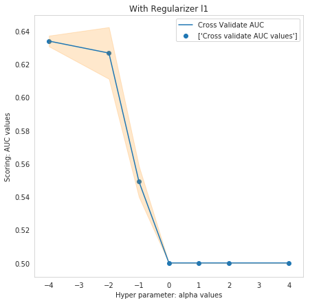

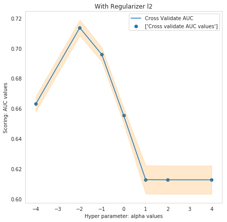

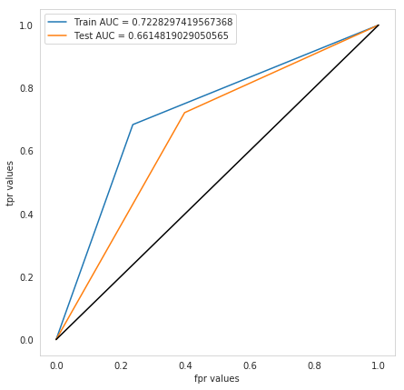

```
Results of analysis using Bag of words vectorized text features merged with other features using support vector machine classifier:
Optimal Alpha value:  0.01
========================================
Optimal Regularizer:  l2
========================================
AUC value of test data:  0.6614819029050565
========================================
Confusion Matrix :
============================================================
```

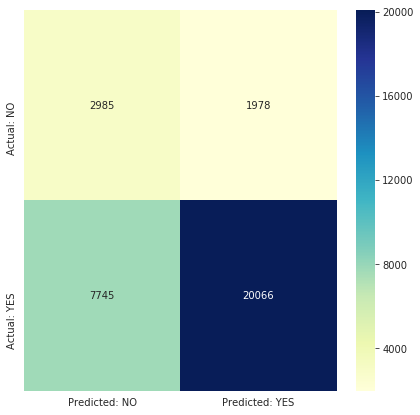

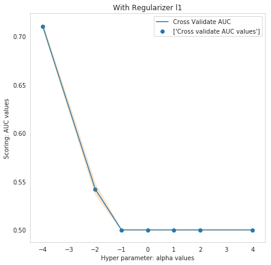

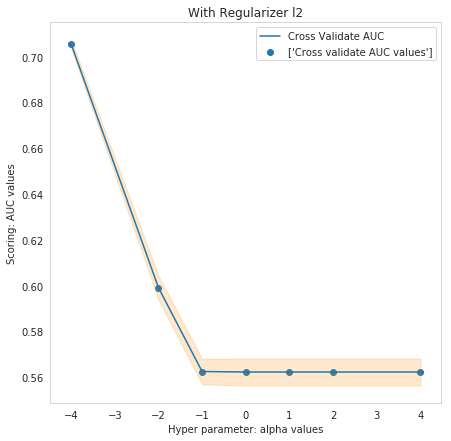

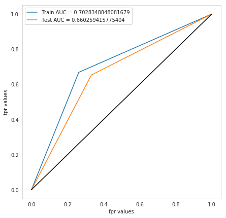

```
Results of analysis using Tf-Idf vectorized text features merged with other features using support vector machine classifier:
Optimal Alpha value:  0.0001
========================================
Optimal Regularizer:  l1
========================================
AUC value of test data:  0.660259415775404
========================================
Confusion Matrix :
============================================================
```

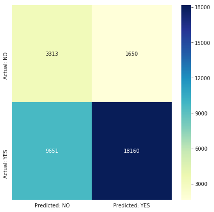

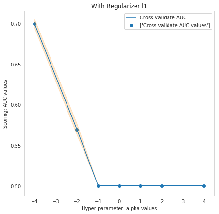

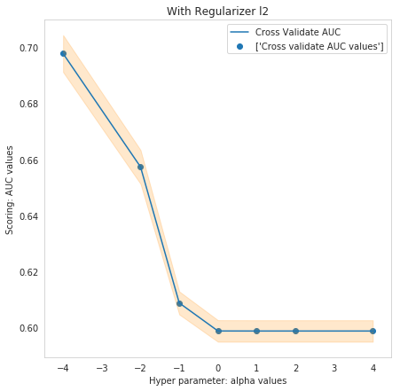

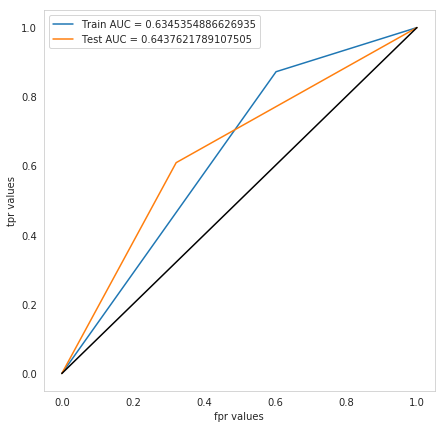

```
Results of analysis using Average Word2Vector vectorized text features merged with other features using support vector machine classifier:
Optimal Alpha value:  0.0001
========================================
Optimal Regularizer:  l1
========================================
AUC value of test data:  0.6437621789107505
========================================
Confusion Matrix :
============================================================
```

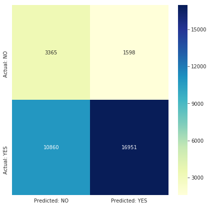

[4 more figures not shown]

```python
techniques = ['Bag of words', 'Tf-Idf', 'Average Word2Vector', 'Tf-Idf Weighted Word2Vector'];
for index, technique in enumerate(techniques):
    trainingMergedData = hstack((categoriesVectorsSub,\
                                     subCategoriesVectorsSub,\
                                     teacherPrefixVectorsSub,\
                                     schoolStateVectorsSub,\
                                     projectGradeVectorsSub,\
                                     priceStandardizedSub,\
                                     previouslyPostedStandardizedSub));
    crossValidateMergedData = hstack((categoriesTransformedCrossValidateData,\
                                          subCategoriesTransformedCrossValidateData,\
                                          teacherPrefixTransformedCrossValidateData,\
                                          schoolStateTransformedCrossValidateData,\
                                          projectGradeTransformedCrossValidateData,\
                                          priceTransformedCrossValidateData,\
                                          previouslyPostedTransformedCrossValidateData));
    testMergedData = hstack((categoriesTransformedTestData,\
                                          subCategoriesTransformedTestData,\
                                          teacherPrefixTransformedTestData,\
                                          schoolStateTransformedTestData,\
                                          projectGradeTransformedTestData,\
                                          priceTransformedTestData,\
                                          previouslyPostedTransformedTestData));
    if(index == 0):
        trainingMergedData = hstack((trainingMergedData,\
                                     bowTitleModelSub,\
                                     bowEssayModelSub));
        crossValidateMergedData = hstack((crossValidateMergedData,\
                                 bowTitleTransformedCrossValidateData,\
                                 bowEssayTransformedCrossValidateData));
        testMergedData = hstack((testMergedData,\
                                 bowTitleTransformedTestData,\
                                 bowEssayTransformedTestData));
    elif(index == 1):
        trainingMergedData = hstack((trainingMergedData,\
                                     tfIdfTitleModelSub,\
                                     tfIdfEssayModelSub));
        crossValidateMergedData = hstack((crossValidateMergedData,\
                                 tfIdfTitleTransformedCrossValidateData,\
                                 tfIdfEssayTransformedCrossValidateData));
        testMergedData = hstack((testMergedData,\
                                 tfIdfTitleTransformedTestData,\
                                 tfIdfEssayTransformedTestData));
    elif(index == 2):
        trainingMergedData = hstack((trainingMergedData,\
                                     word2VecTitlesVectors,\
                                     word2VecEssaysVectors));
        crossValidateMergedData = hstack((crossValidateMergedData,\
                                 avgWord2VecTitleTransformedCrossValidateData,\
                                 avgWord2VecEssayTransformedCrossValidateData));
        testMergedData = hstack((testMergedData,\
                                 avgWord2VecTitleTransformedTestData,\
                                 avgWord2VecEssayTransformedTestData));
    elif(index == 3):
        trainingMergedData = hstack((trainingMergedData,\
                                     tfIdfWeightedWord2VecTitlesVectors,\
                                     tfIdfWeightedWord2VecEssaysVectors));
        crossValidateMergedData = hstack((crossValidateMergedData,\
                                 tfIdfWeightedWord2VecTitleTransformedCrossValidateData,\
                                 tfIdfWeightedWord2VecEssayTransformedCrossValidateData));
        testMergedData = hstack((testMergedData,\
                                 tfIdfWeightedWord2VecTitleTransformedTestData,\
                                 tfIdfWeightedWord2VecEssayTransformedTestData));

    svmClassifier = linear_model.SGDClassifier(loss = 'hinge', class_weight = 'balanced');
    tunedParameters = {'alpha': [0.0001, 0.01, 0.1, 1, 10, 100, 10000], 'penalty': ['l1', 'l2']};
    classifier = GridSearchCV(svmClassifier, tunedParameters, cv = 5, scoring = 'roc_auc');
    classifier.fit(trainingMergedData, classesTrainingSub);

    testScoresDataFrame = pd.DataFrame(data = np.hstack((classifier.cv_results_['param_alpha'].data[:, None], classifier.cv_results_['param_penalty'].data[:, None], classifier.cv_results_['mean_test_score'][:, None], classifier.cv_results_['std_test_score'][:, None])), columns = ['alpha', 'penalty', 'mts', 'stdts']);
    testScoresDataFrame

    crossValidateAucMeanValues = classifier.cv_results_['mean_test_score'];
    crossValidateAucStdValues = classifier.cv_results_['std_test_score'];

    testScoresDataFrame['logAlphaValues'] = [math.log10(x) for x in testScoresDataFrame['alpha']];

    plt.plot(testScoresDataFrame[testScoresDataFrame['penalty'] == 'l1']['logAlphaValues'], testScoresDataFrame[testScoresDataFrame['penalty'] == 'l1']['mts'], label = "Cross Validate AUC");
    plt.scatter(testScoresDataFrame[testScoresDataFrame['penalty'] == 'l1']['logAlphaValues'], testScoresDataFrame[testScoresDataFrame['penalty'] == 'l1']['mts'], label = ['Cross validate AUC values']);
    plt.gca().fill_between(testScoresDataFrame[testScoresDataFrame['penalty'] == 'l1']['logAlphaValues'].values, np.array(testScoresDataFrame[testScoresDataFrame['penalty'] == 'l1']['mts'].values - testScoresDataFrame[testScoresDataFrame['penalty'] == 'l1']['stdts'].values, dtype = float),\
                           np.array(testScoresDataFrame[testScoresDataFrame['penalty'] == 'l1']['mts'].values + testScoresDataFrame[testScoresDataFrame['penalty'] == 'l1']['stdts'].values, dtype = float), alpha = 0.2, color = 'darkorange');
    plt.xlabel('Hyper parameter: alpha values');
    plt.ylabel('Scoring: AUC values');
    plt.title("With Regularizer l1");
    plt.grid();
    plt.legend();
    plt.show();

    plt.plot(testScoresDataFrame[testScoresDataFrame['penalty'] == 'l2']['logAlphaValues'], testScoresDataFrame[testScoresDataFrame['penalty'] == 'l2']['mts'], label = "Cross Validate AUC");
    plt.scatter(testScoresDataFrame[testScoresDataFrame['penalty'] == 'l2']['logAlphaValues'], testScoresDataFrame[testScoresDataFrame['penalty'] == 'l2']['mts'], label = ['Cross validate AUC values']);
    plt.gca().fill_between(testScoresDataFrame[testScoresDataFrame['penalty'] == 'l2']['logAlphaValues'].values, np.array(testScoresDataFrame[testScoresDataFrame['penalty'] == 'l2']['mts'].values - testScoresDataFrame[testScoresDataFrame['penalty'] == 'l2']['stdts'].values, dtype = float),\
                           np.array(testScoresDataFrame[testScoresDataFrame['penalty'] == 'l2']['mts'].values + testScoresDataFrame[testScoresDataFrame['penalty'] == 'l2']['stdts'].values, dtype = float), alpha = 0.2, color = 'darkorange');
    plt.xlabel('Hyper parameter: alpha values');
    plt.ylabel('Scoring: AUC values');
    plt.title("With Regularizer l2");
    plt.grid();
    plt.legend();
    plt.show();

    optimalHypParamValue = classifier.best_params_['alpha'];
    optimalHypParam2Value = classifier.best_params_['penalty'];
    svmClassifier = linear_model.SGDClassifier(loss = 'hinge', class_weight = 'balanced', alpha = optimalHypParamValue, penalty = optimalHypParam2Value);
    svmClassifier.fit(trainingMergedData, classesTrainingSub);
    predScoresTraining = svmClassifier.predict(trainingMergedData);
    fprTrain, tprTrain, thresholdTrain = roc_curve(classesTraining, predScoresTraining);
    predScoresTest = svmClassifier.predict(testMergedData);
    fprTest, tprTest, thresholdTest = roc_curve(classesTest, predScoresTest);

    plt.plot(fprTrain, tprTrain, label = "Train AUC = " + str(auc(fprTrain, tprTrain)));
    plt.plot(fprTest, tprTest, label = "Test AUC = " + str(auc(fprTest, tprTest)));
    plt.plot([0, 1], [0, 1], 'k-');
    plt.xlabel("fpr values");
    plt.ylabel("tpr values");
    plt.grid();
    plt.legend();
    plt.show();

    areaUnderRocValueTest = auc(fprTest, tprTest);

    print("Results of analysis using {} vectorized text features merged with other features using support vector machine classifier: ".format(technique));
    print("Optimal Alpha value: ", optimalHypParamValue);
    equalsBorder(40);
    print("Optimal Regularizer: ", optimalHypParam2Value);
    equalsBorder(40);
    print("AUC value of test data: ", str(areaUnderRocValueTest));
    # Predicting classes of test data projects
    predictionClassesTest = svmClassifier.predict(testMergedData);
    equalsBorder(40);
    # Printing confusion matrix
    confusionMatrix = confusion_matrix(classesTest, predictionClassesTest);
    # Creating dataframe for generated confusion matrix
    confusionMatrixDataFrame = pd.DataFrame(data = confusionMatrix, index = ['Actual: NO', 'Actual: YES'], columns = ['Predicted: NO', 'Predicted: YES']);
    print("Confusion Matrix : ");
    equalsBorder(60);
    sbrn.heatmap(confusionMatrixDataFrame, annot = True, fmt = 'd', cmap="YlGnBu");
    plt.show();
    # Adding results to results dataframe
    supportVectorMachineResultsDataFrame = supportVectorMachineResultsDataFrame.append({'Vectorizer': technique, 'Model': 'SVM(SGD - hinge loss)', 'Hyper Parameter - alpha': optimalHypParamValue, 'AUC': areaUnderRocValueTest}, ignore_index = True);
```

## Classification using data with reduced dimensions by support vector machine

```python
projectsData.shape
```

[output not shown]

### Calculating number of words of title and essay

```python
number_of_words_in_title = [len(title.split()) for title in projectsData['preprocessed_titles'].values]
number_of_words_in_essay = [len(essay.split()) for essay in projectsData['preprocessed_essays'].values]
projectsData['number_of_words_in_title'] = number_of_words_in_title;
projectsData['number_of_words_in_essay'] = number_of_words_in_essay;
```

### Calculating sentiment score of each essay

```python
sentimentAnalyzer = SentimentIntensityAnalyzer();
positiveSentimentScores = [];
negativeSentimentScores = [];
neutralSentimentScores = [];
compoundSentimentScores = [];
for projectEssay in tqdm(projectsData['preprocessed_essays'].values):
  sentimentScore = sentimentAnalyzer.polarity_scores(projectEssay);
  positiveSentimentScores.append(sentimentScore['pos']);
  negativeSentimentScores.append(sentimentScore['neg']);
  neutralSentimentScores.append(sentimentScore['neu']);
  compoundSentimentScores.append(sentimentScore['compound']);
print(len(positiveSentimentScores), len(negativeSentimentScores), len(neutralSentimentScores), len(compoundSentimentScores));
print(positiveSentimentScores[0:5])
```

```
109245 109245 109245 109245
[0.154, 0.305, 0.23, 0.256, 0.151]
```

```python
projectsData['positive_sentiment_score'] = positiveSentimentScores;
projectsData['negative_sentiment_score'] = negativeSentimentScores;
projectsData['neutral_sentiment_score'] = neutralSentimentScores;
projectsData['compound_sentiment_score'] = compoundSentimentScores;
projectsData.shape
```

```
(109245, 30)
```

```python
projectsData = projectsData.dropna(subset = ['teacher_prefix']);
projectsData.shape
```

```
(109245, 30)
```

```python
classesData = projectsData['project_is_approved']
print(classesData.shape)
```

```
(109245,)
```

```python
trainingData, testData, classesTraining, classesTest = model_selection.train_test_split(projectsData, classesData, test_size =  0.3, random_state = 0, stratify = classesData);
trainingData, crossValidateData, classesTraining, classesCrossValidate = model_selection.train_test_split(trainingData, classesTraining, test_size = 0.3, random_state = 0, stratify = classesTraining);
```

```python
print("Shapes of splitted data: ");
equalsBorder(70);

print("testData shape: ", testData.shape);
print("classesTest: ", classesTest.shape);
print("trainingData shape: ", trainingData.shape);
print("classesTraining shape: ", classesTraining.shape);
```

```
Shapes of splitted data:
======================================================================
testData shape:  (32774, 30)
classesTest:  (32774,)
trainingData shape:  (53529, 30)
classesTraining shape:  (53529,)
```

```python
print("Number of negative points: ", trainingData[trainingData['project_is_approved'] == 0].shape);
print("Number of positive points: ", trainingData[trainingData['project_is_approved'] == 1].shape);
```

```
Number of negative points:  (8105, 30)
Number of positive points:  (45424, 30)
```

```python
vectorizedFeatureNames = [];
```

## Vectorizing categorical data

### 1. Vectorizing cleaned_categories(project_subject_categories cleaned) - One Hot Encoding

```python
# Using CountVectorizer for performing one-hot-encoding by setting vocabulary as list of all unique cleaned_categories
subjectsCategoriesVectorizer = CountVectorizer(vocabulary = list(sortedCategoriesDictionary.keys()), lowercase = False, binary = True);
# Fitting CountVectorizer with cleaned_categories values
subjectsCategoriesVectorizer.fit(trainingData['cleaned_categories'].values);
# Vectorizing categories using one-hot-encoding
categoriesVectors = subjectsCategoriesVectorizer.transform(trainingData['cleaned_categories'].values);
```

```python
print("Features used in vectorizing categories: ");
equalsBorder(70);
print(subjectsCategoriesVectorizer.get_feature_names());
equalsBorder(70);
print("Shape of cleaned_categories matrix after vectorization(one-hot-encoding): ", categoriesVectors.shape);
equalsBorder(70);
print("Sample vectors of categories: ");
equalsBorder(70);
print(categoriesVectors[0:4])
```

```
Features used in vectorizing categories:
======================================================================
['Warmth', 'Care_Hunger', 'History_Civics', 'Music_Arts', 'AppliedLearning', 'SpecialNeeds', 'Health_Sports', 'Math_Science', 'Literacy_Language']
======================================================================
Shape of cleaned_categories matrix after vectorization(one-hot-encoding):  (53529, 9)
======================================================================
Sample vectors of categories:
======================================================================
  (0, 3)	1
  (0, 7)	1
  (1, 7)	1
  (1, 8)	1
  (2, 6)	1
  (2, 7)	1
  (3, 7)	1
```

### 2. Vectorizing cleaned_sub_categories(project_subject_sub_categories cleaned) - One Hot Encoding

```python
# Using CountVectorizer for performing one-hot-encoding by setting vocabulary as list of all unique cleaned_sub_categories
subjectsSubCategoriesVectorizer = CountVectorizer(vocabulary = list(sortedDictionarySubCategories.keys()), lowercase = False, binary = True);
# Fitting CountVectorizer with cleaned_sub_categories values
subjectsSubCategoriesVectorizer.fit(trainingData['cleaned_sub_categories'].values);
# Vectorizing sub categories using one-hot-encoding
subCategoriesVectors = subjectsSubCategoriesVectorizer.transform(trainingData['cleaned_sub_categories'].values);
```

```python
print("Features used in vectorizing subject sub categories: ");
equalsBorder(70);
print(subjectsSubCategoriesVectorizer.get_feature_names());
equalsBorder(70);
print("Shape of cleaned_categories matrix after vectorization(one-hot-encoding): ", subCategoriesVectors.shape);
equalsBorder(70);
print("Sample vectors of categories: ");
equalsBorder(70);
print(subCategoriesVectors[0:4])
```

```
Features used in vectorizing subject sub categories:
======================================================================
['Economics', 'CommunityService', 'FinancialLiteracy', 'ParentInvolvement', 'Extracurricular', 'Civics_Government', 'ForeignLanguages', 'NutritionEducation', 'Warmth', 'Care_Hunger', 'SocialSciences', 'PerformingArts', 'CharacterEducation', 'TeamSports', 'Other', 'College_CareerPrep', 'Music', 'Hist…
======================================================================
Shape of cleaned_categories matrix after vectorization(one-hot-encoding):  (53529, 30)
======================================================================
Sample vectors of categories:
======================================================================
  (0, 23)	1
  (0, 25)	1
  (1, 28)	1
  (1, 29)	1
  (2, 24)	1
  (2, 25)	1
  (3, 28)	1
```

### 3. Vectorizing teacher_prefix - One Hot Encoding

```python
def giveCounter(data):
    counter = Counter();
    for dataValue in data:
        counter.update(str(dataValue).split());
    return counter
```

```python
giveCounter(trainingData['teacher_prefix'].values)
```

```
Counter({'Dr.': 4, 'Mr.': 5206, 'Mrs.': 28216, 'Ms.': 18934, 'Teacher': 1169})
```

```python
teacherPrefixDictionary = dict(giveCounter(trainingData['teacher_prefix'].values));
# Using CountVectorizer for performing one-hot-encoding by setting vocabulary as list of all unique teacher_prefix
teacherPrefixVectorizer = CountVectorizer(vocabulary = list(teacherPrefixDictionary.keys()), lowercase = False, binary = True);
# Fitting CountVectorizer with teacher_prefix values
teacherPrefixVectorizer.fit(trainingData['teacher_prefix'].values);
# Vectorizing teacher_prefix using one-hot-encoding
teacherPrefixVectors = teacherPrefixVectorizer.transform(trainingData['teacher_prefix'].values);
```

```python
print("Features used in vectorizing teacher_prefix: ");
equalsBorder(70);
print(teacherPrefixVectorizer.get_feature_names());
equalsBorder(70);
print("Shape of teacher_prefix matrix after vectorization(one-hot-encoding): ", teacherPrefixVectors.shape);
equalsBorder(70);
print("Sample vectors of teacher_prefix: ");
equalsBorder(70);
print(teacherPrefixVectors[0:100]);
```

```
Features used in vectorizing teacher_prefix:
======================================================================
['Ms.', 'Mrs.', 'Teacher', 'Mr.', 'Dr.']
======================================================================
Shape of teacher_prefix matrix after vectorization(one-hot-encoding):  (53529, 5)
======================================================================
Sample vectors of teacher_prefix:
======================================================================
  (21, 2)	1
```

```python
teacherPrefixes = [prefix.replace('.', '') for prefix in trainingData['teacher_prefix'].values];
teacherPrefixes[0:5]
```

```
['Ms', 'Ms', 'Mrs', 'Mrs', 'Mrs']
```

```python
trainingData['teacher_prefix'] = teacherPrefixes;
trainingData.head(3)
```

|  | Unnamed: 0 | id | teacher_id | teacher_prefix | school_state | project_submitted_datetime | project_grade_category | project_subject_categories | project_subject_subcategories | project_title | project_essay_1 | project_essay_2 | project_essay_3 | project_essay_4 | project_resource_summary | teacher_number_of_previously_posted_projects | project_is_approved | cleaned_categories | cleaned_sub_categories | project_essay | price | quantity | preprocessed_titles | preprocessed_essays | number_of_words_in_title | number_of_words_in_essay | positive_sentiment_score | negative_sentiment_score | neutral_sentiment_score | … |
| --- | --- | --- | --- | --- | --- | --- | --- | --- | --- | --- | --- | --- | --- | --- | --- | --- | --- | --- | --- | --- | --- | --- | --- | --- | --- | --- | --- | --- | --- | --- |
| 66637 | 174395 | p233512 | c9e73f31af5ad4c7d3a140e81554da3b | Ms | GA | 2017-01-05 09:22:33 | Grades 3-5 | Math & Science, Music & The Arts | Applied Sciences, Visual Arts | STEAMing Up With Chromebooks! | I am a third grade teacher at an inner city sc... | In the words of Benjamin Franklin, \"Tell me a... | NaN | NaN | My students need four Chromebooks to engage in... | 1 | 1 | Math_Science Music_Arts | AppliedSciences VisualArts | I am a third grade teacher at an inner city sc... | 159.00 | 4 | steaming chromebooks | third grade teacher inner city school students... | 2 | 167 | 0.390 | 0.036 | 0.573 | … |
| 76424 | 11981 | p088047 | e1aa00913e0009364b5c7c3c4ab9a6f5 | Ms | WA | 2017-03-14 16:13:15 | Grades PreK-2 | Literacy & Language, Math & Science | Literacy, Mathematics | iPad for Autism Preschool Program! | The students in our Autism Preschool Program a... | Our class would love to integrate the iPad int... | NaN | NaN | My students need an iPad 2 to expand their lea... | 9 | 1 | Literacy_Language Math_Science | Literacy Mathematics | The students in our Autism Preschool Program a... | 509.85 | 1 | ipad autism preschool program | students autism preschool program wonderful gr... | 4 | 139 | 0.301 | 0.031 | 0.668 | … |
| 34433 | 11994 | p210041 | a6c5d41f4e18aca1530159f7cee84084 | Mrs | NC | 2016-08-18 17:14:11 | Grades 3-5 | Math & Science, Health & Sports | Applied Sciences, Health & Wellness | Active With Our Robots | Benjamin Franklin once said, \"Tell me and I f... | Last year, I had the opportunity to learn codi... | NaN | NaN | My students need robots, Kindle Fires, Kindle ... | 25 | 1 | Math_Science Health_Sports | AppliedSciences Health_Wellness | Benjamin Franklin once said, \"Tell me and I f... | 289.92 | 12 | active robots | benjamin franklin said tell forget teach remem... | 2 | 210 | 0.232 | 0.047 | 0.720 | … |

```python
teacherPrefixDictionary = dict(giveCounter(trainingData['teacher_prefix'].values));
# Using CountVectorizer for performing one-hot-encoding by setting vocabulary as list of all unique teacher_prefix
teacherPrefixVectorizer = CountVectorizer(vocabulary = list(teacherPrefixDictionary.keys()), lowercase = False, binary = True);
# Fitting CountVectorizer with teacher_prefix values
teacherPrefixVectorizer.fit(trainingData['teacher_prefix'].values);
# Vectorizing teacher_prefix using one-hot-encoding
teacherPrefixVectors = teacherPrefixVectorizer.transform(trainingData['teacher_prefix'].values);
```

```python
print("Features used in vectorizing teacher_prefix: ");
equalsBorder(70);
print(teacherPrefixVectorizer.get_feature_names());
equalsBorder(70);
print("Shape of teacher_prefix matrix after vectorization(one-hot-encoding): ", teacherPrefixVectors.shape);
equalsBorder(70);
print("Sample vectors of teacher_prefix: ");
equalsBorder(70);
print(teacherPrefixVectors[0:4]);
```

```
Features used in vectorizing teacher_prefix:
======================================================================
['Ms', 'Mrs', 'Teacher', 'Mr', 'Dr']
======================================================================
Shape of teacher_prefix matrix after vectorization(one-hot-encoding):  (53529, 5)
======================================================================
Sample vectors of teacher_prefix:
======================================================================
  (0, 0)	1
  (1, 0)	1
  (2, 1)	1
  (3, 1)	1
```

### 4. Vectorizing school_state - One Hot Encoding

```python
schoolStateDictionary = dict(giveCounter(trainingData['school_state'].values));
# Using CountVectorizer for performing one-hot-encoding by setting vocabulary as list of all unique school states
schoolStateVectorizer = CountVectorizer(vocabulary = list(schoolStateDictionary.keys()), lowercase = False, binary = True);
# Fitting CountVectorizer with school_state values
schoolStateVectorizer.fit(trainingData['school_state'].values);
# Vectorizing school_state using one-hot-encoding
schoolStateVectors = schoolStateVectorizer.transform(trainingData['school_state'].values);
```

```python
print("Features used in vectorizing school_state: ");
equalsBorder(70);
print(schoolStateVectorizer.get_feature_names());
equalsBorder(70);
print("Shape of school_state matrix after vectorization(one-hot-encoding): ", schoolStateVectors.shape);
equalsBorder(70);
print("Sample vectors of school_state: ");
equalsBorder(70);
print(schoolStateVectors[0:4]);
```

```
Features used in vectorizing school_state:
======================================================================
['GA', 'WA', 'NC', 'MI', 'NV', 'KY', 'CA', 'CT', 'PA', 'SC', 'WV', 'CO', 'FL', 'AZ', 'MS', 'OH', 'LA', 'TX', 'NY', 'IN', 'MO', 'KS', 'IA', 'NJ', 'AR', 'MA', 'WI', 'OK', 'UT', 'MN', 'OR', 'DC', 'VA', 'AL', 'NM', 'TN', 'IL', 'HI', 'DE', 'MD', 'ID', 'SD', 'NH', 'NE', 'ME', 'MT', 'AK', 'ND', 'VT', 'WY',…
======================================================================
Shape of school_state matrix after vectorization(one-hot-encoding):  (53529, 51)
======================================================================
Sample vectors of school_state:
======================================================================
  (0, 0)	1
  (1, 1)	1
  (2, 2)	1
  (3, 3)	1
```

### 5. Vectorizing project_grade_category - One Hot Encoding

```python
giveCounter(trainingData['project_grade_category'])
```

```
Counter({'3-5': 18193,
         '6-8': 8300,
         '9-12': 5289,
         'Grades': 53529,
         'PreK-2': 21747})
```

```python
cleanedGrades = []
for grade in trainingData['project_grade_category'].values:
    grade = grade.replace(' ', '');
    grade = grade.replace('-', 'to');
    cleanedGrades.append(grade);
cleanedGrades[0:4]
```

```
['Grades3to5', 'GradesPreKto2', 'Grades3to5', 'Grades3to5']
```

```python
trainingData['project_grade_category'] = cleanedGrades
trainingData.head(4)
```

|  | Unnamed: 0 | id | teacher_id | teacher_prefix | school_state | project_submitted_datetime | project_grade_category | project_subject_categories | project_subject_subcategories | project_title | project_essay_1 | project_essay_2 | project_essay_3 | project_essay_4 | project_resource_summary | teacher_number_of_previously_posted_projects | project_is_approved | cleaned_categories | cleaned_sub_categories | project_essay | price | quantity | preprocessed_titles | preprocessed_essays | number_of_words_in_title | number_of_words_in_essay | positive_sentiment_score | negative_sentiment_score | neutral_sentiment_score | … |
| --- | --- | --- | --- | --- | --- | --- | --- | --- | --- | --- | --- | --- | --- | --- | --- | --- | --- | --- | --- | --- | --- | --- | --- | --- | --- | --- | --- | --- | --- | --- |
| 66637 | 174395 | p233512 | c9e73f31af5ad4c7d3a140e81554da3b | Ms | GA | 2017-01-05 09:22:33 | Grades3to5 | Math & Science, Music & The Arts | Applied Sciences, Visual Arts | STEAMing Up With Chromebooks! | I am a third grade teacher at an inner city sc... | In the words of Benjamin Franklin, \"Tell me a... | NaN | NaN | My students need four Chromebooks to engage in... | 1 | 1 | Math_Science Music_Arts | AppliedSciences VisualArts | I am a third grade teacher at an inner city sc... | 159.00 | 4 | steaming chromebooks | third grade teacher inner city school students... | 2 | 167 | 0.390 | 0.036 | 0.573 | … |
| 76424 | 11981 | p088047 | e1aa00913e0009364b5c7c3c4ab9a6f5 | Ms | WA | 2017-03-14 16:13:15 | GradesPreKto2 | Literacy & Language, Math & Science | Literacy, Mathematics | iPad for Autism Preschool Program! | The students in our Autism Preschool Program a... | Our class would love to integrate the iPad int... | NaN | NaN | My students need an iPad 2 to expand their lea... | 9 | 1 | Literacy_Language Math_Science | Literacy Mathematics | The students in our Autism Preschool Program a... | 509.85 | 1 | ipad autism preschool program | students autism preschool program wonderful gr... | 4 | 139 | 0.301 | 0.031 | 0.668 | … |
| 34433 | 11994 | p210041 | a6c5d41f4e18aca1530159f7cee84084 | Mrs | NC | 2016-08-18 17:14:11 | Grades3to5 | Math & Science, Health & Sports | Applied Sciences, Health & Wellness | Active With Our Robots | Benjamin Franklin once said, \"Tell me and I f... | Last year, I had the opportunity to learn codi... | NaN | NaN | My students need robots, Kindle Fires, Kindle ... | 25 | 1 | Math_Science Health_Sports | AppliedSciences Health_Wellness | Benjamin Franklin once said, \"Tell me and I f... | 289.92 | 12 | active robots | benjamin franklin said tell forget teach remem... | 2 | 210 | 0.232 | 0.047 | 0.720 | … |
| 84559 | 145506 | p030629 | 8c9462aaf17c6a5869fe54c62af8b23c | Mrs | MI | 2016-11-18 22:22:10 | Grades3to5 | Math & Science | Mathematics | Flexible Seating for Flexible Learners | My class is composed of 33 geniuses. These stu... | I believe that an engaged learner is a success... | NaN | NaN | My students need flexible seating in order to ... | 0 | 0 | Math_Science | Mathematics | My class is composed of 33 geniuses. These stu... | 190.24 | 17 | flexible seating flexible learners | class composed 33 geniuses students passionate... | 4 | 97 | 0.451 | 0.016 | 0.532 | … |

```python
projectGradeDictionary = dict(giveCounter(trainingData['project_grade_category'].values));
# Using CountVectorizer for performing one-hot-encoding by setting vocabulary as list of all unique project grade categories
projectGradeVectorizer = CountVectorizer(vocabulary = list(projectGradeDictionary.keys()), lowercase = False, binary = True);
# Fitting CountVectorizer with project_grade_category values
projectGradeVectorizer.fit(trainingData['project_grade_category'].values);
# Vectorizing project_grade_category using one-hot-encoding
projectGradeVectors = projectGradeVectorizer.transform(trainingData['project_grade_category'].values);
```

```python
print("Features used in vectorizing project_grade_category: ");
equalsBorder(70);
print(projectGradeVectorizer.get_feature_names());
equalsBorder(70);
print("Shape of school_state matrix after vectorization(one-hot-encoding): ", projectGradeVectors.shape);
equalsBorder(70);
print("Sample vectors of school_state: ");
equalsBorder(70);
print(projectGradeVectors[0:4]);
```

```
Features used in vectorizing project_grade_category:
======================================================================
['Grades3to5', 'GradesPreKto2', 'Grades6to8', 'Grades9to12']
======================================================================
Shape of school_state matrix after vectorization(one-hot-encoding):  (53529, 4)
======================================================================
Sample vectors of school_state:
======================================================================
  (0, 0)	1
  (1, 1)	1
  (2, 0)	1
  (3, 0)	1
```

### Tf-Idf Vectorization

#### 1. Vectorizing project_essay

```python
# Intializing tfidf vectorizer for tf-idf vectorization of preprocessed project essays
tfIdfEssayVectorizer = TfidfVectorizer(min_df = 10, max_features = 5000);
# Transforming the preprocessed project essays to tf-idf vectors
tfIdfEssayModel = tfIdfEssayVectorizer.fit_transform(preProcessedEssaysWithoutStopWords);
```

```python
print("Some of the Features used in tf-idf vectorizing preprocessed essays: ");
equalsBorder(70);
print(tfIdfEssayVectorizer.get_feature_names()[-40:]);
equalsBorder(70);
print("Shape of preprocessed title matrix after tf-idf vectorization: ", tfIdfEssayModel.shape);
equalsBorder(70);
print("Sample Tf-Idf vector of preprocessed essay: ");
equalsBorder(70);
print(tfIdfEssayModel[0])
```

```
Some of the Features used in tf-idf vectorizing preprocessed essays:
======================================================================
['worrying', 'worst', 'worth', 'worthwhile', 'worthy', 'would', 'wow', 'write', 'writer', 'writers', 'writing', 'writings', 'written', 'wrong', 'wrote', 'xylophones', 'yard', 'year', 'yearbook', 'yearly', 'yearn', 'yearning', 'years', 'yes', 'yesterday', 'yet', 'yoga', 'york', 'young', 'younger', 'y…
======================================================================
Shape of preprocessed title matrix after tf-idf vectorization:  (109248, 5000)
======================================================================
Sample Tf-Idf vector of preprocessed essay:
======================================================================
  (0, 3013)	0.015965240695453155
  (0, 1488)	0.10227077629951559
  (0, 900)	0.026463005286219803
  (0, 4982)	0.04582647393654424
  (0, 3375)	0.0625444219876457
  (0, 4977)	0.0306752753684296
  (0, 4752)	0.05440679396599839
  (0, 780)	0.07662037632839458
  (0, 3169)	0.03781481331251044
  (0, 3390)	0.18321040329163196
  (0, 108)	0.040000071711429254
  (0, 3091)	0.022124698215231303
  (0, 1433)	0.061920444892322624
  (0, 1246)	0.05054577035223512
  (0, 4851)	0.06986541769014476
  (0, 3730)	0.09018028989080147
  (0, 4021)	0.09616413965528452
  (0, 4479)	0.03754788787263396
  (0, 805)	0.07832945191677794
  (0, 4224)	0.10949652575968567
  (0, 4795)	0.20453745972832738
  (0, 1468)	0.10442911392080413
  (0, 3256)	0.045907362380733514
  (0, 3137)	0.08665307470908791
  (0, 4290)	0.0668235584225867
  :	:
  (0, 2819)	0.18267578272530896
  (0, 2657)	0.08246396864201584
  (0, 1645)	0.03290277997628051
  (0, 3540)	0.09266878292993941
  (0, 2629)	0.23032992958601448
  (0, 3788)	0.18439470661000118
  (0, 31)	0.08003880477371976
  (0, 3958)	0.03546008600799206
  (0, 2591)	0.1200129277454165
  (0, 2032)	0.08302595052382315
  (0, 622)	0.0797021927845829
  (0, 262)	0.09317692266510744
  (0, 579)	0.08993661029788748
  (0, 3019)	0.07694246325409376
  (0, 2316)	0.09044713807559518
  (0, 3723)	0.09806756817480866
  (0, 3439)	0.09819479507450754
  (0, 2861)	0.09995313270720342
  (0, 2592)	0.13131596546189067
  (0, 4546)	0.058915439503183835
  (0, 3986)	0.04932114628372647
  (0, 4944)	0.03804356418624494
  (0, 2630)	0.03600810586474103
  (0, 1564)	0.29767755886622843
  (0, 4364)	0.07692419628496143
```

### Vectorizing numerical features

#### 1. Vectorizing price

```python
# Standardizing the price data using StandardScaler(Uses mean and std for standardization)
priceScaler = MinMaxScaler();
priceScaler.fit(trainingData['price'].values.reshape(-1, 1));
priceStandardized = priceScaler.transform(trainingData['price'].values.reshape(-1, 1));
```

```python
print("Shape of standardized matrix of prices: ", priceStandardized.shape);
equalsBorder(70);
print("Sample original prices: ");
equalsBorder(70);
print(trainingData['price'].values[0:5]);
print("Sample standardized prices: ");
equalsBorder(70);
print(priceStandardized[0:5]);
```

```
Shape of standardized matrix of prices:  (53529, 1)
======================================================================
Sample original prices:
======================================================================
[159.   509.85 289.92 190.24 438.99]
Sample standardized prices:
======================================================================
[[0.01583663]
 [0.05092745]
 [0.0289308 ]
 [0.01896115]
 [0.04384028]]
```

#### 2. Vectorizing quantity

```python
# Standardizing the quantity data using StandardScaler(Uses mean and std for standardization)
quantityScaler = MinMaxScaler();
quantityScaler.fit(trainingData['quantity'].values.reshape(-1, 1));
quantityStandardized = quantityScaler.transform(trainingData['quantity'].values.reshape(-1, 1));
```

```python
print("Shape of standardized matrix of quantities: ", quantityStandardized.shape);
equalsBorder(70);
print("Sample original quantities: ");
equalsBorder(70);
print(trainingData['quantity'].values[0:5]);
print("Sample standardized quantities: ");
equalsBorder(70);
print(quantityStandardized[0:5]);
```

```
Shape of standardized matrix of quantities:  (53529, 1)
======================================================================
Sample original quantities:
======================================================================
[ 4  1 12 17  2]
Sample standardized quantities:
======================================================================
[[0.00322928]
 [0.        ]
 [0.01184069]
 [0.01722282]
 [0.00107643]]
```